# Multisite Analysis of Pharmacists Actions that lead to Cost Avoidance

Authors

Josh DeClercq

Department of Biostatistics

Vanderbilt University Medical Center

Published

June 9, 2026

# 1 Study Overview

## 1.1 Background

The purpose of this study is to evaluate direct cost avoidance from pharmacist interventions that identify inappropriate (ineffective or unsafe) medication use and result in medication discontinuation, dose adjustment, or medication switch (collectively termed medication outcome henceforth).

## 1.2 Methods

- Prospective multisite cohort study (n = 16)
- **Inclusion criteria:**
  - Adult and pediatric patients prescribed specialty medications from a health-system (regardless of their filling pharmacy)
  - At least one fill of a specialty medication
  - At least one intervention that led to a medication outcome of interest in the study period (6 months)
- **Exclusion criteria:**
  - Patients with a medication outcome completed due to non-clinical reason

## 1.3 Outcomes

The study had three aims. The first aim was to quantify pharmacist interventions that resulted in a discontinuation, switch, or dose/formulation change of a specialty medication. Outcomes for this aim included counts of interventions performed by each medication outcome and intervention reasons.

Secondly, we aimed to estimate the pTC associated with each intervention. The final pTC score for each intervention was analyzed according to medication outcome, intervention reason, and clinical area.

Finally, we approximated direct cost avoidance resulting from pharmacist interventions. Outcomes included the total direct cost avoidance over six months of interventions, median cost avoided per intervention, and median cost avoided by medication outcome, intervention reason, and clinical area.

# 2 Patient characteristics

## 2.1 Demographics

| **Characteristic** | **N** | **N = 990**<sup>1</sup> |
| --- | --- | --- |
| Site | 990 |  |
| Site 1 |  | 379 (38.3%) |
| Site 2 |  | 165 (16.7%) |
| Site 3 |  | 104 (10.5%) |
| Site 4 |  | 83 (8.38%) |
| Site 5 |  | 43 (4.34%) |
| Site 6 |  | 35 (3.54%) |
| Site 7 |  | 26 (2.63%) |
| Site 8 |  | 25 (2.53%) |
| Site 9 |  | 23 (2.32%) |
| Site 10 |  | 22 (2.22%) |
| Site 11 |  | 19 (1.92%) |
| Site 12 |  | 18 (1.82%) |
| Site 13 |  | 16 (1.62%) |
| Site 14 |  | 16 (1.62%) |
| Site 15 |  | 9 (0.91%) |
| Site 16 |  | 7 (0.71%) |
| Sex | 990 |  |
| Female |  | 591 (59.7%) |
| Male |  | 397 (40.1%) |
| Nonbinary |  | 1 (0.10%) |
| Decline to Answer/Unknow |  | 1 (0.10%) |
| Race | 990 |  |
| White |  | 753 (76.1%) |
| Black |  | 136 (13.7%) |
| Other |  | 34 (3.43%) |
| Decline to Answer/Unknown |  | 34 (3.43%) |
| Asian |  | 27 (2.73%) |
| American Indian or Alaska Native |  | 6 (0.61%) |
| Ethnicity | 990 |  |
| Not Hispanic |  | 681 (68.8%) |
| Decline to Answer/Unknown |  | 140 (14.1%) |
| Other |  | 116 (11.7%) |
| Hispanic |  | 53 (5.35%) |

<sup>1</sup> n (%)

## 2.2 Aggregated demographics

| **Characteristic** | **N** | **N = 990**<sup>1</sup> |
| --- | --- | --- |
| Number of interventions | 990 |  |
| 1 |  | 960 (97.0%) |
| 2 |  | 25 (2.53%) |
| 3 |  | 3 (0.30%) |
| 5 |  | 1 (0.10%) |
| 9 |  | 1 (0.10%) |
| Number of interventions with PTc > 0 | 990 |  |
| 1 |  | 628 (63.4%) |
| 0 |  | 339 (34.2%) |
| 2 |  | 18 (1.82%) |
| 3 |  | 3 (0.30%) |
| 5 |  | 1 (0.10%) |
| 8 |  | 1 (0.10%) |
| Number of interventions with PTc = 0 | 990 |  |
| 0 |  | 647 (65.4%) |
| 1 |  | 339 (34.2%) |
| 2 |  | 4 (0.40%) |
| Age at first intervention | 990 |  |
| Mean (SD) |  | 53.1 (20.3) |
| Median (Q1 - Q3) |  | 57.0 (39.0 - 69.0) |
| Min - Max |  | 0.0 - 94.0 |
| Aggregated insurance type | 976 |  |
| Commercial |  | 362 (37.1%) |
| Medicare D |  | 335 (34.3%) |
| Medicaid |  | 173 (17.7%) |
| Unknown |  | 72 (7.38%) |
| Medicare B |  | 14 (1.43%) |
| Other |  | 13 (1.33%) |
| Multiple |  | 3 (0.31%) |
| Cash pay |  | 2 (0.20%) |
| Tricare |  | 2 (0.20%) |
| Missing |  | 14 |
| Aggregated pharmacy type | 990 |  |
| HSSP |  | 891 (90.0%) |
| non-HSSP |  | 97 (9.80%) |
| Both |  | 2 (0.20%) |
| Aggregated clinical area | 990 |  |
| Rheumatology |  | 171 (17.3%) |
| Oncology |  | 159 (16.1%) |
| Other neurology |  | 138 (13.9%) |
| IBD |  | 95 (9.60%) |
| Dermatology |  | 89 (8.99%) |
| Other |  | 64 (6.46%) |
| Severe Asthma/Allergy |  | 58 (5.86%) |
| Adult Endocrinology |  | 53 (5.35%) |
| Other pulmonary |  | 41 (4.14%) |
| Hematology |  | 32 (3.23%) |
| Multiple Sclerosis |  | 32 (3.23%) |
| Transplant |  | 16 (1.62%) |
| Hepatology |  | 14 (1.41%) |
| Pediatric endocrinology |  | 9 (0.91%) |
| HIV |  | 8 (0.81%) |
| Pediatric inflammatory conditions |  | 5 (0.51%) |
| Cystic fibrosis |  | 3 (0.30%) |
| Bleeding Disorders |  | 1 (0.10%) |
| Hepatitis C |  | 1 (0.10%) |
| Multiple |  | 1 (0.10%) |

<sup>1</sup> n (%)

### 2.2.1 Number of interventions by pharmacy type

| **Characteristic** | **N** | **Aggregated pharmacy type** **Both** N = 2<sup>1</sup> | **Aggregated pharmacy type** **HSSP** N = 891<sup>1</sup> | **Aggregated pharmacy type** **non-HSSP** N = 97<sup>1</sup> |
| --- | --- | --- | --- | --- |
| Number of interventions | 990 |  |  |  |
| 1 |  | 0 (0%) | 865 (97.1%) | 95 (97.9%) |
| 2 |  | 1 (50.0%) | 22 (2.47%) | 2 (2.06%) |
| 3 |  | 1 (50.0%) | 2 (0.22%) | 0 (0%) |
| 5 |  | 0 (0%) | 1 (0.11%) | 0 (0%) |
| 9 |  | 0 (0%) | 1 (0.11%) | 0 (0%) |
| Number of interventions with PTc > 0 | 990 |  |  |  |
| 0 |  | 0 (0%) | 293 (32.9%) | 46 (47.4%) |
| 1 |  | 0 (0%) | 578 (64.9%) | 50 (51.5%) |
| 2 |  | 1 (50.0%) | 16 (1.80%) | 1 (1.03%) |
| 3 |  | 1 (50.0%) | 2 (0.22%) | 0 (0%) |
| 5 |  | 0 (0%) | 1 (0.11%) | 0 (0%) |
| 8 |  | 0 (0%) | 1 (0.11%) | 0 (0%) |
| Number of interventions with PTc = 0 | 990 |  |  |  |
| 0 |  | 2 (100.0%) | 595 (66.8%) | 50 (51.5%) |
| 1 |  | 0 (0%) | 292 (32.8%) | 47 (48.5%) |
| 2 |  | 0 (0%) | 4 (0.45%) | 0 (0%) |

<sup>1</sup> n (%)

# 3 Intervention information

## 3.1 Patient characteristics

| **Characteristic** | **N** | **Dichotomized PTc** **PTc = 0** N = 347<sup>1</sup> | **Dichotomized PTc** **PTc > 0** N = 686<sup>1</sup> | **Overall** N = 1,033<sup>1</sup> |  |
| --- | --- | --- | --- | --- | --- |
| age | 1,033 |  |  |  |  |
| Mean (SD) |  | 50.6 (19.4) | 54.7 (20.4) | 53.3 (20.1) |  |
| Median (Q1 - Q3) |  | 52.0 (35.0 - 66.0) | 59.0 (42.0 - 70.0) | 57.0 (40.0 - 70.0) |  |
| Min - Max |  | 0.1 - 88.0 | 0.0 - 94.0 | 0.0 - 94.0 |  |
| Age category | 1,033 |  |  |  |  |
| Age >= 18 |  | 329 (94.8%) | 639 (93.1%) | 968 (93.7%) |  |
| Age < 18 |  | 18 (5.19%) | 47 (6.85%) | 65 (6.29%) |  |
| Sex | 1,033 |  |  |  |  |
| Female |  | 204 (58.8%) | 413 (60.2%) | 617 (59.7%) |  |
| Male |  | 143 (41.2%) | 271 (39.5%) | 414 (40.1%) |  |
| Nonbinary |  | 0 (0%) | 1 (0.15%) | 1 (0.10%) |  |
| Decline to Answer/Unknow |  | 0 (0%) | 1 (0.15%) | 1 (0.10%) |  |
| Race | 1,033 |  |  |  |  |
| White |  | 258 (74.4%) | 528 (77.0%) | 786 (76.1%) |  |
| Black |  | 47 (13.5%) | 94 (13.7%) | 141 (13.6%) |  |
| Decline to Answer/Unknown |  | 13 (3.75%) | 25 (3.64%) | 38 (3.68%) |  |
| Other |  | 15 (4.32%) | 19 (2.77%) | 34 (3.29%) |  |
| Asian |  | 11 (3.17%) | 17 (2.48%) | 28 (2.71%) |  |
| American Indian or Alaska Native |  | 3 (0.86%) | 3 (0.44%) | 6 (0.58%) |  |
| Ethnicity | 1,033 |  |  |  |  |
| Not Hispanic |  | 229 (66.0%) | 472 (68.8%) | 701 (67.9%) |  |
| Decline to Answer/Unknown |  | 57 (16.4%) | 99 (14.4%) | 156 (15.1%) |  |
| Other |  | 39 (11.2%) | 82 (12.0%) | 121 (11.7%) |  |
| Hispanic |  | 22 (6.34%) | 33 (4.81%) | 55 (5.32%) |  |
| Site | 1,033 |  |  |  |  |
| Site 1 |  | 155 (44.7%) | 258 (37.6%) | 413 (40.0%) |  |
| Site 2 |  | 73 (21.0%) | 95 (13.8%) | 168 (16.3%) |  |
| Site 3 |  | 56 (16.1%) | 49 (7.14%) | 105 (10.2%) |  |
| Site 4 |  | 8 (2.31%) | 75 (10.9%) | 83 (8.03%) |  |
| Site 5 |  | 1 (0.29%) | 42 (6.12%) | 43 (4.16%) |  |

[output cut: 59 more lines]

<sup>1</sup> n (%)

## 3.2 Intervention characteristics

**Overall**

| **Characteristic** | **N** | **Dichotomized PTc** **PTc = 0** N = 347<sup>1</sup> | **Dichotomized PTc** **PTc > 0** N = 686<sup>1</sup> | **Overall** N = 1,033<sup>1</sup> |  |
| --- | --- | --- | --- | --- | --- |
| Intervention reason | 1,033 |  |  |  |  |
| Regimen appropriateness |  | 59 (17.0%) | 185 (27.0%) | 244 (23.6%) |  |
| Adverse drug effect |  | 75 (21.6%) | 161 (23.5%) | 236 (22.8%) |  |
| Effectiveness |  | 63 (18.2%) | 157 (22.9%) | 220 (21.3%) |  |
| Affordability |  | 117 (33.7%) | 65 (9.48%) | 182 (17.6%) |  |
| Adherence |  | 14 (4.03%) | 62 (9.04%) | 76 (7.36%) |  |
| Therapeutic monitoring for safety |  | 17 (4.90%) | 43 (6.27%) | 60 (5.81%) |  |
| Drug interaction |  | 0 (0%) | 12 (1.75%) | 12 (1.16%) |  |
| Allergy |  | 2 (0.58%) | 1 (0.15%) | 3 (0.29%) |  |
| Intervention outcome | 1,033 |  |  |  |  |
| Medication switch |  | 175 (50.4%) | 237 (34.5%) | 412 (39.9%) |  |
| Medication dose change |  | 79 (22.8%) | 321 (46.8%) | 400 (38.7%) |  |
| Medication discontinuation |  | 93 (26.8%) | 128 (18.7%) | 221 (21.4%) |  |
| Dose change direction | 401 |  |  |  |  |
| Decrease |  | 34 (43.0%) | 151 (46.9%) | 185 (46.1%) |  |
| Increase |  | 38 (48.1%) | 141 (43.8%) | 179 (44.6%) |  |
| Package size/formulation change |  | 7 (8.86%) | 30 (9.32%) | 37 (9.23%) |  |
| Missing |  | 268 | 364 | 632 |  |

<sup>1</sup> n (%)

**Stratifed by reason**

| **Characteristic** | **N** | **Intervention reason** **Adherence** N = 76<sup>1</sup> | **Intervention reason** **Affordability** N = 182<sup>1</sup> | **Intervention reason** **Drug interaction** N = 12<sup>1</sup> | **Intervention reason** **Adverse drug effect** N = 236<sup>1</sup> | **Intervention reason** **Allergy** N = 3<sup>1</sup> | **Intervention reason** **Therapeutic monitoring for safety** N = 60<sup>1</sup> | **Intervention reason** **Effectiveness** N = 220<sup>1</sup> | **Intervention reason** **Regimen appropriateness** N = 244<sup>1</sup> | **Overall** N = 1,033<sup>1</sup> |  |
| --- | --- | --- | --- | --- | --- | --- | --- | --- | --- | --- | --- |
| Intervention outcome | 1,033 |  |  |  |  |  |  |  |  |  |  |
| Medication switch |  | 37 (48.7%) | 168 (92.3%) | 2 (16.7%) | 85 (36.0%) | 1 (33.3%) | 7 (11.7%) | 63 (28.6%) | 49 (20.1%) | 412 (39.9%) |  |
| Medication dose change |  | 27 (35.5%) | 9 (4.95%) | 10 (83.3%) | 66 (28.0%) | 0 (0%) | 42 (70.0%) | 135 (61.4%) | 111 (45.5%) | 400 (38.7%) |  |
| Medication discontinuation |  | 12 (15.8%) | 5 (2.75%) | 0 (0%) | 85 (36.0%) | 2 (66.7%) | 11 (18.3%) | 22 (10.0%) | 84 (34.4%) | 221 (21.4%) |  |
| Pharmacy filling medication most recently | 1,033 |  |  |  |  |  |  |  |  |  |  |
| HSSP |  | 70 (92.1%) | 147 (80.8%) | 12 (100.0%) | 220 (93.2%) | 3 (100.0%) | 56 (93.3%) | 196 (89.1%) | 228 (93.4%) | 932 (90.2%) |  |
| non-HSSP |  | 6 (7.89%) | 35 (19.2%) | 0 (0%) | 16 (6.78%) | 0 (0%) | 4 (6.67%) | 24 (10.9%) | 16 (6.56%) | 101 (9.78%) |  |
| Clinical area | 1,033 |  |  |  |  |  |  |  |  |  |  |
| Rheumatology |  | 15 (19.7%) | 67 (36.8%) | 0 (0%) | 28 (11.9%) | 0 (0%) | 3 (5.00%) | 45 (20.5%) | 16 (6.56%) | 174 (16.8%) |  |
| Other neurology |  | 6 (7.89%) | 12 (6.59%) | 2 (16.7%) | 45 (19.1%) | 2 (66.7%) | 10 (16.7%) | 79 (35.9%) | 9 (3.69%) | 165 (16.0%) |  |
| Oncology |  | 4 (5.26%) | 10 (5.49%) | 6 (50.0%) | 37 (15.7%) | 1 (33.3%) | 15 (25.0%) | 15 (6.82%) | 74 (30.3%) | 162 (15.7%) |  |
| IBD |  | 6 (7.89%) | 44 (24.2%) | 1 (8.33%) | 5 (2.12%) | 0 (0%) | 4 (6.67%) | 25 (11.4%) | 14 (5.74%) | 99 (9.58%) |  |
| Dermatology |  | 12 (15.8%) | 16 (8.79%) | 0 (0%) | 20 (8.47%) | 0 (0%) | 0 (0%) | 16 (7.27%) | 25 (10.2%) | 89 (8.62%) |  |
| Other |  | 3 (3.95%) | 3 (1.65%) | 0 (0%) | 21 (8.90%) | 0 (0%) | 8 (13.3%) | 10 (4.55%) | 20 (8.20%) | 65 (6.29%) |  |
| Severe Asthma/Allergy |  | 19 (25.0%) | 1 (0.55%) | 0 (0%) | 6 (2.54%) | 0 (0%) | 4 (6.67%) | 14 (6.36%) | 15 (6.15%) | 59 (5.71%) |  |
| Adult Endocrinology |  | 2 (2.63%) | 7 (3.85%) | 0 (0%) | 15 (6.36%) | 0 (0%) | 0 (0%) | 6 (2.73%) | 24 (9.84%) | 54 (5.23%) |  |
| Other pulmonary |  | 5 (6.58%) | 3 (1.65%) | 0 (0%) | 27 (11.4%) | 0 (0%) | 1 (1.67%) | 0 (0%) | 7 (2.87%) | 43 (4.16%) |  |
| Multiple Sclerosis |  | 0 (0%) | 8 (4.40%) | 0 (0%) | 20 (8.47%) | 0 (0%) | 2 (3.33%) | 1 (0.45%) | 3 (1.23%) | 34 (3.29%) |  |
| Hematology |  | 0 (0%) | 1 (0.55%) | 3 (25.0%) | 5 (2.12%) | 0 (0%) | 4 (6.67%) | 3 (1.36%) | 16 (6.56%) | 32 (3.10%) |  |
| Transplant |  | 0 (0%) | 0 (0%) | 0 (0%) | 2 (0.85%) | 0 (0%) | 1 (1.67%) | 0 (0%) | 13 (5.33%) | 16 (1.55%) |  |
| Hepatology |  | 1 (1.32%) | 3 (1.65%) | 0 (0%) | 2 (0.85%) | 0 (0%) | 1 (1.67%) | 2 (0.91%) | 5 (2.05%) | 14 (1.36%) |  |
| Pediatric endocrinology |  | 1 (1.32%) | 2 (1.10%) | 0 (0%) | 0 (0%) | 0 (0%) | 4 (6.67%) | 2 (0.91%) | 0 (0%) | 9 (0.87%) |  |
| HIV |  | 0 (0%) | 2 (1.10%) | 0 (0%) | 1 (0.42%) | 0 (0%) | 3 (5.00%) | 0 (0%) | 2 (0.82%) | 8 (0.77%) |  |
| Pediatric inflammatory conditions |  | 1 (1.32%) | 3 (1.65%) | 0 (0%) | 0 (0%) | 0 (0%) | 0 (0%) | 1 (0.45%) | 0 (0%) | 5 (0.48%) |  |
| Cystic fibrosis |  | 1 (1.32%) | 0 (0%) | 0 (0%) | 1 (0.42%) | 0 (0%) | 0 (0%) | 1 (0.45%) | 0 (0%) | 3 (0.29%) |  |
| Hepatitis C |  | 0 (0%) | 0 (0%) | 0 (0%) | 1 (0.42%) | 0 (0%) | 0 (0%) | 0 (0%) | 0 (0%) | 1 (0.10%) |  |
| Bleeding Disorders |  | 0 (0%) | 0 (0%) | 0 (0%) | 0 (0%) | 0 (0%) | 0 (0%) | 0 (0%) | 1 (0.41%) | 1 (0.10%) |  |

<sup>1</sup> n (%)

**Stratifed by outcome**

| **Characteristic** | **N** | **Intervention outcome** **Medication discontinuation** N = 221<sup>1</sup> | **Intervention outcome** **Medication switch** N = 412<sup>1</sup> | **Intervention outcome** **Medication dose change** N = 400<sup>1</sup> | **Overall** N = 1,033<sup>1</sup> |  |
| --- | --- | --- | --- | --- | --- | --- |
| Intervention reason | 1,033 |  |  |  |  |  |
| Regimen appropriateness |  | 84 (38.0%) | 49 (11.9%) | 111 (27.8%) | 244 (23.6%) |  |
| Adverse drug effect |  | 85 (38.5%) | 85 (20.6%) | 66 (16.5%) | 236 (22.8%) |  |
| Effectiveness |  | 22 (9.95%) | 63 (15.3%) | 135 (33.8%) | 220 (21.3%) |  |
| Affordability |  | 5 (2.26%) | 168 (40.8%) | 9 (2.25%) | 182 (17.6%) |  |
| Adherence |  | 12 (5.43%) | 37 (8.98%) | 27 (6.75%) | 76 (7.36%) |  |
| Therapeutic monitoring for safety |  | 11 (4.98%) | 7 (1.70%) | 42 (10.5%) | 60 (5.81%) |  |
| Drug interaction |  | 0 (0%) | 2 (0.49%) | 10 (2.50%) | 12 (1.16%) |  |
| Allergy |  | 2 (0.90%) | 1 (0.24%) | 0 (0%) | 3 (0.29%) |  |
| Pharmacy filling medication most recently | 1,033 |  |  |  |  |  |
| HSSP |  | 209 (94.6%) | 352 (85.4%) | 371 (92.8%) | 932 (90.2%) |  |
| non-HSSP |  | 12 (5.43%) | 60 (14.6%) | 29 (7.25%) | 101 (9.78%) |  |
| Clinical area | 1,033 |  |  |  |  |  |
| Rheumatology |  | 18 (8.14%) | 117 (28.4%) | 39 (9.75%) | 174 (16.8%) |  |
| Other neurology |  | 28 (12.7%) | 43 (10.4%) | 94 (23.5%) | 165 (16.0%) |  |
| Oncology |  | 56 (25.3%) | 18 (4.37%) | 88 (22.0%) | 162 (15.7%) |  |
| IBD |  | 6 (2.71%) | 64 (15.5%) | 29 (7.25%) | 99 (9.58%) |  |
| Dermatology |  | 17 (7.69%) | 49 (11.9%) | 23 (5.75%) | 89 (8.62%) |  |
| Other |  | 20 (9.05%) | 21 (5.10%) | 24 (6.00%) | 65 (6.29%) |  |
| Severe Asthma/Allergy |  | 10 (4.52%) | 16 (3.88%) | 33 (8.25%) | 59 (5.71%) |  |
| Adult Endocrinology |  | 20 (9.05%) | 29 (7.04%) | 5 (1.25%) | 54 (5.23%) |  |
| Other pulmonary |  | 9 (4.07%) | 19 (4.61%) | 15 (3.75%) | 43 (4.16%) |  |
| Multiple Sclerosis |  | 17 (7.69%) | 13 (3.16%) | 4 (1.00%) | 34 (3.29%) |  |
| Hematology |  | 9 (4.07%) | 2 (0.49%) | 21 (5.25%) | 32 (3.10%) |  |
| Transplant |  | 2 (0.90%) | 2 (0.49%) | 12 (3.00%) | 16 (1.55%) |  |
| Hepatology |  | 7 (3.17%) | 4 (0.97%) | 3 (0.75%) | 14 (1.36%) |  |
| Pediatric endocrinology |  | 0 (0%) | 3 (0.73%) | 6 (1.50%) | 9 (0.87%) |  |
| HIV |  | 0 (0%) | 6 (1.46%) | 2 (0.50%) | 8 (0.77%) |  |
| Pediatric inflammatory conditions |  | 2 (0.90%) | 3 (0.73%) | 0 (0%) | 5 (0.48%) |  |
| Cystic fibrosis |  | 0 (0%) | 2 (0.49%) | 1 (0.25%) | 3 (0.29%) |  |
| Hepatitis C |  | 0 (0%) | 1 (0.24%) | 0 (0%) | 1 (0.10%) |  |
| Bleeding Disorders |  | 0 (0%) | 0 (0%) | 1 (0.25%) | 1 (0.10%) |  |

<sup>1</sup> n (%)

**Stratifed by pharmacy type**

| **Characteristic** | **N** | **Pharmacy filling medication most recently** **HSSP** N = 932<sup>1</sup> | **Pharmacy filling medication most recently** **non-HSSP** N = 101<sup>1</sup> | **p-value**<sup>2</sup> | **Overall** N = 1,033<sup>1</sup> |  |  |
| --- | --- | --- | --- | --- | --- | --- | --- |
| Intervention reason | 1,033 |  |  |  |  |  |  |
| Regimen appropriateness |  | 228 (24.5%) | 16 (15.8%) |  | 244 (23.6%) |  |  |
| Adverse drug effect |  | 220 (23.6%) | 16 (15.8%) |  | 236 (22.8%) |  |  |
| Effectiveness |  | 196 (21.0%) | 24 (23.8%) |  | 220 (21.3%) |  |  |
| Affordability |  | 147 (15.8%) | 35 (34.7%) |  | 182 (17.6%) |  |  |
| Adherence |  | 70 (7.51%) | 6 (5.94%) |  | 76 (7.36%) |  |  |
| Therapeutic monitoring for safety |  | 56 (6.01%) | 4 (3.96%) |  | 60 (5.81%) |  |  |
| Drug interaction |  | 12 (1.29%) | 0 (0%) |  | 12 (1.16%) |  |  |
| Allergy |  | 3 (0.32%) | 0 (0%) |  | 3 (0.29%) |  |  |
| Intervention outcome | 1,033 |  |  | <0.001 |  |  |  |
| Medication switch |  | 352 (37.8%) | 60 (59.4%) |  | 412 (39.9%) |  |  |
| Medication dose change |  | 371 (39.8%) | 29 (28.7%) |  | 400 (38.7%) |  |  |
| Medication discontinuation |  | 209 (22.4%) | 12 (11.9%) |  | 221 (21.4%) |  |  |

<sup>1</sup> n (%)  
<sup>2</sup> NA; Pearson’s Chi-squared test

**By age category**

| **Characteristic** | **N** | **Age category** **Age < 18** N = 65<sup>1</sup> | **Age category** **Age >= 18** N = 968<sup>1</sup> | **p-value**<sup>2</sup> | **Overall** N = 1,033<sup>1</sup> |  |  |
| --- | --- | --- | --- | --- | --- | --- | --- |
| Intervention reason | 1,033 |  |  |  |  |  |  |
| Regimen appropriateness |  | 17 (26.2%) | 227 (23.5%) |  | 244 (23.6%) |  |  |
| Adverse drug effect |  | 3 (4.62%) | 233 (24.1%) |  | 236 (22.8%) |  |  |
| Effectiveness |  | 13 (20.0%) | 207 (21.4%) |  | 220 (21.3%) |  |  |
| Affordability |  | 7 (10.8%) | 175 (18.1%) |  | 182 (17.6%) |  |  |
| Adherence |  | 12 (18.5%) | 64 (6.61%) |  | 76 (7.36%) |  |  |
| Therapeutic monitoring for safety |  | 13 (20.0%) | 47 (4.86%) |  | 60 (5.81%) |  |  |
| Drug interaction |  | 0 (0%) | 12 (1.24%) |  | 12 (1.16%) |  |  |
| Allergy |  | 0 (0%) | 3 (0.31%) |  | 3 (0.29%) |  |  |
| Intervention outcome | 1,033 |  |  | <0.001 |  |  |  |
| Medication switch |  | 14 (21.5%) | 398 (41.1%) |  | 412 (39.9%) |  |  |
| Medication dose change |  | 46 (70.8%) | 354 (36.6%) |  | 400 (38.7%) |  |  |
| Medication discontinuation |  | 5 (7.69%) | 216 (22.3%) |  | 221 (21.4%) |  |  |
| Pharmacy filling medication most recently | 1,033 |  |  | 0.148 |  |  |  |
| HSSP |  | 62 (95.4%) | 870 (89.9%) |  | 932 (90.2%) |  |  |
| non-HSSP |  | 3 (4.62%) | 98 (10.1%) |  | 101 (9.78%) |  |  |

<sup>1</sup> n (%)  
<sup>2</sup> NA; Pearson’s Chi-squared test

**Figure - Intervention reasons tile plot**

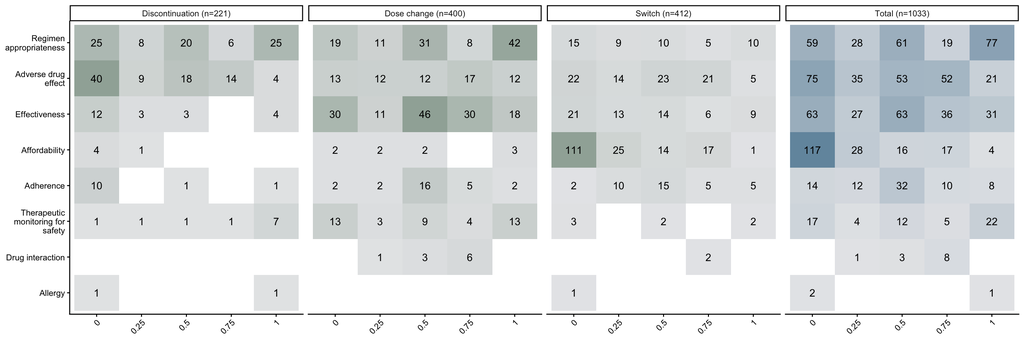

## 3.3 Probability of Trajectory Change Scoring

| **Characteristic** | **N** | **Intervention outcome** **Medication discontinuation** N = 221<sup>1</sup> | **Intervention outcome** **Medication switch** N = 412<sup>1</sup> | **Intervention outcome** **Medication dose change** N = 400<sup>1</sup> | **Overall** N = 1,033<sup>1</sup> |  |
| --- | --- | --- | --- | --- | --- | --- |
| pTC site evaluation | 1,033 |  |  |  |  |  |
| 0- Highly UNLIKELY the medication use trajectory changed as a result of the pharmacist |  | 87 (39.4%) | 151 (36.7%) | 75 (18.8%) | 313 (30.3%) |  |
| 0.25 |  | 29 (13.1%) | 84 (20.4%) | 55 (13.8%) | 168 (16.3%) |  |
| 0.5 |  | 43 (19.5%) | 86 (20.9%) | 108 (27.0%) | 237 (22.9%) |  |
| 0.75 |  | 37 (16.7%) | 77 (18.7%) | 112 (28.0%) | 226 (21.9%) |  |
| 1.0- Highly LIKELY the medication use trajectory changed as a result of the pharmacist |  | 25 (11.3%) | 14 (3.40%) | 50 (12.5%) | 89 (8.62%) |  |
| pTC final | 1,033 |  |  |  |  |  |
| 0- Highly UNLIKELY the medication use trajectory changed as a result of the pharmacist |  | 93 (42.1%) | 175 (42.5%) | 79 (19.8%) | 347 (33.6%) |  |
| 0.25 |  | 22 (9.95%) | 71 (17.2%) | 42 (10.5%) | 135 (13.1%) |  |
| 0.5 |  | 43 (19.5%) | 78 (18.9%) | 119 (29.8%) | 240 (23.2%) |  |
| 0.75 |  | 21 (9.50%) | 56 (13.6%) | 70 (17.5%) | 147 (14.2%) |  |
| 1.0- Highly LIKELY the medication use trajectory changed as a result of the pharmacist |  | 42 (19.0%) | 32 (7.77%) | 90 (22.5%) | 164 (15.9%) |  |
| Exclude |  | 0 (0%) | 0 (0%) | 0 (0%) | 0 (0%) |  |

<sup>1</sup> n (%)

## 3.4 PTC Figures

**Bar chart**

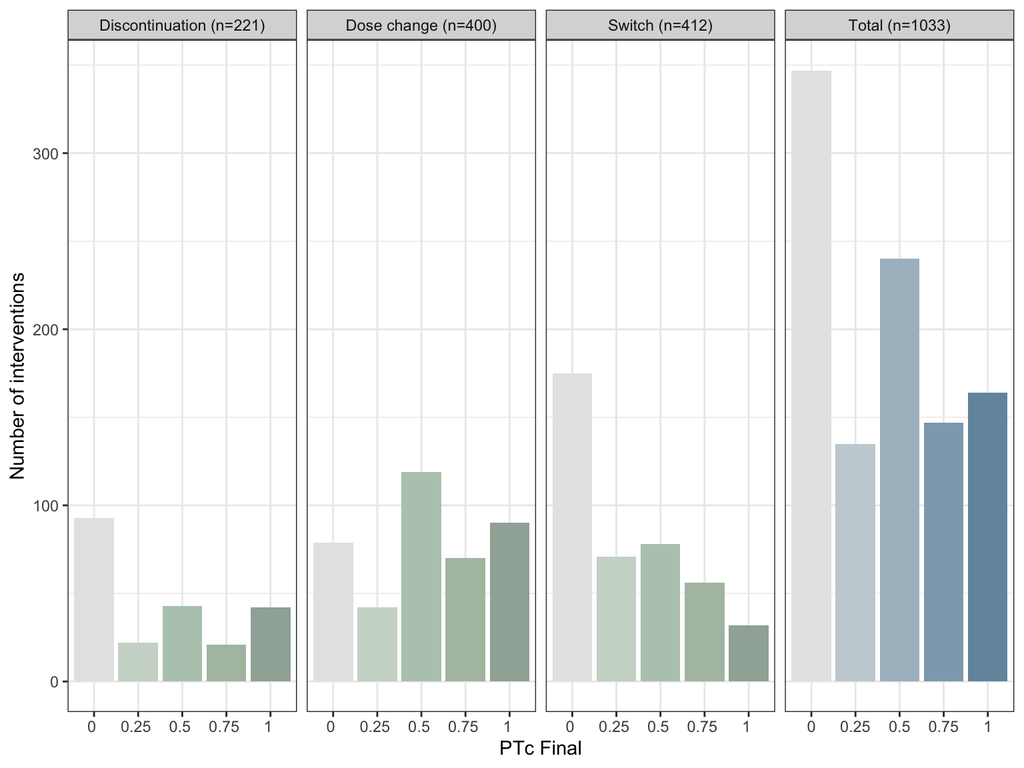

**Stacked bar chart**

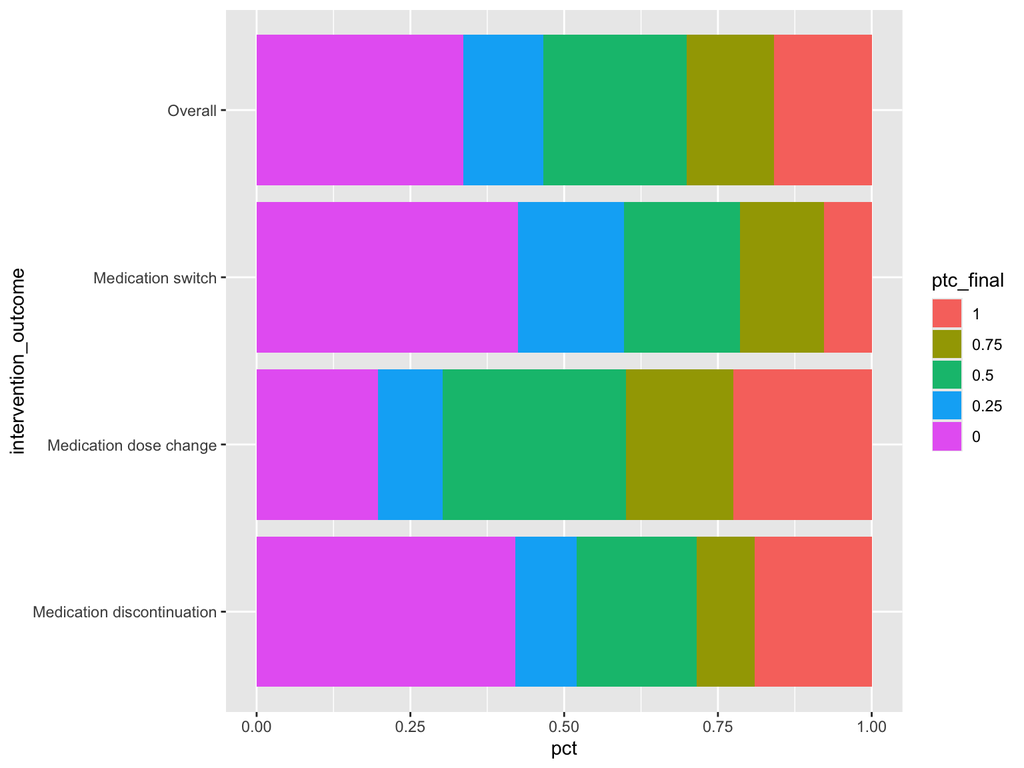

**First and Final score**

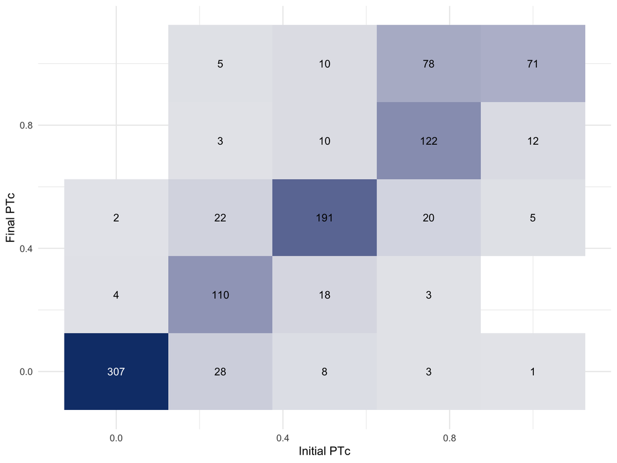

# 4 Cost analysis

## 4.1 Summary by PTc final

**Final PTc score**

**Column-wise**

| **Characteristic** | **N** | **PTc Final** **0** N = 347<sup>1</sup> | **PTc Final** **0.25** N = 135<sup>1</sup> | **PTc Final** **0.5** N = 240<sup>1</sup> | **PTc Final** **0.75** N = 147<sup>1</sup> | **PTc Final** **1** N = 164<sup>1</sup> | **Overall** N = 1,033<sup>1</sup> |  |
| --- | --- | --- | --- | --- | --- | --- | --- | --- |
| Pharmacy filling medication most recently | 1,033 |  |  |  |  |  |  |  |
| HSSP |  | 300 (86.5%) | 122 (90.4%) | 226 (94.2%) | 138 (93.9%) | 146 (89.0%) | 932 (90.2%) |  |
| non-HSSP |  | 47 (13.5%) | 13 (9.63%) | 14 (5.83%) | 9 (6.12%) | 18 (11.0%) | 101 (9.78%) |  |
| Clinical area | 1,033 |  |  |  |  |  |  |  |
| Rheumatology |  | 70 (20.2%) | 31 (23.0%) | 34 (14.2%) | 21 (14.3%) | 18 (11.0%) | 174 (16.8%) |  |
| Other neurology |  | 38 (11.0%) | 27 (20.0%) | 54 (22.5%) | 37 (25.2%) | 9 (5.49%) | 165 (16.0%) |  |
| Oncology |  | 31 (8.93%) | 14 (10.4%) | 46 (19.2%) | 21 (14.3%) | 50 (30.5%) | 162 (15.7%) |  |
| IBD |  | 55 (15.9%) | 11 (8.15%) | 15 (6.25%) | 8 (5.44%) | 10 (6.10%) | 99 (9.58%) |  |
| Dermatology |  | 23 (6.63%) | 11 (8.15%) | 26 (10.8%) | 15 (10.2%) | 14 (8.54%) | 89 (8.62%) |  |
| Other |  | 29 (8.36%) | 3 (2.22%) | 10 (4.17%) | 13 (8.84%) | 10 (6.10%) | 65 (6.29%) |  |
| Severe Asthma/Allergy |  | 20 (5.76%) | 7 (5.19%) | 21 (8.75%) | 7 (4.76%) | 4 (2.44%) | 59 (5.71%) |  |
| Adult Endocrinology |  | 28 (8.07%) | 9 (6.67%) | 9 (3.75%) | 1 (0.68%) | 7 (4.27%) | 54 (5.23%) |  |
| Other pulmonary |  | 19 (5.48%) | 6 (4.44%) | 4 (1.67%) | 6 (4.08%) | 8 (4.88%) | 43 (4.16%) |  |
| Multiple Sclerosis |  | 9 (2.59%) | 7 (5.19%) | 7 (2.92%) | 6 (4.08%) | 5 (3.05%) | 34 (3.29%) |  |
| Hematology |  | 5 (1.44%) | 3 (2.22%) | 8 (3.33%) | 3 (2.04%) | 13 (7.93%) | 32 (3.10%) |  |
| Transplant |  | 4 (1.15%) | 4 (2.96%) | 2 (0.83%) | 0 (0%) | 6 (3.66%) | 16 (1.55%) |  |
| Hepatology |  | 5 (1.44%) | 1 (0.74%) | 1 (0.42%) | 2 (1.36%) | 5 (3.05%) | 14 (1.36%) |  |
| Pediatric endocrinology |  | 5 (1.44%) | 0 (0%) | 1 (0.42%) | 3 (2.04%) | 0 (0%) | 9 (0.87%) |  |
| HIV |  | 2 (0.58%) | 0 (0%) | 0 (0%) | 3 (2.04%) | 3 (1.83%) | 8 (0.77%) |  |
| Pediatric inflammatory conditions |  | 4 (1.15%) | 0 (0%) | 1 (0.42%) | 0 (0%) | 0 (0%) | 5 (0.48%) |  |
| Cystic fibrosis |  | 0 (0%) | 1 (0.74%) | 0 (0%) | 0 (0%) | 2 (1.22%) | 3 (0.29%) |  |
| Hepatitis C |  | 0 (0%) | 0 (0%) | 1 (0.42%) | 0 (0%) | 0 (0%) | 1 (0.10%) |  |
| Bleeding Disorders |  | 0 (0%) | 0 (0%) | 0 (0%) | 1 (0.68%) | 0 (0%) | 1 (0.10%) |  |
| Intervention outcome | 1,033 |  |  |  |  |  |  |  |
| Medication switch |  | 175 (50.4%) | 71 (52.6%) | 78 (32.5%) | 56 (38.1%) | 32 (19.5%) | 412 (39.9%) |  |
| Medication dose change |  | 79 (22.8%) | 42 (31.1%) | 119 (49.6%) | 70 (47.6%) | 90 (54.9%) | 400 (38.7%) |  |
| Medication discontinuation |  | 93 (26.8%) | 22 (16.3%) | 43 (17.9%) | 21 (14.3%) | 42 (25.6%) | 221 (21.4%) |  |
| Intervention reason | 1,033 |  |  |  |  |  |  |  |
| Regimen appropriateness |  | 59 (17.0%) | 28 (20.7%) | 61 (25.4%) | 19 (12.9%) | 77 (47.0%) | 244 (23.6%) |  |
| Adverse drug effect |  | 75 (21.6%) | 35 (25.9%) | 53 (22.1%) | 52 (35.4%) | 21 (12.8%) | 236 (22.8%) |  |
| Effectiveness |  | 63 (18.2%) | 27 (20.0%) | 63 (26.3%) | 36 (24.5%) | 31 (18.9%) | 220 (21.3%) |  |
| Affordability |  | 117 (33.7%) | 28 (20.7%) | 16 (6.67%) | 17 (11.6%) | 4 (2.44%) | 182 (17.6%) |  |
| Adherence |  | 14 (4.03%) | 12 (8.89%) | 32 (13.3%) | 10 (6.80%) | 8 (4.88%) | 76 (7.36%) |  |
| Therapeutic monitoring for safety |  | 17 (4.90%) | 4 (2.96%) | 12 (5.00%) | 5 (3.40%) | 22 (13.4%) | 60 (5.81%) |  |
| Drug interaction |  | 0 (0%) | 1 (0.74%) | 3 (1.25%) | 8 (5.44%) | 0 (0%) | 12 (1.16%) |  |
| Allergy |  | 2 (0.58%) | 0 (0%) | 0 (0%) | 0 (0%) | 1 (0.61%) | 3 (0.29%) |  |

<sup>1</sup> n (%)

**Row-wise**

| **Characteristic** | **N** | **PTc Final** **0** N = 347<sup>1</sup> | **PTc Final** **0.25** N = 135<sup>1</sup> | **PTc Final** **0.5** N = 240<sup>1</sup> | **PTc Final** **0.75** N = 147<sup>1</sup> | **PTc Final** **1** N = 164<sup>1</sup> | **Overall** N = 1,033<sup>1</sup> |  |
| --- | --- | --- | --- | --- | --- | --- | --- | --- |
| Pharmacy filling medication most recently | 1,033 |  |  |  |  |  |  |  |
| HSSP |  | 300 (32.2%) | 122 (13.1%) | 226 (24.2%) | 138 (14.8%) | 146 (15.7%) | 932 (100.0%) |  |
| non-HSSP |  | 47 (46.5%) | 13 (12.9%) | 14 (13.9%) | 9 (8.91%) | 18 (17.8%) | 101 (100.0%) |  |
| Clinical area | 1,033 |  |  |  |  |  |  |  |
| Rheumatology |  | 70 (40.2%) | 31 (17.8%) | 34 (19.5%) | 21 (12.1%) | 18 (10.3%) | 174 (100.0%) |  |
| Other neurology |  | 38 (23.0%) | 27 (16.4%) | 54 (32.7%) | 37 (22.4%) | 9 (5.45%) | 165 (100.0%) |  |
| Oncology |  | 31 (19.1%) | 14 (8.64%) | 46 (28.4%) | 21 (13.0%) | 50 (30.9%) | 162 (100.0%) |  |
| IBD |  | 55 (55.6%) | 11 (11.1%) | 15 (15.2%) | 8 (8.08%) | 10 (10.1%) | 99 (100.0%) |  |
| Dermatology |  | 23 (25.8%) | 11 (12.4%) | 26 (29.2%) | 15 (16.9%) | 14 (15.7%) | 89 (100.0%) |  |
| Other |  | 29 (44.6%) | 3 (4.62%) | 10 (15.4%) | 13 (20.0%) | 10 (15.4%) | 65 (100.0%) |  |
| Severe Asthma/Allergy |  | 20 (33.9%) | 7 (11.9%) | 21 (35.6%) | 7 (11.9%) | 4 (6.78%) | 59 (100.0%) |  |
| Adult Endocrinology |  | 28 (51.9%) | 9 (16.7%) | 9 (16.7%) | 1 (1.85%) | 7 (13.0%) | 54 (100.0%) |  |
| Other pulmonary |  | 19 (44.2%) | 6 (14.0%) | 4 (9.30%) | 6 (14.0%) | 8 (18.6%) | 43 (100.0%) |  |
| Multiple Sclerosis |  | 9 (26.5%) | 7 (20.6%) | 7 (20.6%) | 6 (17.6%) | 5 (14.7%) | 34 (100.0%) |  |
| Hematology |  | 5 (15.6%) | 3 (9.38%) | 8 (25.0%) | 3 (9.38%) | 13 (40.6%) | 32 (100.0%) |  |
| Transplant |  | 4 (25.0%) | 4 (25.0%) | 2 (12.5%) | 0 (0%) | 6 (37.5%) | 16 (100.0%) |  |
| Hepatology |  | 5 (35.7%) | 1 (7.14%) | 1 (7.14%) | 2 (14.3%) | 5 (35.7%) | 14 (100.0%) |  |
| Pediatric endocrinology |  | 5 (55.6%) | 0 (0%) | 1 (11.1%) | 3 (33.3%) | 0 (0%) | 9 (100.0%) |  |
| HIV |  | 2 (25.0%) | 0 (0%) | 0 (0%) | 3 (37.5%) | 3 (37.5%) | 8 (100.0%) |  |
| Pediatric inflammatory conditions |  | 4 (80.0%) | 0 (0%) | 1 (20.0%) | 0 (0%) | 0 (0%) | 5 (100.0%) |  |
| Cystic fibrosis |  | 0 (0%) | 1 (33.3%) | 0 (0%) | 0 (0%) | 2 (66.7%) | 3 (100.0%) |  |
| Hepatitis C |  | 0 (0%) | 0 (0%) | 1 (100.0%) | 0 (0%) | 0 (0%) | 1 (100.0%) |  |
| Bleeding Disorders |  | 0 (0%) | 0 (0%) | 0 (0%) | 1 (100.0%) | 0 (0%) | 1 (100.0%) |  |
| Intervention outcome | 1,033 |  |  |  |  |  |  |  |
| Medication switch |  | 175 (42.5%) | 71 (17.2%) | 78 (18.9%) | 56 (13.6%) | 32 (7.77%) | 412 (100.0%) |  |
| Medication dose change |  | 79 (19.8%) | 42 (10.5%) | 119 (29.8%) | 70 (17.5%) | 90 (22.5%) | 400 (100.0%) |  |
| Medication discontinuation |  | 93 (42.1%) | 22 (9.95%) | 43 (19.5%) | 21 (9.50%) | 42 (19.0%) | 221 (100.0%) |  |
| Intervention reason | 1,033 |  |  |  |  |  |  |  |
| Regimen appropriateness |  | 59 (24.2%) | 28 (11.5%) | 61 (25.0%) | 19 (7.79%) | 77 (31.6%) | 244 (100.0%) |  |
| Adverse drug effect |  | 75 (31.8%) | 35 (14.8%) | 53 (22.5%) | 52 (22.0%) | 21 (8.90%) | 236 (100.0%) |  |
| Effectiveness |  | 63 (28.6%) | 27 (12.3%) | 63 (28.6%) | 36 (16.4%) | 31 (14.1%) | 220 (100.0%) |  |
| Affordability |  | 117 (64.3%) | 28 (15.4%) | 16 (8.79%) | 17 (9.34%) | 4 (2.20%) | 182 (100.0%) |  |
| Adherence |  | 14 (18.4%) | 12 (15.8%) | 32 (42.1%) | 10 (13.2%) | 8 (10.5%) | 76 (100.0%) |  |
| Therapeutic monitoring for safety |  | 17 (28.3%) | 4 (6.67%) | 12 (20.0%) | 5 (8.33%) | 22 (36.7%) | 60 (100.0%) |  |
| Drug interaction |  | 0 (0%) | 1 (8.33%) | 3 (25.0%) | 8 (66.7%) | 0 (0%) | 12 (100.0%) |  |
| Allergy |  | 2 (66.7%) | 0 (0%) | 0 (0%) | 0 (0%) | 1 (33.3%) | 3 (100.0%) |  |

<sup>1</sup> n (%)

**Dichotomized PTc score**

**Column-wise**

| **Characteristic** | **N** | **PTc Final** **PTc = 0** N = 347<sup>1</sup> | **PTc Final** **PTc > 0** N = 686<sup>1</sup> | **Overall** N = 1,033<sup>1</sup> |  |
| --- | --- | --- | --- | --- | --- |
| Pharmacy filling medication most recently | 1,033 |  |  |  |  |
| HSSP |  | 300 (86.5%) | 632 (92.1%) | 932 (90.2%) |  |
| non-HSSP |  | 47 (13.5%) | 54 (7.87%) | 101 (9.78%) |  |
| Clinical area | 1,033 |  |  |  |  |
| Rheumatology |  | 70 (20.2%) | 104 (15.2%) | 174 (16.8%) |  |
| Other neurology |  | 38 (11.0%) | 127 (18.5%) | 165 (16.0%) |  |
| Oncology |  | 31 (8.93%) | 131 (19.1%) | 162 (15.7%) |  |
| IBD |  | 55 (15.9%) | 44 (6.41%) | 99 (9.58%) |  |
| Dermatology |  | 23 (6.63%) | 66 (9.62%) | 89 (8.62%) |  |
| Other |  | 29 (8.36%) | 36 (5.25%) | 65 (6.29%) |  |
| Severe Asthma/Allergy |  | 20 (5.76%) | 39 (5.69%) | 59 (5.71%) |  |
| Adult Endocrinology |  | 28 (8.07%) | 26 (3.79%) | 54 (5.23%) |  |
| Other pulmonary |  | 19 (5.48%) | 24 (3.50%) | 43 (4.16%) |  |
| Multiple Sclerosis |  | 9 (2.59%) | 25 (3.64%) | 34 (3.29%) |  |
| Hematology |  | 5 (1.44%) | 27 (3.94%) | 32 (3.10%) |  |
| Transplant |  | 4 (1.15%) | 12 (1.75%) | 16 (1.55%) |  |
| Hepatology |  | 5 (1.44%) | 9 (1.31%) | 14 (1.36%) |  |
| Pediatric endocrinology |  | 5 (1.44%) | 4 (0.58%) | 9 (0.87%) |  |
| HIV |  | 2 (0.58%) | 6 (0.87%) | 8 (0.77%) |  |
| Pediatric inflammatory conditions |  | 4 (1.15%) | 1 (0.15%) | 5 (0.48%) |  |
| Cystic fibrosis |  | 0 (0%) | 3 (0.44%) | 3 (0.29%) |  |
| Hepatitis C |  | 0 (0%) | 1 (0.15%) | 1 (0.10%) |  |
| Bleeding Disorders |  | 0 (0%) | 1 (0.15%) | 1 (0.10%) |  |
| Intervention outcome | 1,033 |  |  |  |  |
| Medication switch |  | 175 (50.4%) | 237 (34.5%) | 412 (39.9%) |  |
| Medication dose change |  | 79 (22.8%) | 321 (46.8%) | 400 (38.7%) |  |
| Medication discontinuation |  | 93 (26.8%) | 128 (18.7%) | 221 (21.4%) |  |
| Intervention reason | 1,033 |  |  |  |  |
| Regimen appropriateness |  | 59 (17.0%) | 185 (27.0%) | 244 (23.6%) |  |
| Adverse drug effect |  | 75 (21.6%) | 161 (23.5%) | 236 (22.8%) |  |
| Effectiveness |  | 63 (18.2%) | 157 (22.9%) | 220 (21.3%) |  |
| Affordability |  | 117 (33.7%) | 65 (9.48%) | 182 (17.6%) |  |
| Adherence |  | 14 (4.03%) | 62 (9.04%) | 76 (7.36%) |  |
| Therapeutic monitoring for safety |  | 17 (4.90%) | 43 (6.27%) | 60 (5.81%) |  |
| Drug interaction |  | 0 (0%) | 12 (1.75%) | 12 (1.16%) |  |
| Allergy |  | 2 (0.58%) | 1 (0.15%) | 3 (0.29%) |  |

<sup>1</sup> n (%)

**Row-wise**

| **Characteristic** | **N** | **PTc Final** **PTc = 0** N = 347<sup>1</sup> | **PTc Final** **PTc > 0** N = 686<sup>1</sup> | **Overall** N = 1,033<sup>1</sup> |  |
| --- | --- | --- | --- | --- | --- |
| Pharmacy filling medication most recently | 1,033 |  |  |  |  |
| HSSP |  | 300 (32.2%) | 632 (67.8%) | 932 (100.0%) |  |
| non-HSSP |  | 47 (46.5%) | 54 (53.5%) | 101 (100.0%) |  |
| Clinical area | 1,033 |  |  |  |  |
| Rheumatology |  | 70 (40.2%) | 104 (59.8%) | 174 (100.0%) |  |
| Other neurology |  | 38 (23.0%) | 127 (77.0%) | 165 (100.0%) |  |
| Oncology |  | 31 (19.1%) | 131 (80.9%) | 162 (100.0%) |  |
| IBD |  | 55 (55.6%) | 44 (44.4%) | 99 (100.0%) |  |
| Dermatology |  | 23 (25.8%) | 66 (74.2%) | 89 (100.0%) |  |
| Other |  | 29 (44.6%) | 36 (55.4%) | 65 (100.0%) |  |
| Severe Asthma/Allergy |  | 20 (33.9%) | 39 (66.1%) | 59 (100.0%) |  |
| Adult Endocrinology |  | 28 (51.9%) | 26 (48.1%) | 54 (100.0%) |  |
| Other pulmonary |  | 19 (44.2%) | 24 (55.8%) | 43 (100.0%) |  |
| Multiple Sclerosis |  | 9 (26.5%) | 25 (73.5%) | 34 (100.0%) |  |
| Hematology |  | 5 (15.6%) | 27 (84.4%) | 32 (100.0%) |  |
| Transplant |  | 4 (25.0%) | 12 (75.0%) | 16 (100.0%) |  |
| Hepatology |  | 5 (35.7%) | 9 (64.3%) | 14 (100.0%) |  |
| Pediatric endocrinology |  | 5 (55.6%) | 4 (44.4%) | 9 (100.0%) |  |
| HIV |  | 2 (25.0%) | 6 (75.0%) | 8 (100.0%) |  |
| Pediatric inflammatory conditions |  | 4 (80.0%) | 1 (20.0%) | 5 (100.0%) |  |
| Cystic fibrosis |  | 0 (0%) | 3 (100.0%) | 3 (100.0%) |  |
| Hepatitis C |  | 0 (0%) | 1 (100.0%) | 1 (100.0%) |  |
| Bleeding Disorders |  | 0 (0%) | 1 (100.0%) | 1 (100.0%) |  |
| Intervention outcome | 1,033 |  |  |  |  |
| Medication switch |  | 175 (42.5%) | 237 (57.5%) | 412 (100.0%) |  |
| Medication dose change |  | 79 (19.8%) | 321 (80.3%) | 400 (100.0%) |  |
| Medication discontinuation |  | 93 (42.1%) | 128 (57.9%) | 221 (100.0%) |  |
| Intervention reason | 1,033 |  |  |  |  |
| Regimen appropriateness |  | 59 (24.2%) | 185 (75.8%) | 244 (100.0%) |  |
| Adverse drug effect |  | 75 (31.8%) | 161 (68.2%) | 236 (100.0%) |  |
| Effectiveness |  | 63 (28.6%) | 157 (71.4%) | 220 (100.0%) |  |
| Affordability |  | 117 (64.3%) | 65 (35.7%) | 182 (100.0%) |  |
| Adherence |  | 14 (18.4%) | 62 (81.6%) | 76 (100.0%) |  |
| Therapeutic monitoring for safety |  | 17 (28.3%) | 43 (71.7%) | 60 (100.0%) |  |
| Drug interaction |  | 0 (0%) | 12 (100.0%) | 12 (100.0%) |  |
| Allergy |  | 2 (66.7%) | 1 (33.3%) | 3 (100.0%) |  |

<sup>1</sup> n (%)

**Sensitivity lower bound PTc score**

**Column-wise**

| **Characteristic** | **N** | **PTc lower bound** **0** N = 482<sup>1</sup> | **PTc lower bound** **0.25** N = 240<sup>1</sup> | **PTc lower bound** **0.5** N = 147<sup>1</sup> | **PTc lower bound** **0.75** N = 164<sup>1</sup> | **Overall** N = 1,033<sup>1</sup> |  |
| --- | --- | --- | --- | --- | --- | --- | --- |
| Pharmacy filling medication most recently | 1,033 |  |  |  |  |  |  |
| HSSP |  | 422 (87.6%) | 226 (94.2%) | 138 (93.9%) | 146 (89.0%) | 932 (90.2%) |  |
| non-HSSP |  | 60 (12.4%) | 14 (5.83%) | 9 (6.12%) | 18 (11.0%) | 101 (9.78%) |  |
| Clinical area | 1,033 |  |  |  |  |  |  |
| Rheumatology |  | 101 (21.0%) | 34 (14.2%) | 21 (14.3%) | 18 (11.0%) | 174 (16.8%) |  |
| Other neurology |  | 65 (13.5%) | 54 (22.5%) | 37 (25.2%) | 9 (5.49%) | 165 (16.0%) |  |
| Oncology |  | 45 (9.34%) | 46 (19.2%) | 21 (14.3%) | 50 (30.5%) | 162 (15.7%) |  |
| IBD |  | 66 (13.7%) | 15 (6.25%) | 8 (5.44%) | 10 (6.10%) | 99 (9.58%) |  |
| Dermatology |  | 34 (7.05%) | 26 (10.8%) | 15 (10.2%) | 14 (8.54%) | 89 (8.62%) |  |
| Other |  | 32 (6.64%) | 10 (4.17%) | 13 (8.84%) | 10 (6.10%) | 65 (6.29%) |  |
| Severe Asthma/Allergy |  | 27 (5.60%) | 21 (8.75%) | 7 (4.76%) | 4 (2.44%) | 59 (5.71%) |  |
| Adult Endocrinology |  | 37 (7.68%) | 9 (3.75%) | 1 (0.68%) | 7 (4.27%) | 54 (5.23%) |  |
| Other pulmonary |  | 25 (5.19%) | 4 (1.67%) | 6 (4.08%) | 8 (4.88%) | 43 (4.16%) |  |
| Multiple Sclerosis |  | 16 (3.32%) | 7 (2.92%) | 6 (4.08%) | 5 (3.05%) | 34 (3.29%) |  |
| Hematology |  | 8 (1.66%) | 8 (3.33%) | 3 (2.04%) | 13 (7.93%) | 32 (3.10%) |  |
| Transplant |  | 8 (1.66%) | 2 (0.83%) | 0 (0%) | 6 (3.66%) | 16 (1.55%) |  |
| Hepatology |  | 6 (1.24%) | 1 (0.42%) | 2 (1.36%) | 5 (3.05%) | 14 (1.36%) |  |
| Pediatric endocrinology |  | 5 (1.04%) | 1 (0.42%) | 3 (2.04%) | 0 (0%) | 9 (0.87%) |  |
| HIV |  | 2 (0.41%) | 0 (0%) | 3 (2.04%) | 3 (1.83%) | 8 (0.77%) |  |
| Pediatric inflammatory conditions |  | 4 (0.83%) | 1 (0.42%) | 0 (0%) | 0 (0%) | 5 (0.48%) |  |
| Cystic fibrosis |  | 1 (0.21%) | 0 (0%) | 0 (0%) | 2 (1.22%) | 3 (0.29%) |  |
| Hepatitis C |  | 0 (0%) | 1 (0.42%) | 0 (0%) | 0 (0%) | 1 (0.10%) |  |
| Bleeding Disorders |  | 0 (0%) | 0 (0%) | 1 (0.68%) | 0 (0%) | 1 (0.10%) |  |
| Intervention outcome | 1,033 |  |  |  |  |  |  |
| Medication switch |  | 246 (51.0%) | 78 (32.5%) | 56 (38.1%) | 32 (19.5%) | 412 (39.9%) |  |
| Medication dose change |  | 121 (25.1%) | 119 (49.6%) | 70 (47.6%) | 90 (54.9%) | 400 (38.7%) |  |
| Medication discontinuation |  | 115 (23.9%) | 43 (17.9%) | 21 (14.3%) | 42 (25.6%) | 221 (21.4%) |  |
| Intervention reason | 1,033 |  |  |  |  |  |  |
| Regimen appropriateness |  | 87 (18.0%) | 61 (25.4%) | 19 (12.9%) | 77 (47.0%) | 244 (23.6%) |  |
| Adverse drug effect |  | 110 (22.8%) | 53 (22.1%) | 52 (35.4%) | 21 (12.8%) | 236 (22.8%) |  |
| Effectiveness |  | 90 (18.7%) | 63 (26.3%) | 36 (24.5%) | 31 (18.9%) | 220 (21.3%) |  |
| Affordability |  | 145 (30.1%) | 16 (6.67%) | 17 (11.6%) | 4 (2.44%) | 182 (17.6%) |  |
| Adherence |  | 26 (5.39%) | 32 (13.3%) | 10 (6.80%) | 8 (4.88%) | 76 (7.36%) |  |
| Therapeutic monitoring for safety |  | 21 (4.36%) | 12 (5.00%) | 5 (3.40%) | 22 (13.4%) | 60 (5.81%) |  |
| Drug interaction |  | 1 (0.21%) | 3 (1.25%) | 8 (5.44%) | 0 (0%) | 12 (1.16%) |  |
| Allergy |  | 2 (0.41%) | 0 (0%) | 0 (0%) | 1 (0.61%) | 3 (0.29%) |  |

<sup>1</sup> n (%)

**Row-wise**

| **Characteristic** | **N** | **PTc lower bound** **0** N = 482<sup>1</sup> | **PTc lower bound** **0.25** N = 240<sup>1</sup> | **PTc lower bound** **0.5** N = 147<sup>1</sup> | **PTc lower bound** **0.75** N = 164<sup>1</sup> | **Overall** N = 1,033<sup>1</sup> |  |
| --- | --- | --- | --- | --- | --- | --- | --- |
| Pharmacy filling medication most recently | 1,033 |  |  |  |  |  |  |
| HSSP |  | 422 (45.3%) | 226 (24.2%) | 138 (14.8%) | 146 (15.7%) | 932 (100.0%) |  |
| non-HSSP |  | 60 (59.4%) | 14 (13.9%) | 9 (8.91%) | 18 (17.8%) | 101 (100.0%) |  |
| Clinical area | 1,033 |  |  |  |  |  |  |
| Rheumatology |  | 101 (58.0%) | 34 (19.5%) | 21 (12.1%) | 18 (10.3%) | 174 (100.0%) |  |
| Other neurology |  | 65 (39.4%) | 54 (32.7%) | 37 (22.4%) | 9 (5.45%) | 165 (100.0%) |  |
| Oncology |  | 45 (27.8%) | 46 (28.4%) | 21 (13.0%) | 50 (30.9%) | 162 (100.0%) |  |
| IBD |  | 66 (66.7%) | 15 (15.2%) | 8 (8.08%) | 10 (10.1%) | 99 (100.0%) |  |
| Dermatology |  | 34 (38.2%) | 26 (29.2%) | 15 (16.9%) | 14 (15.7%) | 89 (100.0%) |  |
| Other |  | 32 (49.2%) | 10 (15.4%) | 13 (20.0%) | 10 (15.4%) | 65 (100.0%) |  |
| Severe Asthma/Allergy |  | 27 (45.8%) | 21 (35.6%) | 7 (11.9%) | 4 (6.78%) | 59 (100.0%) |  |
| Adult Endocrinology |  | 37 (68.5%) | 9 (16.7%) | 1 (1.85%) | 7 (13.0%) | 54 (100.0%) |  |
| Other pulmonary |  | 25 (58.1%) | 4 (9.30%) | 6 (14.0%) | 8 (18.6%) | 43 (100.0%) |  |
| Multiple Sclerosis |  | 16 (47.1%) | 7 (20.6%) | 6 (17.6%) | 5 (14.7%) | 34 (100.0%) |  |
| Hematology |  | 8 (25.0%) | 8 (25.0%) | 3 (9.38%) | 13 (40.6%) | 32 (100.0%) |  |
| Transplant |  | 8 (50.0%) | 2 (12.5%) | 0 (0%) | 6 (37.5%) | 16 (100.0%) |  |
| Hepatology |  | 6 (42.9%) | 1 (7.14%) | 2 (14.3%) | 5 (35.7%) | 14 (100.0%) |  |
| Pediatric endocrinology |  | 5 (55.6%) | 1 (11.1%) | 3 (33.3%) | 0 (0%) | 9 (100.0%) |  |
| HIV |  | 2 (25.0%) | 0 (0%) | 3 (37.5%) | 3 (37.5%) | 8 (100.0%) |  |
| Pediatric inflammatory conditions |  | 4 (80.0%) | 1 (20.0%) | 0 (0%) | 0 (0%) | 5 (100.0%) |  |
| Cystic fibrosis |  | 1 (33.3%) | 0 (0%) | 0 (0%) | 2 (66.7%) | 3 (100.0%) |  |
| Hepatitis C |  | 0 (0%) | 1 (100.0%) | 0 (0%) | 0 (0%) | 1 (100.0%) |  |
| Bleeding Disorders |  | 0 (0%) | 0 (0%) | 1 (100.0%) | 0 (0%) | 1 (100.0%) |  |
| Intervention outcome | 1,033 |  |  |  |  |  |  |
| Medication switch |  | 246 (59.7%) | 78 (18.9%) | 56 (13.6%) | 32 (7.77%) | 412 (100.0%) |  |
| Medication dose change |  | 121 (30.3%) | 119 (29.8%) | 70 (17.5%) | 90 (22.5%) | 400 (100.0%) |  |
| Medication discontinuation |  | 115 (52.0%) | 43 (19.5%) | 21 (9.50%) | 42 (19.0%) | 221 (100.0%) |  |
| Intervention reason | 1,033 |  |  |  |  |  |  |
| Regimen appropriateness |  | 87 (35.7%) | 61 (25.0%) | 19 (7.79%) | 77 (31.6%) | 244 (100.0%) |  |
| Adverse drug effect |  | 110 (46.6%) | 53 (22.5%) | 52 (22.0%) | 21 (8.90%) | 236 (100.0%) |  |
| Effectiveness |  | 90 (40.9%) | 63 (28.6%) | 36 (16.4%) | 31 (14.1%) | 220 (100.0%) |  |
| Affordability |  | 145 (79.7%) | 16 (8.79%) | 17 (9.34%) | 4 (2.20%) | 182 (100.0%) |  |
| Adherence |  | 26 (34.2%) | 32 (42.1%) | 10 (13.2%) | 8 (10.5%) | 76 (100.0%) |  |
| Therapeutic monitoring for safety |  | 21 (35.0%) | 12 (20.0%) | 5 (8.33%) | 22 (36.7%) | 60 (100.0%) |  |
| Drug interaction |  | 1 (8.33%) | 3 (25.0%) | 8 (66.7%) | 0 (0%) | 12 (100.0%) |  |
| Allergy |  | 2 (66.7%) | 0 (0%) | 0 (0%) | 1 (33.3%) | 3 (100.0%) |  |

<sup>1</sup> n (%)

**Dichotomized lower bound PTc score**

**Column-wise**

| **Characteristic** | **N** | **PTc lower bound** **PTc = 0** N = 482<sup>1</sup> | **PTc lower bound** **PTc > 0** N = 551<sup>1</sup> | **Overall** N = 1,033<sup>1</sup> |  |
| --- | --- | --- | --- | --- | --- |
| PTC final sensitivity lower bound | 1,033 |  |  |  |  |
| 0 |  | 482 (100.0%) | 0 (0%) | 482 (46.7%) |  |
| 0.25 |  | 0 (0%) | 240 (43.6%) | 240 (23.2%) |  |
| 0.75 |  | 0 (0%) | 164 (29.8%) | 164 (15.9%) |  |
| 0.5 |  | 0 (0%) | 147 (26.7%) | 147 (14.2%) |  |
| Pharmacy filling medication most recently | 1,033 |  |  |  |  |
| HSSP |  | 422 (87.6%) | 510 (92.6%) | 932 (90.2%) |  |
| non-HSSP |  | 60 (12.4%) | 41 (7.44%) | 101 (9.78%) |  |
| Clinical area | 1,033 |  |  |  |  |
| Rheumatology |  | 101 (21.0%) | 73 (13.2%) | 174 (16.8%) |  |
| Other neurology |  | 65 (13.5%) | 100 (18.1%) | 165 (16.0%) |  |
| Oncology |  | 45 (9.34%) | 117 (21.2%) | 162 (15.7%) |  |
| IBD |  | 66 (13.7%) | 33 (5.99%) | 99 (9.58%) |  |
| Dermatology |  | 34 (7.05%) | 55 (9.98%) | 89 (8.62%) |  |
| Other |  | 32 (6.64%) | 33 (5.99%) | 65 (6.29%) |  |
| Severe Asthma/Allergy |  | 27 (5.60%) | 32 (5.81%) | 59 (5.71%) |  |
| Adult Endocrinology |  | 37 (7.68%) | 17 (3.09%) | 54 (5.23%) |  |
| Other pulmonary |  | 25 (5.19%) | 18 (3.27%) | 43 (4.16%) |  |
| Multiple Sclerosis |  | 16 (3.32%) | 18 (3.27%) | 34 (3.29%) |  |
| Hematology |  | 8 (1.66%) | 24 (4.36%) | 32 (3.10%) |  |
| Transplant |  | 8 (1.66%) | 8 (1.45%) | 16 (1.55%) |  |
| Hepatology |  | 6 (1.24%) | 8 (1.45%) | 14 (1.36%) |  |
| Pediatric endocrinology |  | 5 (1.04%) | 4 (0.73%) | 9 (0.87%) |  |
| HIV |  | 2 (0.41%) | 6 (1.09%) | 8 (0.77%) |  |
| Pediatric inflammatory conditions |  | 4 (0.83%) | 1 (0.18%) | 5 (0.48%) |  |
| Cystic fibrosis |  | 1 (0.21%) | 2 (0.36%) | 3 (0.29%) |  |
| Hepatitis C |  | 0 (0%) | 1 (0.18%) | 1 (0.10%) |  |
| Bleeding Disorders |  | 0 (0%) | 1 (0.18%) | 1 (0.10%) |  |
| Intervention outcome | 1,033 |  |  |  |  |
| Medication switch |  | 246 (51.0%) | 166 (30.1%) | 412 (39.9%) |  |
| Medication dose change |  | 121 (25.1%) | 279 (50.6%) | 400 (38.7%) |  |
| Medication discontinuation |  | 115 (23.9%) | 106 (19.2%) | 221 (21.4%) |  |
| Intervention reason | 1,033 |  |  |  |  |
| Regimen appropriateness |  | 87 (18.0%) | 157 (28.5%) | 244 (23.6%) |  |
| Adverse drug effect |  | 110 (22.8%) | 126 (22.9%) | 236 (22.8%) |  |
| Effectiveness |  | 90 (18.7%) | 130 (23.6%) | 220 (21.3%) |  |
| Affordability |  | 145 (30.1%) | 37 (6.72%) | 182 (17.6%) |  |
| Adherence |  | 26 (5.39%) | 50 (9.07%) | 76 (7.36%) |  |
| Therapeutic monitoring for safety |  | 21 (4.36%) | 39 (7.08%) | 60 (5.81%) |  |
| Drug interaction |  | 1 (0.21%) | 11 (2.00%) | 12 (1.16%) |  |
| Allergy |  | 2 (0.41%) | 1 (0.18%) | 3 (0.29%) |  |

<sup>1</sup> n (%)

**Row-wise**

| **Characteristic** | **N** | **PTc lower bound** **PTc = 0** N = 482<sup>1</sup> | **PTc lower bound** **PTc > 0** N = 551<sup>1</sup> | **Overall** N = 1,033<sup>1</sup> |  |
| --- | --- | --- | --- | --- | --- |
| PTC final sensitivity lower bound | 1,033 |  |  |  |  |
| 0 |  | 482 (100.0%) | 0 (0%) | 482 (100.0%) |  |
| 0.25 |  | 0 (0%) | 240 (100.0%) | 240 (100.0%) |  |
| 0.75 |  | 0 (0%) | 164 (100.0%) | 164 (100.0%) |  |
| 0.5 |  | 0 (0%) | 147 (100.0%) | 147 (100.0%) |  |
| Pharmacy filling medication most recently | 1,033 |  |  |  |  |
| HSSP |  | 422 (45.3%) | 510 (54.7%) | 932 (100.0%) |  |
| non-HSSP |  | 60 (59.4%) | 41 (40.6%) | 101 (100.0%) |  |
| Clinical area | 1,033 |  |  |  |  |
| Rheumatology |  | 101 (58.0%) | 73 (42.0%) | 174 (100.0%) |  |
| Other neurology |  | 65 (39.4%) | 100 (60.6%) | 165 (100.0%) |  |
| Oncology |  | 45 (27.8%) | 117 (72.2%) | 162 (100.0%) |  |
| IBD |  | 66 (66.7%) | 33 (33.3%) | 99 (100.0%) |  |
| Dermatology |  | 34 (38.2%) | 55 (61.8%) | 89 (100.0%) |  |
| Other |  | 32 (49.2%) | 33 (50.8%) | 65 (100.0%) |  |
| Severe Asthma/Allergy |  | 27 (45.8%) | 32 (54.2%) | 59 (100.0%) |  |
| Adult Endocrinology |  | 37 (68.5%) | 17 (31.5%) | 54 (100.0%) |  |
| Other pulmonary |  | 25 (58.1%) | 18 (41.9%) | 43 (100.0%) |  |
| Multiple Sclerosis |  | 16 (47.1%) | 18 (52.9%) | 34 (100.0%) |  |
| Hematology |  | 8 (25.0%) | 24 (75.0%) | 32 (100.0%) |  |
| Transplant |  | 8 (50.0%) | 8 (50.0%) | 16 (100.0%) |  |
| Hepatology |  | 6 (42.9%) | 8 (57.1%) | 14 (100.0%) |  |
| Pediatric endocrinology |  | 5 (55.6%) | 4 (44.4%) | 9 (100.0%) |  |
| HIV |  | 2 (25.0%) | 6 (75.0%) | 8 (100.0%) |  |
| Pediatric inflammatory conditions |  | 4 (80.0%) | 1 (20.0%) | 5 (100.0%) |  |
| Cystic fibrosis |  | 1 (33.3%) | 2 (66.7%) | 3 (100.0%) |  |
| Hepatitis C |  | 0 (0%) | 1 (100.0%) | 1 (100.0%) |  |
| Bleeding Disorders |  | 0 (0%) | 1 (100.0%) | 1 (100.0%) |  |
| Intervention outcome | 1,033 |  |  |  |  |
| Medication switch |  | 246 (59.7%) | 166 (40.3%) | 412 (100.0%) |  |
| Medication dose change |  | 121 (30.3%) | 279 (69.8%) | 400 (100.0%) |  |
| Medication discontinuation |  | 115 (52.0%) | 106 (48.0%) | 221 (100.0%) |  |
| Intervention reason | 1,033 |  |  |  |  |
| Regimen appropriateness |  | 87 (35.7%) | 157 (64.3%) | 244 (100.0%) |  |
| Adverse drug effect |  | 110 (46.6%) | 126 (53.4%) | 236 (100.0%) |  |
| Effectiveness |  | 90 (40.9%) | 130 (59.1%) | 220 (100.0%) |  |
| Affordability |  | 145 (79.7%) | 37 (20.3%) | 182 (100.0%) |  |
| Adherence |  | 26 (34.2%) | 50 (65.8%) | 76 (100.0%) |  |
| Therapeutic monitoring for safety |  | 21 (35.0%) | 39 (65.0%) | 60 (100.0%) |  |
| Drug interaction |  | 1 (8.33%) | 11 (91.7%) | 12 (100.0%) |  |
| Allergy |  | 2 (66.7%) | 1 (33.3%) | 3 (100.0%) |  |

<sup>1</sup> n (%)

**Sensitivity upper bound PTc score**

**Column-wise**

| **Characteristic** | **N** | **PTc upper bound** **0.25** N = 347<sup>1</sup> | **PTc upper bound** **0.5** N = 135<sup>1</sup> | **PTc upper bound** **0.75** N = 240<sup>1</sup> | **PTc upper bound** **1** N = 311<sup>1</sup> | **Overall** N = 1,033<sup>1</sup> |  |
| --- | --- | --- | --- | --- | --- | --- | --- |
| Pharmacy filling medication most recently | 1,033 |  |  |  |  |  |  |
| HSSP |  | 300 (86.5%) | 122 (90.4%) | 226 (94.2%) | 284 (91.3%) | 932 (90.2%) |  |
| non-HSSP |  | 47 (13.5%) | 13 (9.63%) | 14 (5.83%) | 27 (8.68%) | 101 (9.78%) |  |
| Clinical area | 1,033 |  |  |  |  |  |  |
| Rheumatology |  | 70 (20.2%) | 31 (23.0%) | 34 (14.2%) | 39 (12.5%) | 174 (16.8%) |  |
| Other neurology |  | 38 (11.0%) | 27 (20.0%) | 54 (22.5%) | 46 (14.8%) | 165 (16.0%) |  |
| Oncology |  | 31 (8.93%) | 14 (10.4%) | 46 (19.2%) | 71 (22.8%) | 162 (15.7%) |  |
| IBD |  | 55 (15.9%) | 11 (8.15%) | 15 (6.25%) | 18 (5.79%) | 99 (9.58%) |  |
| Dermatology |  | 23 (6.63%) | 11 (8.15%) | 26 (10.8%) | 29 (9.32%) | 89 (8.62%) |  |
| Other |  | 29 (8.36%) | 3 (2.22%) | 10 (4.17%) | 23 (7.40%) | 65 (6.29%) |  |
| Severe Asthma/Allergy |  | 20 (5.76%) | 7 (5.19%) | 21 (8.75%) | 11 (3.54%) | 59 (5.71%) |  |
| Adult Endocrinology |  | 28 (8.07%) | 9 (6.67%) | 9 (3.75%) | 8 (2.57%) | 54 (5.23%) |  |
| Other pulmonary |  | 19 (5.48%) | 6 (4.44%) | 4 (1.67%) | 14 (4.50%) | 43 (4.16%) |  |
| Multiple Sclerosis |  | 9 (2.59%) | 7 (5.19%) | 7 (2.92%) | 11 (3.54%) | 34 (3.29%) |  |
| Hematology |  | 5 (1.44%) | 3 (2.22%) | 8 (3.33%) | 16 (5.14%) | 32 (3.10%) |  |
| Transplant |  | 4 (1.15%) | 4 (2.96%) | 2 (0.83%) | 6 (1.93%) | 16 (1.55%) |  |
| Hepatology |  | 5 (1.44%) | 1 (0.74%) | 1 (0.42%) | 7 (2.25%) | 14 (1.36%) |  |
| Pediatric endocrinology |  | 5 (1.44%) | 0 (0%) | 1 (0.42%) | 3 (0.96%) | 9 (0.87%) |  |
| HIV |  | 2 (0.58%) | 0 (0%) | 0 (0%) | 6 (1.93%) | 8 (0.77%) |  |
| Pediatric inflammatory conditions |  | 4 (1.15%) | 0 (0%) | 1 (0.42%) | 0 (0%) | 5 (0.48%) |  |
| Cystic fibrosis |  | 0 (0%) | 1 (0.74%) | 0 (0%) | 2 (0.64%) | 3 (0.29%) |  |
| Hepatitis C |  | 0 (0%) | 0 (0%) | 1 (0.42%) | 0 (0%) | 1 (0.10%) |  |
| Bleeding Disorders |  | 0 (0%) | 0 (0%) | 0 (0%) | 1 (0.32%) | 1 (0.10%) |  |
| Intervention outcome | 1,033 |  |  |  |  |  |  |
| Medication switch |  | 175 (50.4%) | 71 (52.6%) | 78 (32.5%) | 88 (28.3%) | 412 (39.9%) |  |
| Medication dose change |  | 79 (22.8%) | 42 (31.1%) | 119 (49.6%) | 160 (51.4%) | 400 (38.7%) |  |
| Medication discontinuation |  | 93 (26.8%) | 22 (16.3%) | 43 (17.9%) | 63 (20.3%) | 221 (21.4%) |  |
| Intervention reason | 1,033 |  |  |  |  |  |  |
| Regimen appropriateness |  | 59 (17.0%) | 28 (20.7%) | 61 (25.4%) | 96 (30.9%) | 244 (23.6%) |  |
| Adverse drug effect |  | 75 (21.6%) | 35 (25.9%) | 53 (22.1%) | 73 (23.5%) | 236 (22.8%) |  |
| Effectiveness |  | 63 (18.2%) | 27 (20.0%) | 63 (26.3%) | 67 (21.5%) | 220 (21.3%) |  |
| Affordability |  | 117 (33.7%) | 28 (20.7%) | 16 (6.67%) | 21 (6.75%) | 182 (17.6%) |  |
| Adherence |  | 14 (4.03%) | 12 (8.89%) | 32 (13.3%) | 18 (5.79%) | 76 (7.36%) |  |
| Therapeutic monitoring for safety |  | 17 (4.90%) | 4 (2.96%) | 12 (5.00%) | 27 (8.68%) | 60 (5.81%) |  |
| Drug interaction |  | 0 (0%) | 1 (0.74%) | 3 (1.25%) | 8 (2.57%) | 12 (1.16%) |  |
| Allergy |  | 2 (0.58%) | 0 (0%) | 0 (0%) | 1 (0.32%) | 3 (0.29%) |  |

<sup>1</sup> n (%)

**Row-wise**

| **Characteristic** | **N** | **PTc upper bound** **0.25** N = 347<sup>1</sup> | **PTc upper bound** **0.5** N = 135<sup>1</sup> | **PTc upper bound** **0.75** N = 240<sup>1</sup> | **PTc upper bound** **1** N = 311<sup>1</sup> | **Overall** N = 1,033<sup>1</sup> |  |
| --- | --- | --- | --- | --- | --- | --- | --- |
| Pharmacy filling medication most recently | 1,033 |  |  |  |  |  |  |
| HSSP |  | 300 (32.2%) | 122 (13.1%) | 226 (24.2%) | 284 (30.5%) | 932 (100.0%) |  |
| non-HSSP |  | 47 (46.5%) | 13 (12.9%) | 14 (13.9%) | 27 (26.7%) | 101 (100.0%) |  |
| Clinical area | 1,033 |  |  |  |  |  |  |
| Rheumatology |  | 70 (40.2%) | 31 (17.8%) | 34 (19.5%) | 39 (22.4%) | 174 (100.0%) |  |
| Other neurology |  | 38 (23.0%) | 27 (16.4%) | 54 (32.7%) | 46 (27.9%) | 165 (100.0%) |  |
| Oncology |  | 31 (19.1%) | 14 (8.64%) | 46 (28.4%) | 71 (43.8%) | 162 (100.0%) |  |
| IBD |  | 55 (55.6%) | 11 (11.1%) | 15 (15.2%) | 18 (18.2%) | 99 (100.0%) |  |
| Dermatology |  | 23 (25.8%) | 11 (12.4%) | 26 (29.2%) | 29 (32.6%) | 89 (100.0%) |  |
| Other |  | 29 (44.6%) | 3 (4.62%) | 10 (15.4%) | 23 (35.4%) | 65 (100.0%) |  |
| Severe Asthma/Allergy |  | 20 (33.9%) | 7 (11.9%) | 21 (35.6%) | 11 (18.6%) | 59 (100.0%) |  |
| Adult Endocrinology |  | 28 (51.9%) | 9 (16.7%) | 9 (16.7%) | 8 (14.8%) | 54 (100.0%) |  |
| Other pulmonary |  | 19 (44.2%) | 6 (14.0%) | 4 (9.30%) | 14 (32.6%) | 43 (100.0%) |  |
| Multiple Sclerosis |  | 9 (26.5%) | 7 (20.6%) | 7 (20.6%) | 11 (32.4%) | 34 (100.0%) |  |
| Hematology |  | 5 (15.6%) | 3 (9.38%) | 8 (25.0%) | 16 (50.0%) | 32 (100.0%) |  |
| Transplant |  | 4 (25.0%) | 4 (25.0%) | 2 (12.5%) | 6 (37.5%) | 16 (100.0%) |  |
| Hepatology |  | 5 (35.7%) | 1 (7.14%) | 1 (7.14%) | 7 (50.0%) | 14 (100.0%) |  |
| Pediatric endocrinology |  | 5 (55.6%) | 0 (0%) | 1 (11.1%) | 3 (33.3%) | 9 (100.0%) |  |
| HIV |  | 2 (25.0%) | 0 (0%) | 0 (0%) | 6 (75.0%) | 8 (100.0%) |  |
| Pediatric inflammatory conditions |  | 4 (80.0%) | 0 (0%) | 1 (20.0%) | 0 (0%) | 5 (100.0%) |  |
| Cystic fibrosis |  | 0 (0%) | 1 (33.3%) | 0 (0%) | 2 (66.7%) | 3 (100.0%) |  |
| Hepatitis C |  | 0 (0%) | 0 (0%) | 1 (100.0%) | 0 (0%) | 1 (100.0%) |  |
| Bleeding Disorders |  | 0 (0%) | 0 (0%) | 0 (0%) | 1 (100.0%) | 1 (100.0%) |  |
| Intervention outcome | 1,033 |  |  |  |  |  |  |
| Medication switch |  | 175 (42.5%) | 71 (17.2%) | 78 (18.9%) | 88 (21.4%) | 412 (100.0%) |  |
| Medication dose change |  | 79 (19.8%) | 42 (10.5%) | 119 (29.8%) | 160 (40.0%) | 400 (100.0%) |  |
| Medication discontinuation |  | 93 (42.1%) | 22 (9.95%) | 43 (19.5%) | 63 (28.5%) | 221 (100.0%) |  |
| Intervention reason | 1,033 |  |  |  |  |  |  |
| Regimen appropriateness |  | 59 (24.2%) | 28 (11.5%) | 61 (25.0%) | 96 (39.3%) | 244 (100.0%) |  |
| Adverse drug effect |  | 75 (31.8%) | 35 (14.8%) | 53 (22.5%) | 73 (30.9%) | 236 (100.0%) |  |
| Effectiveness |  | 63 (28.6%) | 27 (12.3%) | 63 (28.6%) | 67 (30.5%) | 220 (100.0%) |  |
| Affordability |  | 117 (64.3%) | 28 (15.4%) | 16 (8.79%) | 21 (11.5%) | 182 (100.0%) |  |
| Adherence |  | 14 (18.4%) | 12 (15.8%) | 32 (42.1%) | 18 (23.7%) | 76 (100.0%) |  |
| Therapeutic monitoring for safety |  | 17 (28.3%) | 4 (6.67%) | 12 (20.0%) | 27 (45.0%) | 60 (100.0%) |  |
| Drug interaction |  | 0 (0%) | 1 (8.33%) | 3 (25.0%) | 8 (66.7%) | 12 (100.0%) |  |
| Allergy |  | 2 (66.7%) | 0 (0%) | 0 (0%) | 1 (33.3%) | 3 (100.0%) |  |

<sup>1</sup> n (%)

**Dichotomized upper bound PTc score**

**Column-wise**

| **Characteristic** | **N** | **PTc upper bound** **PTc > 0** N = 1,033<sup>1</sup> | **Overall** N = 1,033<sup>1</sup> |  |
| --- | --- | --- | --- | --- |
| PTC final sensitivity upper bound | 1,033 |  |  |  |
| 0.25 |  | 347 (33.6%) | 347 (33.6%) |  |
| 1 |  | 311 (30.1%) | 311 (30.1%) |  |
| 0.75 |  | 240 (23.2%) | 240 (23.2%) |  |
| 0.5 |  | 135 (13.1%) | 135 (13.1%) |  |
| Pharmacy filling medication most recently | 1,033 |  |  |  |
| HSSP |  | 932 (90.2%) | 932 (90.2%) |  |
| non-HSSP |  | 101 (9.78%) | 101 (9.78%) |  |
| Clinical area | 1,033 |  |  |  |
| Rheumatology |  | 174 (16.8%) | 174 (16.8%) |  |
| Other neurology |  | 165 (16.0%) | 165 (16.0%) |  |
| Oncology |  | 162 (15.7%) | 162 (15.7%) |  |
| IBD |  | 99 (9.58%) | 99 (9.58%) |  |
| Dermatology |  | 89 (8.62%) | 89 (8.62%) |  |
| Other |  | 65 (6.29%) | 65 (6.29%) |  |
| Severe Asthma/Allergy |  | 59 (5.71%) | 59 (5.71%) |  |
| Adult Endocrinology |  | 54 (5.23%) | 54 (5.23%) |  |
| Other pulmonary |  | 43 (4.16%) | 43 (4.16%) |  |
| Multiple Sclerosis |  | 34 (3.29%) | 34 (3.29%) |  |
| Hematology |  | 32 (3.10%) | 32 (3.10%) |  |
| Transplant |  | 16 (1.55%) | 16 (1.55%) |  |
| Hepatology |  | 14 (1.36%) | 14 (1.36%) |  |
| Pediatric endocrinology |  | 9 (0.87%) | 9 (0.87%) |  |
| HIV |  | 8 (0.77%) | 8 (0.77%) |  |
| Pediatric inflammatory conditions |  | 5 (0.48%) | 5 (0.48%) |  |
| Cystic fibrosis |  | 3 (0.29%) | 3 (0.29%) |  |
| Hepatitis C |  | 1 (0.10%) | 1 (0.10%) |  |
| Bleeding Disorders |  | 1 (0.10%) | 1 (0.10%) |  |
| Intervention outcome | 1,033 |  |  |  |
| Medication switch |  | 412 (39.9%) | 412 (39.9%) |  |
| Medication dose change |  | 400 (38.7%) | 400 (38.7%) |  |
| Medication discontinuation |  | 221 (21.4%) | 221 (21.4%) |  |
| Intervention reason | 1,033 |  |  |  |
| Regimen appropriateness |  | 244 (23.6%) | 244 (23.6%) |  |
| Adverse drug effect |  | 236 (22.8%) | 236 (22.8%) |  |
| Effectiveness |  | 220 (21.3%) | 220 (21.3%) |  |
| Affordability |  | 182 (17.6%) | 182 (17.6%) |  |
| Adherence |  | 76 (7.36%) | 76 (7.36%) |  |
| Therapeutic monitoring for safety |  | 60 (5.81%) | 60 (5.81%) |  |
| Drug interaction |  | 12 (1.16%) | 12 (1.16%) |  |
| Allergy |  | 3 (0.29%) | 3 (0.29%) |  |

<sup>1</sup> n (%)

**Row-wise**

| **Characteristic** | **N** | **PTc upper bound** **PTc > 0** N = 1,033<sup>1</sup> | **Overall** N = 1,033<sup>1</sup> |  |
| --- | --- | --- | --- | --- |
| PTC final sensitivity upper bound | 1,033 |  |  |  |
| 0.25 |  | 347 (100.0%) | 347 (100.0%) |  |
| 1 |  | 311 (100.0%) | 311 (100.0%) |  |
| 0.75 |  | 240 (100.0%) | 240 (100.0%) |  |
| 0.5 |  | 135 (100.0%) | 135 (100.0%) |  |
| Pharmacy filling medication most recently | 1,033 |  |  |  |
| HSSP |  | 932 (100.0%) | 932 (100.0%) |  |
| non-HSSP |  | 101 (100.0%) | 101 (100.0%) |  |
| Clinical area | 1,033 |  |  |  |
| Rheumatology |  | 174 (100.0%) | 174 (100.0%) |  |
| Other neurology |  | 165 (100.0%) | 165 (100.0%) |  |
| Oncology |  | 162 (100.0%) | 162 (100.0%) |  |
| IBD |  | 99 (100.0%) | 99 (100.0%) |  |
| Dermatology |  | 89 (100.0%) | 89 (100.0%) |  |
| Other |  | 65 (100.0%) | 65 (100.0%) |  |
| Severe Asthma/Allergy |  | 59 (100.0%) | 59 (100.0%) |  |
| Adult Endocrinology |  | 54 (100.0%) | 54 (100.0%) |  |
| Other pulmonary |  | 43 (100.0%) | 43 (100.0%) |  |
| Multiple Sclerosis |  | 34 (100.0%) | 34 (100.0%) |  |
| Hematology |  | 32 (100.0%) | 32 (100.0%) |  |
| Transplant |  | 16 (100.0%) | 16 (100.0%) |  |
| Hepatology |  | 14 (100.0%) | 14 (100.0%) |  |
| Pediatric endocrinology |  | 9 (100.0%) | 9 (100.0%) |  |
| HIV |  | 8 (100.0%) | 8 (100.0%) |  |
| Pediatric inflammatory conditions |  | 5 (100.0%) | 5 (100.0%) |  |
| Cystic fibrosis |  | 3 (100.0%) | 3 (100.0%) |  |
| Hepatitis C |  | 1 (100.0%) | 1 (100.0%) |  |
| Bleeding Disorders |  | 1 (100.0%) | 1 (100.0%) |  |
| Intervention outcome | 1,033 |  |  |  |
| Medication switch |  | 412 (100.0%) | 412 (100.0%) |  |
| Medication dose change |  | 400 (100.0%) | 400 (100.0%) |  |
| Medication discontinuation |  | 221 (100.0%) | 221 (100.0%) |  |
| Intervention reason | 1,033 |  |  |  |
| Regimen appropriateness |  | 244 (100.0%) | 244 (100.0%) |  |
| Adverse drug effect |  | 236 (100.0%) | 236 (100.0%) |  |
| Effectiveness |  | 220 (100.0%) | 220 (100.0%) |  |
| Affordability |  | 182 (100.0%) | 182 (100.0%) |  |
| Adherence |  | 76 (100.0%) | 76 (100.0%) |  |
| Therapeutic monitoring for safety |  | 60 (100.0%) | 60 (100.0%) |  |
| Drug interaction |  | 12 (100.0%) | 12 (100.0%) |  |
| Allergy |  | 3 (100.0%) | 3 (100.0%) |  |

<sup>1</sup> n (%)

## 4.2 Intervention level summaries

**Final PTc**

**Pharmacy**

| **Characteristic** | **N** | **pharmacy_type** **HSSP** N = 632 | **pharmacy_type** **non-HSSP** N = 54 | **Overall** N = 686 |  |
| --- | --- | --- | --- | --- | --- |
| AWP costs avoided | 686 |  |  |  |  |
| Mean (SD) |  | 5,256.6 (7,549.8) | 6,429.9 (7,347.4) | 5,349.0 (7,535.4) |  |
| Median (Q1 - Q3) |  | 2,538.3 (904.8 - 6,497.4) | 4,216.8 (1,655.1 - 8,307.2) | 2,698.5 (932.3 - 6,708.0) |  |
| Min - Max |  | 40.2 - 82,025.2 | 50.6 - 34,177.2 | 40.2 - 82,025.2 |  |
| AWP -20% costs avoided | 686 |  |  |  |  |
| Mean (SD) |  | 4,205.3 (6,039.8) | 5,143.9 (5,877.9) | 4,279.2 (6,028.3) |  |
| Median (Q1 - Q3) |  | 2,030.6 (723.8 - 5,197.9) | 3,373.5 (1,324.1 - 6,645.7) | 2,158.8 (745.8 - 5,366.4) |  |
| Min - Max |  | 32.2 - 65,620.1 | 40.4 - 27,341.7 | 32.2 - 65,620.1 |  |
| WAC costs avoided | 686 |  |  |  |  |
| Mean (SD) |  | 4,014.3 (6,336.3) | 4,509.8 (6,357.5) | 4,053.3 (6,334.7) |  |
| Median (Q1 - Q3) |  | 1,572.4 (493.2 - 4,697.6) | 1,957.1 (150.1 - 6,606.0) | 1,585.6 (452.1 - 4,955.2) |  |
| Min - Max |  | 5.7 - 68,354.3 | 10.1 - 28,481.0 | 5.7 - 68,354.3 |  |

**Clinical area**

| **Characteristic** | **N** | **clinical_area** **Oncology** N = 131 | **clinical_area** **Other neurology** N = 127 | **clinical_area** **Rheumatology** N = 104 | **clinical_area** **Dermatology** N = 66 | **clinical_area** **IBD** N = 44 | **clinical_area** **Severe Asthma/Allergy** N = 39 | **clinical_area** **Other** N = 36 | **clinical_area** **Hematology** N = 27 | **clinical_area** **Adult Endocrinology** N = 26 | **clinical_area** **Multiple Sclerosis** N = 25 | **clinical_area** **Other pulmonary** N = 24 | **clinical_area** **Transplant** N = 12 | **clinical_area** **Hepatology** N = 9 | **clinical_area** **HIV** N = 6 | **clinical_area** **Pediatric endocrinology** N = 4 | **clinical_area** **Cystic fibrosis** N = 3 | **clinical_area** **Hepatitis C** N = 1 | **clinical_area** **Bleeding Disorders** N = 1 | **clinical_area** **Pediatric inflammatory conditions** N = 1 | **Overall** N = 686 |  |
| --- | --- | --- | --- | --- | --- | --- | --- | --- | --- | --- | --- | --- | --- | --- | --- | --- | --- | --- | --- | --- | --- | --- |
| AWP costs avoided | 686 |  |  |  |  |  |  |  |  |  |  |  |  |  |  |  |  |  |  |  |  |  |
| Mean (SD) |  | 10,299.9 (10,345.2) | 3,007.3 (2,721.8) | 2,640.5 (3,508.9) | 4,092.4 (5,780.1) | 5,791.9 (6,475.5) | 1,518.1 (1,304.2) | 5,172.8 (5,229.0) | 11,871.0 (7,586.4) | 1,806.2 (1,560.6) | 9,688.1 (16,658.6) | 6,393.3 (5,801.2) | 575.0 (1,103.7) | 4,875.3 (5,114.3) | 4,125.5 (2,531.3) | 2,138.2 (961.9) | 12,183.7 (18,988.0) | 4,800.0 (NA) | 3,411.3 (NA) | 1,257.9 (NA) | 5,349.0 (7,535.4) |  |
| Median (Q1 - Q3) |  | 6,782.4 (3,735.0 - 13,817.7) | 2,204.4 (713.6 - 4,750.2) | 1,387.8 (456.7 - 3,354.0) | 2,024.9 (991.3 - 5,031.0) | 3,195.2 (467.0 - 9,182.7) | 932.3 (932.3 - 1,886.9) | 3,771.3 (361.0 - 10,463.3) | 9,653.4 (5,284.8 - 19,152.0) | 1,342.5 (742.5 - 2,374.0) | 4,791.8 (2,232.0 - 11,104.8) | 4,068.0 (1,972.0 - 12,407.9) | 180.1 (111.5 - 351.6) | 3,035.3 (1,152.9 - 5,087.4) | 3,794.4 (2,100.3 - 5,059.2) | 2,040.3 (1,402.6 - 2,873.8) | 2,130.3 (336.0 - 34,084.7) | 4,800.0 (4,800.0 - 4,800.0) | 3,411.3 (3,411.3 - 3,411.3) | 1,257.9 (1,257.9 - 1,257.9) | 2,698.5 (932.3 - 6,708.0) |  |
| Min - Max |  | 40.2 - 80,239.5 | 229.2 - 12,667.5 | 67.6 - 20,041.7 | 179.9 - 36,730.8 | 197.3 - 21,454.6 | 466.1 - 7,227.0 | 87.6 - 15,773.0 | 160.9 - 26,838.0 | 92.0 - 5,147.9 | 50.6 - 82,025.2 | 542.5 - 19,981.3 | 107.1 - 3,965.0 | 666.6 - 15,127.2 | 1,445.0 - 8,559.5 | 1,122.1 - 3,350.2 | 336.0 - 34,084.7 | 4,800.0 - 4,800.0 | 3,411.3 - 3,411.3 | 1,257.9 - 1,257.9 | 40.2 - 82,025.2 |  |
| AWP -20% costs avoided | 686 |  |  |  |  |  |  |  |  |  |  |  |  |  |  |  |  |  |  |  |  |  |
| Mean (SD) |  | 8,239.9 (8,276.1) | 2,405.8 (2,177.5) | 2,112.4 (2,807.1) | 3,273.9 (4,624.1) | 4,633.5 (5,180.4) | 1,214.5 (1,043.3) | 4,138.2 (4,183.2) | 9,496.8 (6,069.1) | 1,444.9 (1,248.5) | 7,750.5 (13,326.9) | 5,114.7 (4,641.0) | 460.0 (882.9) | 3,900.2 (4,091.4) | 3,300.4 (2,025.1) | 1,710.6 (769.5) | 9,746.9 (15,190.4) | 3,840.0 (NA) | 2,729.1 (NA) | 1,006.3 (NA) | 4,279.2 (6,028.3) |  |
| Median (Q1 - Q3) |  | 5,425.9 (2,988.0 - 11,054.2) | 1,763.6 (570.9 - 3,800.2) | 1,110.3 (365.4 - 2,683.2) | 1,619.9 (793.0 - 4,024.8) | 2,556.2 (373.6 - 7,346.2) | 745.8 (745.8 - 1,509.5) | 3,017.1 (288.8 - 8,370.6) | 7,722.7 (4,227.8 - 15,321.6) | 1,074.0 (594.0 - 1,899.2) | 3,833.4 (1,785.6 - 8,883.8) | 3,254.4 (1,577.6 - 9,926.3) | 144.0 (89.2 - 281.3) | 2,428.3 (922.3 - 4,069.9) | 3,035.5 (1,680.2 - 4,047.4) | 1,632.2 (1,122.1 - 2,299.1) | 1,704.3 (268.8 - 27,267.7) | 3,840.0 (3,840.0 - 3,840.0) | 2,729.1 (2,729.1 - 2,729.1) | 1,006.3 (1,006.3 - 1,006.3) | 2,158.8 (745.8 - 5,366.4) |  |
| Min - Max |  | 32.2 - 64,191.6 | 183.3 - 10,134.0 | 54.1 - 16,033.4 | 143.9 - 29,384.7 | 157.8 - 17,163.7 | 372.9 - 5,781.6 | 70.1 - 12,618.4 | 128.7 - 21,470.4 | 73.6 - 4,118.3 | 40.4 - 65,620.1 | 434.0 - 15,985.0 | 85.7 - 3,172.0 | 533.3 - 12,101.8 | 1,156.0 - 6,847.6 | 897.7 - 2,680.1 | 268.8 - 27,267.7 | 3,840.0 - 3,840.0 | 2,729.1 - 2,729.1 | 1,006.3 - 1,006.3 | 32.2 - 65,620.1 |  |
| WAC costs avoided | 686 |  |  |  |  |  |  |  |  |  |  |  |  |  |  |  |  |  |  |  |  |  |
| Mean (SD) |  | 7,613.1 (9,022.5) | 2,029.7 (2,290.8) | 2,200.4 (2,924.1) | 3,399.8 (4,823.2) | 4,821.1 (5,390.5) | 1,265.0 (1,086.8) | 4,181.0 (4,415.1) | 9,793.2 (6,394.0) | 1,474.8 (1,306.2) | 6,487.5 (14,415.7) | 4,003.6 (5,279.4) | 58.9 (74.9) | 3,794.0 (4,500.2) | 3,152.9 (2,468.2) | 1,781.8 (801.6) | 10,153.3 (15,823.8) | 3,999.9 (NA) | 2,842.8 (NA) | 1,048.3 (NA) | 4,053.3 (6,334.7) |  |
| Median (Q1 - Q3) |  | 4,470.3 (1,422.6 - 11,514.6) | 903.4 (382.0 - 3,298.9) | 1,156.5 (380.6 - 2,794.8) | 1,687.4 (711.0 - 4,192.2) | 2,662.7 (389.2 - 7,652.3) | 776.9 (776.9 - 1,572.4) | 2,242.6 (255.6 - 8,719.3) | 8,044.8 (4,404.0 - 15,960.0) | 1,118.7 (649.7 - 1,498.3) | 308.9 (90.0 - 7,281.0) | 676.3 (75.0 - 10,340.1) | 17.0 (7.9 - 90.7) | 2,529.5 (76.9 - 4,239.3) | 3,162.2 (1,204.2 - 4,216.2) | 1,700.2 (1,168.8 - 2,394.8) | 1,775.3 (280.0 - 28,404.6) | 3,999.9 (3,999.9 - 3,999.9) | 2,842.8 (2,842.8 - 2,842.8) | 1,048.3 (1,048.3 - 1,048.3) | 1,585.6 (452.1 - 4,955.2) |  |
| Min - Max |  | 15.0 - 66,866.3 | 10.1 - 10,556.1 | 56.4 - 16,701.4 | 131.3 - 30,609.0 | 164.4 - 17,878.8 | 388.4 - 6,022.5 | 73.0 - 13,143.8 | 134.1 - 22,365.0 | 76.6 - 4,289.9 | 29.6 - 68,354.3 | 22.5 - 13,786.8 | 5.7 - 214.4 | 9.0 - 12,606.0 | 39.9 - 7,133.0 | 935.0 - 2,791.8 | 280.0 - 28,404.6 | 3,999.9 - 3,999.9 | 2,842.8 - 2,842.8 | 1,048.3 - 1,048.3 | 5.7 - 68,354.3 |  |

**Intervenion outcome**

| **Characteristic** | **N** | **intervention_outcome** **Medication dose change** N = 321 | **intervention_outcome** **Medication switch** N = 237 | **intervention_outcome** **Medication discontinuation** N = 128 | **Overall** N = 686 |  |
| --- | --- | --- | --- | --- | --- | --- |
| AWP costs avoided | 686 |  |  |  |  |  |
| Mean (SD) |  | 6,499.6 (8,061.6) | 3,303.3 (5,138.7) | 6,251.2 (9,026.0) | 5,349.0 (7,535.4) |  |
| Median (Q1 - Q3) |  | 3,973.6 (1,655.1 - 7,927.2) | 1,257.9 (591.9 - 3,794.4) | 4,047.3 (1,241.4 - 7,766.4) | 2,698.5 (932.3 - 6,708.0) |  |
| Min - Max |  | 40.2 - 80,239.5 | 50.6 - 36,730.8 | 137.1 - 82,025.2 | 40.2 - 82,025.2 |  |
| AWP -20% costs avoided | 686 |  |  |  |  |  |
| Mean (SD) |  | 5,199.7 (6,449.3) | 2,642.7 (4,111.0) | 5,001.0 (7,220.8) | 4,279.2 (6,028.3) |  |
| Median (Q1 - Q3) |  | 3,178.9 (1,324.1 - 6,341.8) | 1,006.3 (473.5 - 3,035.5) | 3,237.8 (993.1 - 6,213.2) | 2,158.8 (745.8 - 5,366.4) |  |
| Min - Max |  | 32.2 - 64,191.6 | 40.4 - 29,384.7 | 109.7 - 65,620.1 | 32.2 - 65,620.1 |  |
| WAC costs avoided | 686 |  |  |  |  |  |
| Mean (SD) |  | 4,998.4 (6,884.0) | 2,536.1 (4,266.8) | 4,492.4 (7,513.9) | 4,053.3 (6,334.7) |  |
| Median (Q1 - Q3) |  | 2,596.0 (776.9 - 6,594.3) | 758.8 (328.8 - 2,794.8) | 2,064.7 (386.7 - 5,453.7) | 1,585.6 (452.1 - 4,955.2) |  |
| Min - Max |  | 7.3 - 66,866.3 | 25.0 - 30,609.0 | 5.7 - 68,354.3 | 5.7 - 68,354.3 |  |

**Intervention reason**

| **Characteristic** | **N** | **intervention_reason** **Regimen appropriateness** N = 185 | **intervention_reason** **Adverse drug effect** N = 161 | **intervention_reason** **Effectiveness** N = 157 | **intervention_reason** **Affordability** N = 65 | **intervention_reason** **Adherence** N = 62 | **intervention_reason** **Therapeutic monitoring for safety** N = 43 | **intervention_reason** **Drug interaction** N = 12 | **intervention_reason** **Allergy** N = 1 | **Overall** N = 686 |  |
| --- | --- | --- | --- | --- | --- | --- | --- | --- | --- | --- | --- |
| AWP costs avoided | 686 |  |  |  |  |  |  |  |  |  |  |
| Mean (SD) |  | 6,819.9 (9,175.3) | 5,305.9 (6,050.9) | 4,569.2 (4,842.0) | 3,394.0 (6,771.4) | 2,620.7 (4,907.6) | 8,641.5 (13,438.6) | 6,710.8 (4,130.8) | 916.7 (NA) | 5,349.0 (7,535.4) |  |
| Median (Q1 - Q3) |  | 3,779.6 (1,224.8 - 9,428.4) | 3,115.2 (1,257.9 - 5,832.6) | 2,642.4 (992.0 - 6,613.3) | 704.7 (311.4 - 3,102.8) | 1,242.2 (704.9 - 1,944.0) | 5,222.4 (2,302.7 - 7,913.1) | 5,386.5 (3,636.6 - 8,790.3) | 916.7 (916.7 - 916.7) | 2,698.5 (932.3 - 6,708.0) |  |
| Min - Max |  | 40.2 - 80,239.5 | 67.6 - 30,878.4 | 92.0 - 21,227.1 | 50.6 - 32,508.3 | 115.3 - 34,084.7 | 394.6 - 82,025.2 | 2,560.7 - 14,480.1 | 916.7 - 916.7 | 40.2 - 82,025.2 |  |
| AWP -20% costs avoided | 686 |  |  |  |  |  |  |  |  |  |  |
| Mean (SD) |  | 5,455.9 (7,340.2) | 4,244.8 (4,840.7) | 3,655.3 (3,873.6) | 2,715.2 (5,417.1) | 2,096.6 (3,926.1) | 6,913.2 (10,750.8) | 5,368.6 (3,304.7) | 733.4 (NA) | 4,279.2 (6,028.3) |  |
| Median (Q1 - Q3) |  | 3,023.7 (979.9 - 7,542.7) | 2,492.1 (1,006.3 - 4,666.1) | 2,113.9 (793.6 - 5,290.7) | 563.8 (249.1 - 2,482.2) | 993.7 (563.9 - 1,555.2) | 4,177.9 (1,842.1 - 6,330.5) | 4,309.2 (2,909.3 - 7,032.2) | 733.4 (733.4 - 733.4) | 2,158.8 (745.8 - 5,366.4) |  |
| Min - Max |  | 32.2 - 64,191.6 | 54.1 - 24,702.7 | 73.6 - 16,981.7 | 40.4 - 26,006.6 | 92.2 - 27,267.7 | 315.7 - 65,620.1 | 2,048.6 - 11,584.1 | 733.4 - 733.4 | 32.2 - 65,620.1 |  |
| WAC costs avoided | 686 |  |  |  |  |  |  |  |  |  |  |
| Mean (SD) |  | 5,162.7 (7,775.1) | 4,093.2 (5,157.0) | 3,421.1 (4,134.4) | 2,619.7 (5,669.3) | 1,906.5 (4,144.3) | 6,349.0 (11,161.5) | 5,592.4 (3,442.5) | 763.9 (NA) | 4,053.3 (6,334.7) |  |
| Median (Q1 - Q3) |  | 2,096.5 (524.1 - 6,922.6) | 2,133.9 (418.7 - 4,554.6) | 1,730.7 (535.3 - 4,699.8) | 493.2 (164.4 - 1,730.7) | 776.9 (379.4 - 1,199.0) | 3,545.3 (719.6 - 6,594.3) | 4,488.8 (3,030.6 - 7,325.4) | 763.9 (763.9 - 763.9) | 1,585.6 (452.1 - 4,955.2) |  |
| Min - Max |  | 5.7 - 66,866.3 | 30.0 - 25,732.2 | 25.0 - 17,689.2 | 29.6 - 27,090.3 | 10.1 - 28,404.6 | 39.9 - 68,354.3 | 2,133.9 - 12,067.2 | 763.9 - 763.9 | 5.7 - 68,354.3 |  |

**PTc lower bound**

**Pharmacy**

| **Characteristic** | **N** | **pharmacy_type** **HSSP** N = 510 | **pharmacy_type** **non-HSSP** N = 41 | **Overall** N = 551 |  |
| --- | --- | --- | --- | --- | --- |
| AWP costs avoided (lower sensitivity bound) | 551 |  |  |  |  |
| Mean (SD) |  | 4,007.8 (5,717.9) | 5,342.5 (5,160.8) | 4,107.2 (5,684.8) |  |
| Median (Q1 - Q3) |  | 2,120.0 (640.8 - 4,964.9) | 3,815.6 (1,886.9 - 6,381.5) | 2,204.4 (704.9 - 5,031.0) |  |
| Min - Max |  | 43.6 - 54,683.4 | 57.9 - 24,381.2 | 43.6 - 54,683.4 |  |
| AWP -20% costs avoided (lower sensitivity bound) | 551 |  |  |  |  |
| Mean (SD) |  | 3,206.3 (4,574.3) | 4,274.0 (4,128.7) | 3,285.7 (4,547.9) |  |
| Median (Q1 - Q3) |  | 1,696.0 (512.6 - 3,971.9) | 3,052.4 (1,509.5 - 5,105.2) | 1,763.6 (563.9 - 4,024.8) |  |
| Min - Max |  | 34.9 - 43,746.8 | 46.3 - 19,505.0 | 34.9 - 43,746.8 |  |
| WAC costs avoided (lower sensitivity bound) | 551 |  |  |  |  |
| Mean (SD) |  | 3,054.3 (4,793.2) | 3,773.7 (4,574.2) | 3,107.9 (4,777.0) |  |
| Median (Q1 - Q3) |  | 1,393.4 (356.3 - 3,958.5) | 1,847.4 (118.7 - 5,317.9) | 1,397.4 (328.8 - 4,022.4) |  |
| Min - Max |  | 4.3 - 45,569.5 | 17.1 - 20,317.7 | 4.3 - 45,569.5 |  |

**Clinical area**

| **Characteristic** | **N** | **clinical_area** **Oncology** N = 117 | **clinical_area** **Other neurology** N = 100 | **clinical_area** **Rheumatology** N = 73 | **clinical_area** **Dermatology** N = 55 | **clinical_area** **IBD** N = 33 | **clinical_area** **Other** N = 33 | **clinical_area** **Severe Asthma/Allergy** N = 32 | **clinical_area** **Hematology** N = 24 | **clinical_area** **Multiple Sclerosis** N = 18 | **clinical_area** **Other pulmonary** N = 18 | **clinical_area** **Adult Endocrinology** N = 17 | **clinical_area** **Hepatology** N = 8 | **clinical_area** **Transplant** N = 8 | **clinical_area** **HIV** N = 6 | **clinical_area** **Pediatric endocrinology** N = 4 | **clinical_area** **Cystic fibrosis** N = 2 | **clinical_area** **Hepatitis C** N = 1 | **clinical_area** **Bleeding Disorders** N = 1 | **clinical_area** **Pediatric inflammatory conditions** N = 1 | **Overall** N = 551 |  |
| --- | --- | --- | --- | --- | --- | --- | --- | --- | --- | --- | --- | --- | --- | --- | --- | --- | --- | --- | --- | --- | --- | --- |
| AWP costs avoided (lower sensitivity bound) | 551 |  |  |  |  |  |  |  |  |  |  |  |  |  |  |  |  |  |  |  |  |  |
| Mean (SD) |  | 7,382.7 (7,686.1) | 2,024.6 (1,898.8) | 2,224.8 (2,890.0) | 3,160.0 (4,451.6) | 4,354.5 (4,473.8) | 3,530.3 (3,471.0) | 1,043.8 (1,052.5) | 8,682.7 (5,954.1) | 8,188.0 (12,399.8) | 5,354.0 (4,560.2) | 1,548.2 (1,366.8) | 3,679.1 (3,947.9) | 582.0 (999.2) | 2,968.6 (1,946.3) | 1,378.7 (710.2) | 12,907.8 (17,897.9) | 2,400.0 (NA) | 2,274.2 (NA) | 629.0 (NA) | 4,107.2 (5,684.8) |  |
| Median (Q1 - Q3) |  | 4,723.2 (2,596.5 - 9,211.8) | 1,343.7 (472.8 - 3,119.4) | 1,079.1 (591.9 - 2,449.6) | 1,677.0 (629.0 - 3,354.0) | 2,183.5 (467.1 - 9,182.7) | 2,204.4 (278.6 - 6,822.6) | 629.0 (466.1 - 1,257.9) | 6,314.0 (3,880.6 - 14,422.1) | 3,997.1 (2,232.0 - 8,737.2) | 3,000.0 (2,284.5 - 8,271.9) | 899.0 (899.0 - 2,697.0) | 2,407.7 (779.7 - 5,689.6) | 167.3 (68.0 - 578.1) | 2,529.6 (1,575.2 - 3,794.4) | 1,360.2 (841.5 - 1,915.9) | 12,907.8 (252.0 - 25,563.5) | 2,400.0 (2,400.0 - 2,400.0) | 2,274.2 (2,274.2 - 2,274.2) | 629.0 (629.0 - 629.0) | 2,204.4 (704.9 - 5,031.0) |  |
| Min - Max |  | 100.1 - 53,493.0 | 229.2 - 9,500.6 | 43.6 - 15,031.3 | 311.4 - 27,548.1 | 155.7 - 14,303.1 | 80.6 - 11,829.7 | 233.1 - 5,420.2 | 120.7 - 20,128.5 | 335.0 - 54,683.4 | 361.7 - 14,986.0 | 57.9 - 3,860.9 | 333.3 - 11,345.4 | 55.8 - 2,973.8 | 963.3 - 6,419.7 | 561.0 - 2,233.4 | 252.0 - 25,563.5 | 2,400.0 - 2,400.0 | 2,274.2 - 2,274.2 | 629.0 - 629.0 | 43.6 - 54,683.4 |  |
| AWP -20% costs avoided (lower sensitivity bound) | 551 |  |  |  |  |  |  |  |  |  |  |  |  |  |  |  |  |  |  |  |  |  |
| Mean (SD) |  | 5,906.2 (6,148.9) | 1,619.7 (1,519.1) | 1,779.8 (2,312.0) | 2,528.0 (3,561.3) | 3,483.6 (3,579.0) | 2,824.2 (2,776.8) | 835.0 (842.0) | 6,946.1 (4,763.3) | 6,550.4 (9,919.8) | 4,283.2 (3,648.1) | 1,238.6 (1,093.5) | 2,943.3 (3,158.3) | 465.6 (799.4) | 2,374.9 (1,557.0) | 1,103.0 (568.2) | 10,326.2 (14,318.4) | 1,920.0 (NA) | 1,819.4 (NA) | 503.2 (NA) | 3,285.7 (4,547.9) |  |
| Median (Q1 - Q3) |  | 3,778.6 (2,077.2 - 7,369.4) | 1,074.9 (378.2 - 2,495.6) | 863.3 (473.5 - 1,959.7) | 1,341.6 (503.2 - 2,683.2) | 1,746.8 (373.7 - 7,346.2) | 1,763.6 (222.9 - 5,458.1) | 503.2 (372.9 - 1,006.3) | 5,051.2 (3,104.4 - 11,537.6) | 3,197.7 (1,785.6 - 6,989.8) | 2,400.0 (1,827.6 - 6,617.5) | 719.2 (719.2 - 2,157.6) | 1,926.2 (623.7 - 4,551.7) | 133.8 (54.4 - 462.5) | 2,023.7 (1,260.2 - 3,035.5) | 1,088.2 (673.2 - 1,532.7) | 10,326.2 (201.6 - 20,450.8) | 1,920.0 (1,920.0 - 1,920.0) | 1,819.4 (1,819.4 - 1,819.4) | 503.2 (503.2 - 503.2) | 1,763.6 (563.9 - 4,024.8) |  |
| Min - Max |  | 80.1 - 42,794.4 | 183.3 - 7,600.5 | 34.9 - 12,025.1 | 249.1 - 22,038.5 | 124.6 - 11,442.4 | 64.5 - 9,463.8 | 186.5 - 4,336.2 | 96.5 - 16,102.8 | 268.0 - 43,746.8 | 289.3 - 11,988.8 | 46.3 - 3,088.7 | 266.6 - 9,076.3 | 44.6 - 2,379.0 | 770.6 - 5,135.7 | 448.8 - 1,786.8 | 201.6 - 20,450.8 | 1,920.0 - 1,920.0 | 1,819.4 - 1,819.4 | 503.2 - 503.2 | 34.9 - 43,746.8 |  |
| WAC costs avoided (lower sensitivity bound) | 551 |  |  |  |  |  |  |  |  |  |  |  |  |  |  |  |  |  |  |  |  |  |
| Mean (SD) |  | 5,418.7 (6,660.8) | 1,339.2 (1,604.4) | 1,854.0 (2,408.3) | 2,633.3 (3,709.7) | 3,623.3 (3,721.9) | 2,862.7 (2,930.2) | 869.8 (877.1) | 7,156.3 (5,013.9) | 5,637.0 (10,829.6) | 3,344.7 (4,231.9) | 1,276.6 (1,150.3) | 2,863.8 (3,469.1) | 43.7 (49.0) | 2,260.1 (1,871.0) | 1,148.9 (591.9) | 10,756.7 (14,915.3) | 2,000.0 (NA) | 1,895.2 (NA) | 524.1 (NA) | 3,107.9 (4,777.0) |  |
| Median (Q1 - Q3) |  | 3,385.1 (945.6 - 7,432.7) | 598.5 (195.8 - 1,979.3) | 899.3 (493.2 - 2,041.4) | 1,397.4 (524.1 - 2,794.8) | 1,819.6 (389.3 - 7,606.2) | 1,484.6 (219.1 - 5,685.5) | 524.1 (388.4 - 1,048.3) | 5,128.5 (3,001.2 - 12,018.6) | 1,037.0 (75.0 - 7,281.0) | 375.8 (75.0 - 6,893.4) | 749.2 (664.7 - 2,247.5) | 1,949.6 (33.6 - 4,741.2) | 23.0 (8.5 - 68.0) | 2,108.1 (802.8 - 3,162.2) | 1,133.5 (701.3 - 1,596.6) | 10,756.7 (210.0 - 21,303.5) | 2,000.0 (2,000.0 - 2,000.0) | 1,895.2 (1,895.2 - 1,895.2) | 524.1 (524.1 - 524.1) | 1,397.4 (328.8 - 4,022.4) |  |
| Min - Max |  | 15.0 - 44,577.5 | 20.1 - 7,917.1 | 36.3 - 12,526.1 | 259.5 - 22,956.8 | 129.8 - 11,919.2 | 59.4 - 9,857.8 | 194.2 - 4,516.9 | 100.5 - 16,773.8 | 28.1 - 45,569.5 | 15.0 - 10,340.1 | 48.3 - 3,217.4 | 6.8 - 9,454.5 | 4.3 - 146.3 | 29.9 - 5,349.7 | 467.5 - 1,861.2 | 210.0 - 21,303.5 | 2,000.0 - 2,000.0 | 1,895.2 - 1,895.2 | 524.1 - 524.1 | 4.3 - 45,569.5 |  |

**Intervenion outcome**

| **Characteristic** | **N** | **intervention_outcome** **Medication dose change** N = 279 | **intervention_outcome** **Medication switch** N = 166 | **intervention_outcome** **Medication discontinuation** N = 106 | **Overall** N = 551 |  |
| --- | --- | --- | --- | --- | --- | --- |
| AWP costs avoided (lower sensitivity bound) | 551 |  |  |  |  |  |
| Mean (SD) |  | 4,684.8 (5,983.5) | 2,695.3 (4,130.9) | 4,797.8 (6,569.4) | 4,107.2 (5,684.8) |  |
| Median (Q1 - Q3) |  | 2,596.5 (1,038.4 - 5,344.2) | 1,038.4 (394.6 - 2,769.1) | 2,824.3 (1,038.4 - 6,851.0) | 2,204.4 (704.9 - 5,031.0) |  |
| Min - Max |  | 43.6 - 53,493.0 | 57.9 - 27,548.1 | 80.6 - 54,683.4 | 43.6 - 54,683.4 |  |
| AWP -20% costs avoided (lower sensitivity bound) | 551 |  |  |  |  |  |
| Mean (SD) |  | 3,747.8 (4,786.8) | 2,156.3 (3,304.7) | 3,838.3 (5,255.5) | 3,285.7 (4,547.9) |  |
| Median (Q1 - Q3) |  | 2,077.2 (830.7 - 4,275.4) | 830.7 (315.7 - 2,215.2) | 2,259.4 (830.7 - 5,480.8) | 1,763.6 (563.9 - 4,024.8) |  |
| Min - Max |  | 34.9 - 42,794.4 | 46.3 - 22,038.5 | 64.5 - 43,746.8 | 34.9 - 43,746.8 |  |
| WAC costs avoided (lower sensitivity bound) | 551 |  |  |  |  |  |
| Mean (SD) |  | 3,612.0 (5,097.9) | 2,071.1 (3,426.9) | 3,404.4 (5,459.3) | 3,107.9 (4,777.0) |  |
| Median (Q1 - Q3) |  | 1,716.0 (467.5 - 4,366.1) | 602.3 (265.8 - 2,108.1) | 1,818.2 (206.0 - 4,691.5) | 1,397.4 (328.8 - 4,022.4) |  |
| Min - Max |  | 4.3 - 44,577.5 | 20.1 - 22,956.8 | 16.0 - 45,569.5 | 4.3 - 45,569.5 |  |

**Intervention reason**

| **Characteristic** | **N** | **intervention_reason** **Regimen appropriateness** N = 157 | **intervention_reason** **Effectiveness** N = 130 | **intervention_reason** **Adverse drug effect** N = 126 | **intervention_reason** **Adherence** N = 50 | **intervention_reason** **Therapeutic monitoring for safety** N = 39 | **intervention_reason** **Affordability** N = 37 | **intervention_reason** **Drug interaction** N = 11 | **intervention_reason** **Allergy** N = 1 | **Overall** N = 551 |  |
| --- | --- | --- | --- | --- | --- | --- | --- | --- | --- | --- | --- |
| AWP costs avoided (lower sensitivity bound) | 551 |  |  |  |  |  |  |  |  |  |  |
| Mean (SD) |  | 5,313.6 (6,904.8) | 3,232.8 (3,265.4) | 4,049.9 (4,607.7) | 1,965.2 (3,893.0) | 6,110.5 (9,357.8) | 3,078.7 (6,213.3) | 4,279.7 (2,870.5) | 687.6 (NA) | 4,107.2 (5,684.8) |  |
| Median (Q1 - Q3) |  | 3,115.2 (1,084.1 - 6,381.5) | 2,068.0 (722.7 - 4,750.2) | 2,303.6 (791.7 - 5,284.8) | 629.0 (466.1 - 1,655.1) | 2,853.2 (1,575.2 - 6,381.5) | 591.9 (394.6 - 2,233.4) | 2,973.1 (2,252.3 - 5,284.8) | 687.6 (687.6 - 687.6) | 2,204.4 (704.9 - 5,031.0) |  |
| Min - Max |  | 43.6 - 53,493.0 | 229.2 - 15,031.3 | 80.6 - 23,158.8 | 86.5 - 25,563.5 | 197.3 - 54,683.4 | 57.9 - 24,381.2 | 1,707.2 - 9,653.4 | 687.6 - 687.6 | 43.6 - 54,683.4 |  |
| AWP -20% costs avoided (lower sensitivity bound) | 551 |  |  |  |  |  |  |  |  |  |  |
| Mean (SD) |  | 4,250.9 (5,523.8) | 2,586.2 (2,612.3) | 3,239.9 (3,686.1) | 1,572.1 (3,114.4) | 4,888.4 (7,486.2) | 2,462.9 (4,970.7) | 3,423.8 (2,296.4) | 550.0 (NA) | 3,285.7 (4,547.9) |  |
| Median (Q1 - Q3) |  | 2,492.1 (867.2 - 5,105.2) | 1,654.4 (578.2 - 3,800.2) | 1,842.9 (633.4 - 4,227.8) | 503.2 (372.9 - 1,324.1) | 2,282.6 (1,260.2 - 5,105.2) | 473.5 (315.7 - 1,786.8) | 2,378.5 (1,801.9 - 4,227.8) | 550.0 (550.0 - 550.0) | 1,763.6 (563.9 - 4,024.8) |  |
| Min - Max |  | 34.9 - 42,794.4 | 183.3 - 12,025.1 | 64.5 - 18,527.0 | 69.2 - 20,450.8 | 157.8 - 43,746.8 | 46.3 - 19,505.0 | 1,365.7 - 7,722.7 | 550.0 - 550.0 | 34.9 - 43,746.8 |  |
| WAC costs avoided (lower sensitivity bound) | 551 |  |  |  |  |  |  |  |  |  |  |
| Mean (SD) |  | 3,993.0 (5,869.3) | 2,410.0 (2,809.8) | 3,135.6 (3,914.7) | 1,444.2 (3,273.7) | 4,479.2 (7,712.3) | 2,444.6 (5,209.2) | 3,566.5 (2,392.1) | 573.0 (NA) | 3,107.9 (4,777.0) |  |
| Median (Q1 - Q3) |  | 1,841.5 (388.4 - 4,805.3) | 1,364.7 (391.5 - 3,331.8) | 1,690.9 (301.1 - 4,025.0) | 517.6 (265.8 - 1,048.3) | 2,338.9 (450.2 - 4,989.0) | 396.5 (224.8 - 1,397.4) | 2,477.6 (1,877.0 - 4,404.0) | 573.0 (573.0 - 573.0) | 1,397.4 (328.8 - 4,022.4) |  |
| Min - Max |  | 4.3 - 44,577.5 | 25.0 - 12,526.1 | 15.0 - 19,299.2 | 16.0 - 21,303.5 | 25.0 - 45,569.5 | 48.3 - 20,317.7 | 1,422.6 - 8,044.8 | 573.0 - 573.0 | 4.3 - 45,569.5 |  |

**PTc upper bound**

**Pharmacy**

| **Characteristic** | **N** | **pharmacy_type** **HSSP** N = 932 | **pharmacy_type** **non-HSSP** N = 101 | **Overall** N = 1,033 |  |
| --- | --- | --- | --- | --- | --- |
| AWP costs avoided (upper sensitivity bound) | 1,033 |  |  |  |  |
| Mean (SD) |  | 5,347.2 (7,999.5) | 5,231.3 (7,433.0) | 5,335.9 (7,942.6) |  |
| Median (Q1 - Q3) |  | 2,482.7 (939.6 - 7,125.6) | 2,636.8 (993.8 - 7,187.6) | 2,496.0 (951.5 - 7,125.6) |  |
| Min - Max |  | 9.6 - 109,366.9 | 101.1 - 51,265.7 | 9.6 - 109,366.9 |  |
| AWP -20% costs avoided (upper sensitivity bound) | 1,033 |  |  |  |  |
| Mean (SD) |  | 4,277.8 (6,399.6) | 4,185.0 (5,946.4) | 4,268.7 (6,354.1) |  |
| Median (Q1 - Q3) |  | 1,986.1 (751.7 - 5,700.5) | 2,109.4 (795.0 - 5,750.1) | 1,996.8 (761.2 - 5,700.5) |  |
| Min - Max |  | 7.7 - 87,493.5 | 80.9 - 41,012.6 | 7.7 - 87,493.5 |  |
| WAC costs avoided (upper sensitivity bound) | 1,033 |  |  |  |  |
| Mean (SD) |  | 4,129.8 (6,710.0) | 3,738.9 (6,234.0) | 4,091.6 (6,663.1) |  |
| Median (Q1 - Q3) |  | 1,543.3 (534.7 - 5,589.6) | 865.3 (465.3 - 4,854.0) | 1,505.6 (534.0 - 5,589.6) |  |
| Min - Max |  | 4.2 - 91,139.0 | 11.3 - 42,721.4 | 4.2 - 91,139.0 |  |

**Clinical area**

| **Characteristic** | **N** | **clinical_area** **Rheumatology** N = 174 | **clinical_area** **Other neurology** N = 165 | **clinical_area** **Oncology** N = 162 | **clinical_area** **IBD** N = 99 | **clinical_area** **Dermatology** N = 89 | **clinical_area** **Other** N = 65 | **clinical_area** **Severe Asthma/Allergy** N = 59 | **clinical_area** **Adult Endocrinology** N = 54 | **clinical_area** **Other pulmonary** N = 43 | **clinical_area** **Multiple Sclerosis** N = 34 | **clinical_area** **Hematology** N = 32 | **clinical_area** **Transplant** N = 16 | **clinical_area** **Hepatology** N = 14 | **clinical_area** **Pediatric endocrinology** N = 9 | **clinical_area** **HIV** N = 8 | **clinical_area** **Pediatric inflammatory conditions** N = 5 | **clinical_area** **Cystic fibrosis** N = 3 | **clinical_area** **Hepatitis C** N = 1 | **clinical_area** **Bleeding Disorders** N = 1 | **Overall** N = 1,033 |  |
| --- | --- | --- | --- | --- | --- | --- | --- | --- | --- | --- | --- | --- | --- | --- | --- | --- | --- | --- | --- | --- | --- | --- |
| AWP costs avoided (upper sensitivity bound) | 1,033 |  |  |  |  |  |  |  |  |  |  |  |  |  |  |  |  |  |  |  |  |  |
| Mean (SD) |  | 2,509.9 (3,290.6) | 3,617.3 (3,458.4) | 11,119.1 (11,503.7) | 6,791.3 (6,864.5) | 4,160.1 (5,785.3) | 4,314.7 (5,989.9) | 1,675.1 (1,303.3) | 1,583.8 (1,321.1) | 5,680.7 (5,462.2) | 9,893.9 (19,712.5) | 13,338.1 (7,813.2) | 498.2 (958.7) | 4,183.4 (5,009.0) | 1,518.9 (1,511.1) | 3,542.1 (2,880.6) | 642.0 (807.7) | 12,893.8 (18,456.5) | 7,200.1 (NA) | 4,548.4 (NA) | 5,335.9 (7,942.6) |  |
| Median (Q1 - Q3) |  | 1,038.4 (704.9 - 3,115.2) | 2,375.1 (916.7 - 6,144.0) | 7,352.6 (4,504.6 - 15,439.2) | 4,153.6 (1,038.4 - 9,182.7) | 2,076.8 (1,038.4 - 5,030.9) | 785.6 (262.9 - 7,068.2) | 1,398.4 (932.3 - 1,886.9) | 899.0 (742.5 - 2,573.9) | 4,000.0 (1,944.0 - 8,271.9) | 5,688.6 (1,421.4 - 10,293.9) | 12,799.2 (7,920.2 - 19,229.4) | 223.0 (111.5 - 360.1) | 2,212.3 (999.9 - 5,087.4) | 561.0 (532.8 - 2,244.1) | 3,579.8 (1,225.8 - 5,059.2) | 149.3 (67.6 - 1,038.4) | 4,260.6 (336.0 - 34,084.7) | 7,200.1 (7,200.1 - 7,200.1) | 4,548.4 (4,548.4 - 4,548.4) | 2,496.0 (951.5 - 7,125.6) |  |
| Min - Max |  | 67.6 - 20,041.7 | 222.3 - 14,251.1 | 80.4 - 106,986.0 | 197.3 - 28,606.1 | 207.8 - 36,730.8 | 80.6 - 21,204.5 | 191.9 - 7,227.0 | 9.6 - 5,147.9 | 571.1 - 19,981.3 | 101.1 - 109,366.9 | 160.9 - 35,592.3 | 55.8 - 3,965.0 | 304.0 - 15,127.2 | 174.0 - 4,466.9 | 47.4 - 8,559.5 | 67.6 - 1,886.9 | 336.0 - 34,084.7 | 7,200.1 - 7,200.1 | 4,548.4 - 4,548.4 | 9.6 - 109,366.9 |  |
| AWP -20% costs avoided (upper sensitivity bound) | 1,033 |  |  |  |  |  |  |  |  |  |  |  |  |  |  |  |  |  |  |  |  |  |
| Mean (SD) |  | 2,007.9 (2,632.5) | 2,893.9 (2,766.7) | 8,895.3 (9,203.0) | 5,433.0 (5,491.6) | 3,328.1 (4,628.2) | 3,451.8 (4,791.9) | 1,340.1 (1,042.6) | 1,267.0 (1,056.9) | 4,544.5 (4,369.8) | 7,915.2 (15,770.0) | 10,670.5 (6,250.6) | 398.6 (767.0) | 3,346.7 (4,007.2) | 1,215.2 (1,208.8) | 2,833.7 (2,304.4) | 513.6 (646.2) | 10,315.0 (14,765.2) | 5,760.1 (NA) | 3,638.7 (NA) | 4,268.7 (6,354.1) |  |
| Median (Q1 - Q3) |  | 830.7 (563.9 - 2,492.1) | 1,900.1 (733.4 - 4,915.2) | 5,882.0 (3,603.7 - 12,351.4) | 3,322.9 (830.7 - 7,346.2) | 1,661.4 (830.7 - 4,024.7) | 628.5 (210.3 - 5,654.5) | 1,118.7 (745.8 - 1,509.5) | 719.2 (594.0 - 2,059.2) | 3,200.0 (1,555.2 - 6,617.5) | 4,550.9 (1,137.1 - 8,235.1) | 10,239.4 (6,336.1 - 15,383.5) | 178.4 (89.2 - 288.1) | 1,769.9 (799.9 - 4,069.9) | 448.8 (426.2 - 1,795.3) | 2,863.8 (980.7 - 4,047.4) | 119.4 (54.1 - 830.7) | 3,408.5 (268.8 - 27,267.7) | 5,760.1 (5,760.1 - 5,760.1) | 3,638.7 (3,638.7 - 3,638.7) | 1,996.8 (761.2 - 5,700.5) |  |
| Min - Max |  | 54.1 - 16,033.4 | 177.8 - 11,400.8 | 64.3 - 85,588.8 | 157.8 - 22,884.9 | 166.2 - 29,384.7 | 64.5 - 16,963.6 | 153.5 - 5,781.6 | 7.7 - 4,118.3 | 456.9 - 15,985.0 | 80.9 - 87,493.5 | 128.7 - 28,473.8 | 44.6 - 3,172.0 | 243.2 - 12,101.8 | 139.2 - 3,573.5 | 37.9 - 6,847.6 | 54.1 - 1,509.5 | 268.8 - 27,267.7 | 5,760.1 - 5,760.1 | 3,638.7 - 3,638.7 | 7.7 - 87,493.5 |  |
| WAC costs avoided (upper sensitivity bound) | 1,033 |  |  |  |  |  |  |  |  |  |  |  |  |  |  |  |  |  |  |  |  |  |
| Mean (SD) |  | 2,091.7 (2,742.1) | 2,492.0 (2,860.0) | 8,343.9 (10,010.7) | 5,657.0 (5,718.4) | 3,451.1 (4,829.2) | 3,496.2 (5,002.5) | 1,395.9 (1,086.1) | 1,297.8 (1,077.7) | 3,640.0 (4,897.4) | 6,484.0 (16,887.9) | 10,999.2 (6,630.7) | 64.8 (108.9) | 3,239.2 (4,353.2) | 1,265.8 (1,259.2) | 2,683.9 (2,650.2) | 535.0 (673.1) | 10,745.0 (15,380.8) | 5,999.9 (NA) | 3,790.4 (NA) | 4,091.6 (6,663.1) |  |
| Median (Q1 - Q3) |  | 865.3 (587.4 - 2,596.0) | 903.4 (391.5 - 3,958.5) | 5,557.8 (1,504.5 - 12,866.0) | 3,461.3 (865.3 - 7,652.3) | 1,730.7 (865.3 - 4,192.2) | 625.2 (219.1 - 5,890.1) | 1,165.3 (776.9 - 1,572.4) | 749.2 (649.7 - 1,994.2) | 1,042.5 (100.0 - 3,446.7) | 356.0 (84.4 - 6,420.3) | 10,665.9 (6,594.3 - 16,024.8) | 17.0 (12.8 - 71.5) | 1,744.6 (47.9 - 4,239.3) | 467.5 (444.0 - 1,870.1) | 2,910.9 (38.9 - 4,216.2) | 124.4 (56.4 - 865.3) | 3,550.5 (280.0 - 28,404.6) | 5,999.9 (5,999.9 - 5,999.9) | 3,790.4 (3,790.4 - 3,790.4) | 1,505.6 (534.0 - 5,589.6) |  |
| Min - Max |  | 56.4 - 16,701.4 | 20.1 - 11,876.0 | 15.0 - 89,155.0 | 164.4 - 23,838.4 | 173.2 - 30,609.0 | 67.2 - 17,670.4 | 160.0 - 6,022.5 | 8.0 - 4,289.9 | 11.3 - 13,786.8 | 15.0 - 91,139.0 | 25.0 - 29,660.1 | 4.2 - 428.7 | 6.8 - 12,606.0 | 145.0 - 3,722.4 | 6.2 - 7,133.0 | 56.4 - 1,572.4 | 280.0 - 28,404.6 | 5,999.9 - 5,999.9 | 3,790.4 - 3,790.4 | 4.2 - 91,139.0 |  |

**Intervenion outcome**

| **Characteristic** | **N** | **intervention_outcome** **Medication switch** N = 412 | **intervention_outcome** **Medication dose change** N = 400 | **intervention_outcome** **Medication discontinuation** N = 221 | **Overall** N = 1,033 |  |
| --- | --- | --- | --- | --- | --- | --- |
| AWP costs avoided (upper sensitivity bound) | 1,033 |  |  |  |  |  |
| Mean (SD) |  | 3,414.7 (5,125.3) | 7,329.1 (8,966.3) | 5,309.8 (9,322.4) | 5,335.9 (7,942.6) |  |
| Median (Q1 - Q3) |  | 1,160.7 (789.2 - 4,000.0) | 4,750.4 (1,711.6 - 9,197.3) | 2,560.7 (723.3 - 6,707.8) | 2,496.0 (951.5 - 7,125.6) |  |
| Min - Max |  | 9.6 - 36,730.8 | 47.4 - 106,986.0 | 55.8 - 109,366.9 | 9.6 - 109,366.9 |  |
| AWP -20% costs avoided (upper sensitivity bound) | 1,033 |  |  |  |  |  |
| Mean (SD) |  | 2,731.8 (4,100.2) | 5,863.3 (7,173.0) | 4,247.8 (7,457.9) | 4,268.7 (6,354.1) |  |
| Median (Q1 - Q3) |  | 928.6 (631.3 - 3,200.0) | 3,800.3 (1,369.3 - 7,357.8) | 2,048.6 (578.7 - 5,366.2) | 1,996.8 (761.2 - 5,700.5) |  |
| Min - Max |  | 7.7 - 29,384.7 | 37.9 - 85,588.8 | 44.6 - 87,493.5 | 7.7 - 87,493.5 |  |
| WAC costs avoided (upper sensitivity bound) | 1,033 |  |  |  |  |  |
| Mean (SD) |  | 2,666.2 (4,263.9) | 5,670.0 (7,640.2) | 3,892.1 (7,749.7) | 4,091.6 (6,663.1) |  |
| Median (Q1 - Q3) |  | 865.3 (524.1 - 2,920.9) | 3,430.4 (792.0 - 7,506.7) | 1,220.0 (331.7 - 4,513.4) | 1,505.6 (534.0 - 5,589.6) |  |
| Min - Max |  | 6.2 - 30,609.0 | 7.3 - 89,155.0 | 4.2 - 91,139.0 | 4.2 - 91,139.0 |  |

**Intervention reason**

| **Characteristic** | **N** | **intervention_reason** **Regimen appropriateness** N = 244 | **intervention_reason** **Adverse drug effect** N = 236 | **intervention_reason** **Effectiveness** N = 220 | **intervention_reason** **Affordability** N = 182 | **intervention_reason** **Adherence** N = 76 | **intervention_reason** **Therapeutic monitoring for safety** N = 60 | **intervention_reason** **Drug interaction** N = 12 | **intervention_reason** **Allergy** N = 3 | **Overall** N = 1,033 |  |
| --- | --- | --- | --- | --- | --- | --- | --- | --- | --- | --- | --- |
| AWP costs avoided (upper sensitivity bound) | 1,033 |  |  |  |  |  |  |  |  |  |  |
| Mean (SD) |  | 7,041.8 (9,811.2) | 5,361.6 (6,588.4) | 5,032.6 (5,682.1) | 3,196.7 (5,375.1) | 3,091.9 (5,041.9) | 8,033.3 (15,584.7) | 9,498.5 (5,517.8) | 2,815.7 (3,894.5) | 5,335.9 (7,942.6) |  |
| Median (Q1 - Q3) |  | 3,704.7 (1,134.0 - 10,546.1) | 3,115.2 (899.0 - 6,916.8) | 2,798.1 (1,038.4 - 7,189.2) | 1,038.4 (770.6 - 3,035.3) | 1,702.3 (1,019.1 - 2,542.7) | 4,673.3 (1,056.6 - 8,344.6) | 8,714.0 (4,848.8 - 12,524.9) | 916.7 (234.9 - 7,295.4) | 2,496.0 (951.5 - 7,125.6) |  |
| Min - Max |  | 47.4 - 106,986.0 | 67.6 - 35,592.3 | 67.6 - 31,840.7 | 9.6 - 32,508.3 | 87.6 - 34,084.7 | 64.3 - 109,366.9 | 3,414.3 - 19,306.8 | 234.9 - 7,295.4 | 9.6 - 109,366.9 |  |
| AWP -20% costs avoided (upper sensitivity bound) | 1,033 |  |  |  |  |  |  |  |  |  |  |
| Mean (SD) |  | 5,633.5 (7,848.9) | 4,289.3 (5,270.8) | 4,026.1 (4,545.7) | 2,557.4 (4,300.1) | 2,473.5 (4,033.5) | 6,426.7 (12,467.7) | 7,598.8 (4,414.2) | 2,252.5 (3,115.6) | 4,268.7 (6,354.1) |  |
| Median (Q1 - Q3) |  | 2,963.8 (907.2 - 8,436.9) | 2,492.1 (719.2 - 5,533.4) | 2,238.5 (830.7 - 5,751.4) | 830.7 (616.5 - 2,428.3) | 1,361.8 (815.3 - 2,034.2) | 3,738.6 (845.3 - 6,675.7) | 6,971.2 (3,879.1 - 10,019.9) | 733.4 (187.9 - 5,836.3) | 1,996.8 (761.2 - 5,700.5) |  |
| Min - Max |  | 37.9 - 85,588.8 | 54.1 - 28,473.8 | 54.1 - 25,472.5 | 7.7 - 26,006.6 | 70.1 - 27,267.7 | 51.4 - 87,493.5 | 2,731.4 - 15,445.4 | 187.9 - 5,836.3 | 7.7 - 87,493.5 |  |
| WAC costs avoided (upper sensitivity bound) | 1,033 |  |  |  |  |  |  |  |  |  |  |
| Mean (SD) |  | 5,427.2 (8,290.3) | 4,111.7 (5,614.4) | 3,818.7 (4,790.3) | 2,526.6 (4,467.6) | 2,275.7 (4,279.2) | 5,951.6 (12,955.9) | 7,915.5 (4,598.3) | 2,346.4 (3,245.4) | 4,091.6 (6,663.1) |  |
| Median (Q1 - Q3) |  | 2,133.9 (529.1 - 7,914.2) | 1,606.0 (392.9 - 5,351.3) | 1,864.4 (657.7 - 5,938.1) | 865.3 (493.2 - 1,906.2) | 1,165.3 (524.1 - 1,572.4) | 2,700.6 (455.7 - 6,613.7) | 7,261.6 (4,040.8 - 10,437.6) | 763.9 (195.8 - 6,079.5) | 1,505.6 (534.0 - 5,589.6) |  |
| Min - Max |  | 4.2 - 89,155.0 | 11.3 - 29,660.1 | 15.0 - 26,533.8 | 8.0 - 27,090.3 | 20.1 - 28,404.6 | 6.2 - 91,139.0 | 2,845.2 - 16,089.6 | 195.8 - 6,079.5 | 4.2 - 91,139.0 |  |

## 4.3 Outcome level summaries

**PTc final**

**AWP**

| strata | variable | stats | Medication discontinuation | Medication switch | Medication dose change | Overall |
| --- | --- | --- | --- | --- | --- | --- |
| Overall | Overall | n<br>total<br>median.iqr<br>mean.sd | 128<br>$800,157.36<br>$4,047.30 ($1,249.64 - $7,743.43)<br>$6,251.23 (9026) | 237<br>$782,890.29<br>$1,257.91 ($591.88 - $3,794.40)<br>$3,303.33 (5138.73) | 321<br>$2,086,366.79<br>$3,973.61 ($1,655.10 - $7,927.20)<br>$6,499.59 (8061.61) | 686<br>$3,669,414.44<br>$2,698.52 ($932.26 - $6,708.00)<br>$5,349.00 (7535.42) |
| HSSP | Pharmacy | n<br>total<br>median.iqr<br>mean.sd | 122<br>$775,067.31<br>$3,935.47 ($1,233.09 - $7,789.44)<br>$6,353.01 (9219.51) | 212<br>$660,173.61<br>$1,257.91 ($591.88 - $3,354.00)<br>$3,114.03 (5045.9) | 298<br>$1,886,958.31<br>$3,961.82 ($1,412.68 - $7,916.25)<br>$6,332.07 (7965.55) | 632<br>$3,322,199.23<br>$2,538.28 ($907.69 - $6,439.42)<br>$5,256.64 (7549.77) |
| non-HSSP | Pharmacy | n<br>total<br>median.iqr<br>mean.sd | 6<br>$25,090.05<br>$4,375.20 ($2,785.61 - $5,013.49)<br>$4,181.68 (2632.15) | 25<br>$122,716.68<br>$2,912.40 ($898.99 - $7,348.88)<br>$4,908.67 (5728.67) | 23<br>$199,408.48<br>$6,613.32 ($2,499.24 - $8,667.66)<br>$8,669.93 (9133.66) | 54<br>$347,215.21<br>$4,216.83 ($1,680.78 - $8,212.17)<br>$6,429.91 (7347.41) |
| Oncology | Clinical area | n<br>total<br>median.iqr<br>mean.sd | 42<br>$355,407.73<br>$5,364.30 ($3,735.00 - $11,025.60)<br>$8,462.09 (7064.01) | 13<br>$107,327.75<br>$7,295.36 ($3,894.77 - $11,892.44)<br>$8,255.98 (5663.25) | 76<br>$886,551.67<br>$7,923.34 ($3,833.00 - $14,865.00)<br>$11,665.15 (12189.81) | 131<br>$1,349,287.15<br>$6,782.37 ($3,735.00 - $13,817.70)<br>$10,299.90 (10345.18) |
| Other neurology | Clinical area | n<br>total<br>median.iqr<br>mean.sd | 17<br>$27,354.62<br>$722.70 ($458.36 - $1,536.00)<br>$1,609.10 (1975.68) | 27<br>$29,349.04<br>$713.79 ($595.96 - $1,465.30)<br>$1,087.00 (1008.08) | 83<br>$325,217.35<br>$3,166.88 ($1,706.47 - $5,489.22)<br>$3,918.28 (2800.02) | 127<br>$381,921.01<br>$2,204.44 ($713.62 - $4,750.20)<br>$3,007.25 (2721.81) |
| Rheumatology | Clinical area | n<br>total<br>median.iqr<br>mean.sd | 11<br>$24,290.29<br>$731.99 ($548.86 - $2,740.53)<br>$2,208.21 (2591.82) | 61<br>$106,512.96<br>$910.59 ($447.75 - $2,127.15)<br>$1,746.11 (1907.45) | 32<br>$143,810.22<br>$2,482.72 ($1,057.33 - $6,335.11)<br>$4,494.07 (5149.14) | 104<br>$274,613.47<br>$1,387.83 ($457.46 - $3,354.00)<br>$2,640.51 (3508.93) |
| Dermatology | Clinical area | n<br>total<br>median.iqr<br>mean.sd | 11<br>$36,333.35<br>$2,076.78 ($1,266.83 - $5,030.93)<br>$3,303.03 (2579.76) | 35<br>$131,956.12<br>$1,257.91 ($637.88 - $3,353.95)<br>$3,770.17 (6804.8) | 20<br>$101,809.34<br>$3,634.38 ($1,729.63 - $5,498.41)<br>$5,090.47 (5131.31) | 66<br>$270,098.81<br>$2,024.87 ($1,003.04 - $5,030.96)<br>$4,092.41 (5780.1) |
| IBD | Clinical area | n<br>total<br>median.iqr<br>mean.sd | 5<br>$27,872.87<br>$4,254.30 ($4,153.57 - $6,381.45)<br>$5,574.57 (4369.01) | 26<br>$127,761.59<br>$833.68 ($311.40 - $9,014.18)<br>$4,913.91 (6506.08) | 13<br>$99,209.56<br>$6,381.45 ($1,886.87 - $15,882.44)<br>$7,631.50 (7095.85) | 44<br>$254,844.02<br>$3,195.20 ($503.20 - $9,182.71)<br>$5,791.91 (6475.47) |
| Severe Asthma/Allergy | Clinical area | n<br>total<br>median.iqr<br>mean.sd | 2<br>$3,023.55<br>$1,511.78 ($1,070.37 - $1,953.18)<br>$1,511.78 (1248.49) | 12<br>$18,200.18<br>$932.26 ($628.96 - $1,257.91)<br>$1,516.68 (1837.04) | 25<br>$37,981.13<br>$932.26 ($932.26 - $1,886.87)<br>$1,519.25 (1039.84) | 39<br>$59,204.86<br>$932.26 ($932.26 - $1,875.69)<br>$1,518.07 (1304.16) |
| Other | Clinical area | n<br>total<br>median.iqr<br>mean.sd | 6<br>$50,736.27<br>$11,829.72 ($3,236.07 - $12,263.32)<br>$8,456.05 (6400.16) | 13<br>$55,119.28<br>$262.88 ($175.25 - $11,829.72)<br>$4,239.94 (6293.53) | 17<br>$80,364.44<br>$4,408.88 ($1,378.50 - $7,125.60)<br>$4,727.32 (3513.5) | 36<br>$186,219.99<br>$3,771.34 ($366.26 - $9,780.06)<br>$5,172.78 (5229.01) |

[output cut: 70 more lines]

**AWP -20%**

| strata | variable | stats | Medication discontinuation | Medication switch | Medication dose change | Overall |
| --- | --- | --- | --- | --- | --- | --- |
| Overall | Overall | n<br>total<br>median.iqr<br>mean.sd | 128<br>$640,125.89<br>$3,237.84 ($999.71 - $6,194.74)<br>$5,000.98 (7220.8) | 237<br>$626,312.15<br>$1,006.33 ($473.50 - $3,035.52)<br>$2,642.67 (4110.99) | 321<br>$1,669,093.50<br>$3,178.89 ($1,324.08 - $6,341.76)<br>$5,199.67 (6449.29) | 686<br>$2,935,531.54<br>$2,158.81 ($745.81 - $5,366.40)<br>$4,279.20 (6028.34) |
| HSSP | Pharmacy | n<br>total<br>median.iqr<br>mean.sd | 122<br>$620,053.85<br>$3,148.38 ($986.47 - $6,231.56)<br>$5,082.41 (7375.6) | 212<br>$528,138.83<br>$1,006.33 ($473.50 - $2,683.20)<br>$2,491.22 (4036.72) | 298<br>$1,509,566.70<br>$3,169.46 ($1,130.14 - $6,333.00)<br>$5,065.66 (6372.44) | 632<br>$2,657,759.38<br>$2,030.62 ($726.15 - $5,151.53)<br>$4,205.32 (6039.82) |
| non-HSSP | Pharmacy | n<br>total<br>median.iqr<br>mean.sd | 6<br>$20,072.04<br>$3,500.16 ($2,228.48 - $4,010.79)<br>$3,345.34 (2105.72) | 25<br>$98,173.32<br>$2,329.92 ($719.19 - $5,879.10)<br>$3,926.93 (4582.94) | 23<br>$159,526.80<br>$5,290.66 ($1,999.39 - $6,934.13)<br>$6,935.95 (7306.93) | 54<br>$277,772.16<br>$3,373.47 ($1,344.63 - $6,569.74)<br>$5,143.93 (5877.93) |
| Oncology | Clinical area | n<br>total<br>median.iqr<br>mean.sd | 42<br>$284,326.17<br>$4,291.44 ($2,988.00 - $8,820.48)<br>$6,769.67 (5651.21) | 13<br>$85,862.20<br>$5,836.29 ($3,115.82 - $9,513.95)<br>$6,604.78 (4530.6) | 76<br>$709,241.33<br>$6,338.67 ($3,066.40 - $11,892.00)<br>$9,332.12 (9751.85) | 131<br>$1,079,429.70<br>$5,425.90 ($2,988.00 - $11,054.16)<br>$8,239.92 (8276.15) |
| Other neurology | Clinical area | n<br>total<br>median.iqr<br>mean.sd | 17<br>$21,883.70<br>$578.16 ($366.69 - $1,228.80)<br>$1,287.28 (1580.54) | 27<br>$23,479.25<br>$571.03 ($476.77 - $1,172.24)<br>$869.60 (806.46) | 83<br>$260,173.88<br>$2,533.50 ($1,365.17 - $4,391.37)<br>$3,134.63 (2240.01) | 127<br>$305,536.83<br>$1,763.55 ($570.90 - $3,800.16)<br>$2,405.80 (2177.45) |
| Rheumatology | Clinical area | n<br>total<br>median.iqr<br>mean.sd | 11<br>$19,432.22<br>$585.59 ($439.08 - $2,192.42)<br>$1,766.57 (2073.45) | 61<br>$85,210.29<br>$728.47 ($358.20 - $1,701.72)<br>$1,396.89 (1525.96) | 32<br>$115,048.16<br>$1,986.18 ($845.86 - $5,068.09)<br>$3,595.26 (4119.31) | 104<br>$219,690.67<br>$1,110.26 ($365.97 - $2,683.20)<br>$2,112.41 (2807.14) |
| Dermatology | Clinical area | n<br>total<br>median.iqr<br>mean.sd | 11<br>$29,066.68<br>$1,661.42 ($1,013.47 - $4,024.74)<br>$2,642.43 (2063.81) | 35<br>$105,564.87<br>$1,006.33 ($510.30 - $2,683.16)<br>$3,016.14 (5443.84) | 20<br>$81,447.50<br>$2,907.50 ($1,383.71 - $4,398.73)<br>$4,072.38 (4105.05) | 66<br>$216,079.05<br>$1,619.89 ($802.43 - $4,024.77)<br>$3,273.93 (4624.08) |
| IBD | Clinical area | n<br>total<br>median.iqr<br>mean.sd | 5<br>$22,298.30<br>$3,403.44 ($3,322.86 - $5,105.16)<br>$4,459.66 (3495.21) | 26<br>$102,209.26<br>$666.94 ($249.12 - $7,211.35)<br>$3,931.13 (5204.87) | 13<br>$79,367.67<br>$5,105.16 ($1,509.50 - $12,705.95)<br>$6,105.21 (5676.68) | 44<br>$203,875.23<br>$2,556.16 ($402.56 - $7,346.17)<br>$4,633.53 (5180.38) |
| Severe Asthma/Allergy | Clinical area | n<br>total<br>median.iqr<br>mean.sd | 2<br>$2,418.84<br>$1,209.42 ($856.30 - $1,562.55)<br>$1,209.42 (998.79) | 12<br>$14,560.17<br>$745.81 ($503.17 - $1,006.33)<br>$1,213.35 (1469.64) | 25<br>$30,384.94<br>$745.81 ($745.81 - $1,509.50)<br>$1,215.40 (831.87) | 39<br>$47,363.95<br>$745.81 ($745.81 - $1,500.56)<br>$1,214.46 (1043.33) |
| Other | Clinical area | n<br>total<br>median.iqr<br>mean.sd | 6<br>$40,589.03<br>$9,463.78 ($2,588.86 - $9,810.66)<br>$6,764.84 (5120.13) | 13<br>$44,095.43<br>$210.30 ($140.20 - $9,463.78)<br>$3,391.96 (5034.82) | 17<br>$64,291.55<br>$3,527.10 ($1,102.80 - $5,700.48)<br>$3,781.86 (2810.8) | 36<br>$148,976.01<br>$3,017.07 ($293.01 - $7,824.05)<br>$4,138.22 (4183.21) |

[output cut: 70 more lines]

**WAC**

| strata | variable | stats | Medication discontinuation | Medication switch | Medication dose change | Overall |
| --- | --- | --- | --- | --- | --- | --- |
| Overall | Overall | n<br>total<br>median.iqr<br>mean.sd | 128<br>$575,028.80<br>$2,064.70 ($389.12 - $5,385.81)<br>$4,492.41 (7513.92) | 237<br>$601,049.98<br>$758.82 ($328.83 - $2,794.80)<br>$2,536.08 (4266.77) | 321<br>$1,604,501.45<br>$2,595.98 ($776.88 - $6,594.30)<br>$4,998.45 (6883.95) | 686<br>$2,780,580.23<br>$1,585.63 ($452.98 - $4,909.47)<br>$4,053.32 (6334.72) |
| HSSP | Pharmacy | n<br>total<br>median.iqr<br>mean.sd | 122<br>$558,493.44<br>$1,953.26 ($391.51 - $5,521.67)<br>$4,577.82 (7668.82) | 212<br>$516,106.09<br>$753.99 ($362.05 - $2,744.97)<br>$2,434.46 (4213.06) | 298<br>$1,462,449.89<br>$2,584.99 ($776.88 - $6,520.05)<br>$4,907.55 (6783.53) | 632<br>$2,537,049.42<br>$1,572.39 ($493.24 - $4,696.43)<br>$4,014.32 (6336.3) |
| non-HSSP | Pharmacy | n<br>total<br>median.iqr<br>mean.sd | 6<br>$16,535.36<br>$2,647.18 ($541.06 - $4,004.20)<br>$2,755.89 (2653.04) | 25<br>$84,943.89<br>$865.33 ($100.00 - $6,124.07)<br>$3,397.76 (4701.45) | 23<br>$142,051.56<br>$2,969.10 ($513.40 - $6,848.25)<br>$6,176.15 (8155.32) | 54<br>$243,530.81<br>$1,957.14 ($155.85 - $6,603.94)<br>$4,509.83 (6357.47) |
| Oncology | Clinical area | n<br>total<br>median.iqr<br>mean.sd | 42<br>$221,405.13<br>$2,845.20 ($225.60 - $7,393.00)<br>$5,271.55 (6067.15) | 13<br>$89,439.65<br>$6,079.52 ($3,245.65 - $9,910.32)<br>$6,879.97 (4719.37) | 76<br>$686,474.14<br>$5,651.94 ($1,989.24 - $12,387.41)<br>$9,032.55 (10592.95) | 131<br>$997,318.92<br>$4,470.30 ($1,422.60 - $11,466.45)<br>$7,613.12 (9022.49) |
| Other neurology | Clinical area | n<br>total<br>median.iqr<br>mean.sd | 17<br>$22,795.61<br>$602.25 ($381.97 - $1,280.02)<br>$1,340.92 (1646.39) | 27<br>$19,114.79<br>$587.26 ($284.97 - $697.59)<br>$707.96 (862.79) | 83<br>$215,861.35<br>$1,979.25 ($391.51 - $4,181.32)<br>$2,600.74 (2509.05) | 127<br>$257,771.75<br>$903.38 ($381.97 - $3,298.88)<br>$2,029.70 (2290.84) |
| Rheumatology | Clinical area | n<br>total<br>median.iqr<br>mean.sd | 11<br>$20,241.79<br>$609.99 ($457.38 - $2,283.72)<br>$1,840.16 (2159.84) | 61<br>$88,759.78<br>$758.82 ($373.12 - $1,772.62)<br>$1,455.08 (1589.52) | 32<br>$119,840.72<br>$2,068.94 ($881.10 - $5,279.26)<br>$3,745.02 (4290.94) | 104<br>$228,842.29<br>$1,156.53 ($381.22 - $2,794.80)<br>$2,200.41 (2924.09) |
| Dermatology | Clinical area | n<br>total<br>median.iqr<br>mean.sd | 11<br>$30,276.92<br>$1,730.65 ($1,055.70 - $4,192.22)<br>$2,752.45 (2149.72) | 35<br>$109,962.78<br>$1,048.26 ($531.57 - $2,794.81)<br>$3,141.79 (5670.66) | 20<br>$84,145.24<br>$3,028.64 ($1,441.36 - $4,581.92)<br>$4,207.26 (4307.99) | 66<br>$224,384.94<br>$1,687.38 ($749.58 - $4,192.20)<br>$3,399.77 (4823.23) |
| IBD | Clinical area | n<br>total<br>median.iqr<br>mean.sd | 5<br>$22,985.10<br>$3,545.25 ($3,461.31 - $5,317.88)<br>$4,597.02 (3545.74) | 26<br>$106,467.88<br>$694.73 ($259.50 - $7,511.82)<br>$4,094.92 (5421.73) | 13<br>$82,674.59<br>$5,317.88 ($1,572.39 - $13,235.32)<br>$6,359.58 (5913.19) | 44<br>$212,127.57<br>$2,662.67 ($419.33 - $7,652.26)<br>$4,821.08 (5390.54) |
| Severe Asthma/Allergy | Clinical area | n<br>total<br>median.iqr<br>mean.sd | 2<br>$2,519.62<br>$1,259.81 ($891.97 - $1,627.65)<br>$1,259.81 (1040.41) | 12<br>$15,166.80<br>$776.88 ($524.13 - $1,048.26)<br>$1,263.90 (1530.87) | 25<br>$31,650.46<br>$776.88 ($776.88 - $1,572.39)<br>$1,266.02 (866.55) | 39<br>$49,336.88<br>$776.88 ($776.88 - $1,563.08)<br>$1,265.05 (1086.8) |
| Other | Clinical area | n<br>total<br>median.iqr<br>mean.sd | 6<br>$42,279.89<br>$9,857.82 ($2,696.65 - $10,219.53)<br>$7,046.65 (5333.43) | 13<br>$45,931.78<br>$219.06 ($146.04 - $9,857.82)<br>$3,533.21 (5244.49) | 17<br>$62,303.92<br>$3,240.00 ($801.00 - $5,938.20)<br>$3,664.94 (3069.29) | 36<br>$150,515.59<br>$2,242.62 ($273.82 - $8,149.98)<br>$4,180.99 (4415.12) |

[output cut: 70 more lines]

**PTc lower bound**

**AWP**

| strata | variable | stats | Medication discontinuation | Medication switch | Medication dose change | Overall |
| --- | --- | --- | --- | --- | --- | --- |
| Overall | Overall | n<br>total<br>median.iqr<br>mean.sd | 106<br>$508,569.16<br>$2,824.28 ($1,038.39 - $6,733.64)<br>$4,797.82 (6569.44) | 166<br>$447,425.40<br>$1,038.39 ($394.59 - $2,751.03)<br>$2,695.33 (4130.87) | 279<br>$1,307,046.83<br>$2,596.51 ($1,047.86 - $5,314.50)<br>$4,684.76 (5983.48) | 551<br>$2,263,041.39<br>$2,204.44 ($704.88 - $5,031.00)<br>$4,107.15 (5684.85) |
| HSSP | Pharmacy | n<br>total<br>median.iqr<br>mean.sd | 101<br>$494,517.18<br>$2,847.30 ($1,038.39 - $7,068.15)<br>$4,896.21 (6700.43) | 151<br>$371,480.11<br>$967.74 ($394.59 - $2,452.62)<br>$2,460.13 (4059.97) | 258<br>$1,178,002.02<br>$2,493.93 ($949.17 - $5,284.80)<br>$4,565.90 (5969.38) | 510<br>$2,043,999.31<br>$2,120.03 ($641.20 - $4,948.45)<br>$4,007.84 (5717.94) |
| non-HSSP | Pharmacy | n<br>total<br>median.iqr<br>mean.sd | 5<br>$14,051.98<br>$2,395.88 ($1,197.30 - $3,815.55)<br>$2,810.40 (2303.72) | 15<br>$75,945.29<br>$3,562.80 ($2,426.49 - $6,400.55)<br>$5,063.02 (4231.07) | 21<br>$129,044.81<br>$4,408.88 ($1,886.87 - $6,381.45)<br>$6,144.99 (6110.46) | 41<br>$219,042.08<br>$3,815.55 ($1,886.87 - $6,381.45)<br>$5,342.49 (5160.82) |
| Oncology | Clinical area | n<br>total<br>median.iqr<br>mean.sd | 41<br>$228,363.67<br>$3,520.80 ($2,560.73 - $8,127.07)<br>$5,569.85 (4946.6) | 10<br>$60,589.15<br>$5,701.89 ($3,301.40 - $8,402.25)<br>$6,058.91 (3769.09) | 66<br>$574,824.26<br>$4,826.70 ($2,657.34 - $13,259.17)<br>$8,709.46 (9180.05) | 117<br>$863,777.08<br>$4,723.20 ($2,596.51 - $9,211.80)<br>$7,382.71 (7686.09) |
| Other neurology | Clinical area | n<br>total<br>median.iqr<br>mean.sd | 12<br>$13,098.33<br>$361.35 ($234.90 - $1,197.04)<br>$1,091.53 (1446.29) | 21<br>$15,589.89<br>$475.75 ($361.35 - $827.55)<br>$742.38 (699.87) | 67<br>$173,769.94<br>$2,216.83 ($853.23 - $3,857.40)<br>$2,593.58 (1975.15) | 100<br>$202,458.16<br>$1,343.66 ($474.26 - $3,095.72)<br>$2,024.58 (1898.83) |
| Rheumatology | Clinical area | n<br>total<br>median.iqr<br>mean.sd | 6<br>$13,248.66<br>$1,357.67 ($376.37 - $3,314.92)<br>$2,208.11 (2462.03) | 40<br>$49,455.28<br>$1,012.44 ($394.59 - $1,707.25)<br>$1,236.38 (1135.96) | 27<br>$99,707.06<br>$1,889.82 ($1,047.86 - $5,332.89)<br>$3,692.85 (4035.67) | 73<br>$162,411.00<br>$1,079.10 ($591.88 - $2,449.62)<br>$2,224.81 (2890.01) |
| Dermatology | Clinical area | n<br>total<br>median.iqr<br>mean.sd | 8<br>$22,351.28<br>$2,715.34 ($938.26 - $3,773.25)<br>$2,793.91 (2083.02) | 29<br>$85,226.28<br>$986.48 ($394.59 - $2,287.38)<br>$2,938.84 (5449.59) | 18<br>$66,223.38<br>$2,547.61 ($1,886.87 - $4,611.75)<br>$3,679.08 (3437.19) | 55<br>$173,800.94<br>$1,677.00 ($628.96 - $3,354.00)<br>$3,160.02 (4451.59) |
| IBD | Clinical area | n<br>total<br>median.iqr<br>mean.sd | 5<br>$19,309.29<br>$3,115.18 ($2,127.15 - $4,254.30)<br>$3,861.86 (3365.86) | 15<br>$64,522.15<br>$2,127.15 ($233.50 - $7,782.08)<br>$4,301.48 (5067.51) | 13<br>$59,867.49<br>$3,970.61 ($1,257.91 - $9,182.71)<br>$4,605.19 (4411.82) | 33<br>$143,698.93<br>$2,183.48 ($467.10 - $9,182.71)<br>$4,354.51 (4473.79) |
| Other | Clinical area | n<br>total<br>median.iqr<br>mean.sd | 6<br>$31,472.23<br>$7,477.31 ($1,976.02 - $7,886.48)<br>$5,245.37 (3944.03) | 11<br>$35,733.25<br>$262.88 ($175.25 - $7,293.04)<br>$3,248.48 (4399.27) | 16<br>$49,293.65<br>$2,505.55 ($849.45 - $4,872.49)<br>$3,080.85 (2482.71) | 33<br>$116,499.13<br>$2,204.44 ($278.64 - $6,822.63)<br>$3,530.28 (3470.97) |
| Severe Asthma/Allergy | Clinical area | n<br>total<br>median.iqr<br>mean.sd | 1<br>$1,197.30<br>$1,197.30 ($1,197.30 - $1,197.30)<br>$1,197.30 (NA) | 6<br>$9,031.14<br>$628.96 ($628.96 - $1,100.67)<br>$1,505.19 (1937.61) | 25<br>$23,173.16<br>$466.13 ($466.13 - $1,257.91)<br>$926.93 (761.82) | 32<br>$33,401.60<br>$628.96 ($466.13 - $1,257.91)<br>$1,043.80 (1052.53) |

[output cut: 70 more lines]

**AWP -20%**

| strata | variable | stats | Medication discontinuation | Medication switch | Medication dose change | Overall |
| --- | --- | --- | --- | --- | --- | --- |
| Overall | Overall | n<br>total<br>median.iqr<br>mean.sd | 106<br>$406,855.27<br>$2,259.42 ($830.71 - $5,386.90)<br>$3,838.26 (5255.55) | 166<br>$357,940.26<br>$830.71 ($315.67 - $2,200.82)<br>$2,156.27 (3304.7) | 279<br>$1,045,637.40<br>$2,077.21 ($838.29 - $4,251.60)<br>$3,747.80 (4786.79) | 551<br>$1,810,432.93<br>$1,763.55 ($563.90 - $4,024.80)<br>$3,285.72 (4547.88) |
| HSSP | Pharmacy | n<br>total<br>median.iqr<br>mean.sd | 101<br>$395,613.69<br>$2,277.84 ($830.71 - $5,654.52)<br>$3,916.97 (5360.35) | 151<br>$297,184.04<br>$774.19 ($315.67 - $1,962.10)<br>$1,968.11 (3247.98) | 258<br>$942,401.55<br>$1,995.15 ($759.34 - $4,227.84)<br>$3,652.72 (4775.5) | 510<br>$1,635,199.28<br>$1,696.02 ($512.96 - $3,958.76)<br>$3,206.27 (4574.35) |
| non-HSSP | Pharmacy | n<br>total<br>median.iqr<br>mean.sd | 5<br>$11,241.58<br>$1,916.70 ($957.84 - $3,052.44)<br>$2,248.32 (1842.98) | 15<br>$60,756.22<br>$2,850.24 ($1,941.19 - $5,120.44)<br>$4,050.41 (3384.85) | 21<br>$103,235.85<br>$3,527.10 ($1,509.50 - $5,105.16)<br>$4,915.99 (4888.37) | 41<br>$175,233.65<br>$3,052.44 ($1,509.50 - $5,105.16)<br>$4,273.99 (4128.66) |
| Oncology | Clinical area | n<br>total<br>median.iqr<br>mean.sd | 41<br>$182,690.91<br>$2,816.64 ($2,048.58 - $6,501.66)<br>$4,455.88 (3957.28) | 10<br>$48,471.31<br>$4,561.51 ($2,641.12 - $6,721.80)<br>$4,847.13 (3015.28) | 66<br>$459,859.40<br>$3,861.36 ($2,125.88 - $10,607.34)<br>$6,967.57 (7344.04) | 117<br>$691,021.62<br>$3,778.56 ($2,077.21 - $7,369.44)<br>$5,906.17 (6148.87) |
| Other neurology | Clinical area | n<br>total<br>median.iqr<br>mean.sd | 12<br>$10,478.66<br>$289.08 ($187.92 - $957.63)<br>$873.22 (1157.03) | 21<br>$12,471.91<br>$380.60 ($289.08 - $662.04)<br>$593.90 (559.89) | 67<br>$139,015.94<br>$1,773.46 ($682.59 - $3,085.92)<br>$2,074.86 (1580.12) | 100<br>$161,966.51<br>$1,074.93 ($379.41 - $2,476.57)<br>$1,619.67 (1519.06) |
| Rheumatology | Clinical area | n<br>total<br>median.iqr<br>mean.sd | 6<br>$10,598.93<br>$1,086.13 ($301.10 - $2,651.94)<br>$1,766.49 (1969.62) | 40<br>$39,564.20<br>$809.94 ($315.67 - $1,365.80)<br>$989.11 (908.77) | 27<br>$79,765.63<br>$1,511.86 ($838.29 - $4,266.31)<br>$2,954.28 (3228.54) | 73<br>$129,928.76<br>$863.28 ($473.50 - $1,959.70)<br>$1,779.85 (2312.01) |
| Dermatology | Clinical area | n<br>total<br>median.iqr<br>mean.sd | 8<br>$17,881.02<br>$2,172.27 ($750.61 - $3,018.60)<br>$2,235.13 (1666.42) | 29<br>$68,181.01<br>$789.18 ($315.67 - $1,829.90)<br>$2,351.07 (4359.67) | 18<br>$52,978.71<br>$2,038.09 ($1,509.50 - $3,689.40)<br>$2,943.26 (2749.75) | 55<br>$139,040.74<br>$1,341.60 ($503.17 - $2,683.20)<br>$2,528.01 (3561.27) |
| IBD | Clinical area | n<br>total<br>median.iqr<br>mean.sd | 5<br>$15,447.43<br>$2,492.14 ($1,701.72 - $3,403.44)<br>$3,089.49 (2692.69) | 15<br>$51,617.70<br>$1,701.72 ($186.80 - $6,225.66)<br>$3,441.18 (4054.01) | 13<br>$47,894.00<br>$3,176.49 ($1,006.33 - $7,346.17)<br>$3,684.15 (3529.45) | 33<br>$114,959.13<br>$1,746.78 ($373.68 - $7,346.17)<br>$3,483.61 (3579.03) |
| Other | Clinical area | n<br>total<br>median.iqr<br>mean.sd | 6<br>$25,177.77<br>$5,981.85 ($1,580.81 - $6,309.18)<br>$4,196.30 (3155.22) | 11<br>$28,586.60<br>$210.30 ($140.20 - $5,834.43)<br>$2,598.78 (3519.42) | 16<br>$39,434.91<br>$2,004.43 ($679.56 - $3,897.99)<br>$2,464.68 (1986.17) | 33<br>$93,199.28<br>$1,763.55 ($222.91 - $5,458.10)<br>$2,824.22 (2776.78) |
| Severe Asthma/Allergy | Clinical area | n<br>total<br>median.iqr<br>mean.sd | 1<br>$957.84<br>$957.84 ($957.84 - $957.84)<br>$957.84 (NA) | 6<br>$7,224.92<br>$503.17 ($503.17 - $880.54)<br>$1,204.15 (1550.09) | 25<br>$18,538.50<br>$372.90 ($372.90 - $1,006.33)<br>$741.54 (609.45) | 32<br>$26,721.26<br>$503.17 ($372.90 - $1,006.33)<br>$835.04 (842.03) |

[output cut: 70 more lines]

**WAC**

| strata | variable | stats | Medication discontinuation | Medication switch | Medication dose change | Overall |
| --- | --- | --- | --- | --- | --- | --- |
| Overall | Overall | n<br>total<br>median.iqr<br>mean.sd | 106<br>$360,864.60<br>$1,818.18 ($212.51 - $4,603.65)<br>$3,404.38 (5459.33) | 166<br>$343,805.78<br>$602.25 ($266.54 - $2,102.99)<br>$2,071.12 (3426.86) | 279<br>$1,007,760.74<br>$1,716.00 ($468.21 - $4,354.05)<br>$3,612.05 (5097.92) | 551<br>$1,712,431.12<br>$1,397.40 ($328.83 - $4,022.40)<br>$3,107.86 (4776.96) |
| HSSP | Pharmacy | n<br>total<br>median.iqr<br>mean.sd | 101<br>$351,450.18<br>$1,841.47 ($232.20 - $4,691.45)<br>$3,479.70 (5565.04) | 151<br>$290,696.19<br>$535.34 ($273.98 - $1,840.38)<br>$1,925.14 (3388.24) | 258<br>$915,564.31<br>$1,716.00 ($467.87 - $4,238.96)<br>$3,548.70 (5068.12) | 510<br>$1,557,710.68<br>$1,393.42 ($362.04 - $3,958.50)<br>$3,054.33 (4793.19) |
| non-HSSP | Pharmacy | n<br>total<br>median.iqr<br>mean.sd | 5<br>$9,414.42<br>$997.74 ($28.12 - $3,179.48)<br>$1,882.88 (2254.78) | 15<br>$53,109.59<br>$2,969.10 ($75.00 - $5,333.81)<br>$3,540.64 (3585.96) | 21<br>$92,196.43<br>$1,847.37 ($620.25 - $5,317.88)<br>$4,390.31 (5522.18) | 41<br>$154,720.44<br>$1,847.37 ($118.72 - $5,317.88)<br>$3,773.67 (4574.19) |
| Oncology | Clinical area | n<br>total<br>median.iqr<br>mean.sd | 41<br>$136,918.92<br>$2,016.75 ($169.20 - $4,988.97)<br>$3,339.49 (4034.01) | 10<br>$50,490.86<br>$4,751.64 ($2,751.16 - $7,001.84)<br>$5,049.09 (3140.9) | 66<br>$446,579.71<br>$3,936.00 ($1,398.31 - $11,049.00)<br>$6,766.36 (7950.05) | 117<br>$633,989.49<br>$3,385.05 ($945.58 - $7,432.74)<br>$5,418.71 (6660.76) |
| Other neurology | Clinical area | n<br>total<br>median.iqr<br>mean.sd | 12<br>$10,915.33<br>$301.12 ($195.76 - $997.54)<br>$909.61 (1205.23) | 21<br>$10,094.39<br>$381.97 ($190.99 - $594.69)<br>$480.69 (620.94) | 67<br>$112,913.61<br>$1,319.55 ($195.76 - $2,639.02)<br>$1,685.28 (1764.22) | 100<br>$133,923.33<br>$598.47 ($195.76 - $1,979.27)<br>$1,339.23 (1604.38) |
| Rheumatology | Clinical area | n<br>total<br>median.iqr<br>mean.sd | 6<br>$11,040.51<br>$1,131.37 ($313.64 - $2,762.42)<br>$1,840.09 (2051.69) | 40<br>$41,212.15<br>$843.69 ($328.83 - $1,422.63)<br>$1,030.30 (946.61) | 27<br>$83,088.38<br>$1,574.85 ($873.22 - $4,444.01)<br>$3,077.35 (3363.05) | 73<br>$135,341.04<br>$899.25 ($493.24 - $2,041.36)<br>$1,853.99 (2408.33) |
| Dermatology | Clinical area | n<br>total<br>median.iqr<br>mean.sd | 8<br>$18,625.48<br>$2,262.73 ($781.89 - $3,144.16)<br>$2,328.18 (1735.79) | 29<br>$71,021.43<br>$822.06 ($328.83 - $1,906.15)<br>$2,449.01 (4541.32) | 18<br>$55,185.35<br>$2,123.01 ($1,572.39 - $3,842.85)<br>$3,065.85 (2864.32) | 55<br>$144,832.26<br>$1,397.41 ($524.13 - $2,794.81)<br>$2,633.31 (3709.65) |
| IBD | Clinical area | n<br>total<br>median.iqr<br>mean.sd | 5<br>$15,909.34<br>$2,595.98 ($1,772.62 - $3,545.25)<br>$3,181.87 (2731.07) | 15<br>$53,768.39<br>$1,772.62 ($194.58 - $6,485.07)<br>$3,584.56 (4222.92) | 13<br>$49,889.53<br>$3,308.83 ($1,048.26 - $7,652.26)<br>$3,837.66 (3676.5) | 33<br>$119,567.26<br>$1,819.57 ($389.25 - $7,606.24)<br>$3,623.25 (3721.94) |
| Other | Clinical area | n<br>total<br>median.iqr<br>mean.sd | 6<br>$26,226.63<br>$6,231.00 ($1,646.68 - $6,571.88)<br>$4,371.10 (3286.66) | 11<br>$29,777.05<br>$219.06 ($146.04 - $6,077.44)<br>$2,707.00 (3665.97) | 16<br>$38,466.99<br>$1,911.72 ($517.73 - $4,060.39)<br>$2,404.19 (2145.87) | 33<br>$94,470.67<br>$1,484.55 ($219.06 - $5,685.53)<br>$2,862.75 (2930.22) |
| Severe Asthma/Allergy | Clinical area | n<br>total<br>median.iqr<br>mean.sd | 1<br>$997.74<br>$997.74 ($997.74 - $997.74)<br>$997.74 (NA) | 6<br>$7,525.94<br>$524.13 ($524.13 - $917.23)<br>$1,254.32 (1614.67) | 25<br>$19,310.66<br>$388.44 ($388.44 - $1,048.26)<br>$772.43 (634.85) | 32<br>$27,834.34<br>$524.13 ($388.44 - $1,048.26)<br>$869.82 (877.12) |

[output cut: 70 more lines]

**PTc upper bound**

**AWP**

| strata | variable | stats | Medication discontinuation | Medication switch | Medication dose change | Overall |
| --- | --- | --- | --- | --- | --- | --- |
| Overall | Overall | n<br>total<br>median.iqr<br>mean.sd | 221<br>$1,173,464.52<br>$2,560.73 ($723.32 - $6,707.80)<br>$5,309.79 (9322.38) | 412<br>$1,406,852.31<br>$1,160.68 ($789.18 - $4,000.00)<br>$3,414.69 (5125.3) | 400<br>$2,931,629.71<br>$4,750.35 ($1,725.88 - $9,189.98)<br>$7,329.07 (8966.26) | 1033<br>$5,511,946.54<br>$2,496.00 ($951.50 - $7,125.60)<br>$5,335.86 (7942.57) |
| HSSP | Pharmacy | n<br>total<br>median.iqr<br>mean.sd | 209<br>$1,134,341.85<br>$2,560.73 ($726.00 - $6,707.80)<br>$5,427.47 (9547.75) | 352<br>$1,181,552.37<br>$1,217.38 ($789.18 - $3,824.39)<br>$3,356.68 (5119.59) | 371<br>$2,667,693.32<br>$4,750.35 ($1,514.40 - $9,175.34)<br>$7,190.55 (8816.33) | 932<br>$4,983,587.54<br>$2,482.65 ($939.62 - $7,125.60)<br>$5,347.20 (7999.52) |
| non-HSSP | Pharmacy | n<br>total<br>median.iqr<br>mean.sd | 12<br>$39,122.67<br>$1,828.79 ($693.63 - $5,612.45)<br>$3,260.22 (3089.98) | 60<br>$225,299.94<br>$1,038.39 ($866.90 - $4,231.18)<br>$3,755.00 (5188.83) | 29<br>$263,936.39<br>$5,344.20 ($3,310.20 - $10,569.60)<br>$9,101.25 (10723.39) | 101<br>$528,359.00<br>$2,636.76 ($993.80 - $7,187.62)<br>$5,231.28 (7433.04) |
| Rheumatology | Clinical area | n<br>total<br>median.iqr<br>mean.sd | 18<br>$35,433.73<br>$974.49 ($510.93 - $2,702.38)<br>$1,968.54 (2322.95) | 117<br>$221,501.85<br>$1,038.39 ($642.41 - $1,927.24)<br>$1,893.18 (2417.25) | 39<br>$179,782.38<br>$2,569.65 ($1,347.30 - $7,333.59)<br>$4,609.80 (4817.8) | 174<br>$436,717.96<br>$1,038.39 ($704.88 - $3,115.18)<br>$2,509.87 (3290.65) |
| Other neurology | Clinical area | n<br>total<br>median.iqr<br>mean.sd | 28<br>$51,454.83<br>$744.78 ($474.26 - $1,755.75)<br>$1,837.67 (2403.51) | 43<br>$59,509.68<br>$967.74 ($687.55 - $1,464.84)<br>$1,383.95 (1321.87) | 94<br>$485,894.59<br>$4,750.35 ($2,375.10 - $7,415.62)<br>$5,169.09 (3596.1) | 165<br>$596,859.10<br>$2,375.10 ($916.73 - $6,144.00)<br>$3,617.33 (3458.41) |
| Oncology | Clinical area | n<br>total<br>median.iqr<br>mean.sd | 56<br>$497,297.16<br>$6,488.89 ($3,491.47 - $10,802.85)<br>$8,880.31 (7994.82) | 18<br>$162,911.46<br>$6,363.65 ($2,555.62 - $13,916.43)<br>$9,050.64 (7699.95) | 88<br>$1,141,092.47<br>$8,157.83 ($5,069.15 - $18,423.60)<br>$12,966.96 (13613.89) | 162<br>$1,801,301.09<br>$7,352.55 ($4,504.64 - $15,227.08)<br>$11,119.14 (11503.7) |
| IBD | Clinical area | n<br>total<br>median.iqr<br>mean.sd | 6<br>$36,097.78<br>$5,267.51 ($4,016.35 - $7,976.81)<br>$6,016.30 (4113.89) | 64<br>$356,488.15<br>$1,667.35 ($1,038.39 - $9,182.71)<br>$5,570.13 (6560.91) | 29<br>$279,752.55<br>$9,182.71 ($2,515.82 - $14,419.50)<br>$9,646.64 (7284.82) | 99<br>$672,338.48<br>$4,153.57 ($1,038.39 - $9,182.71)<br>$6,791.30 (6864.5) |
| Dermatology | Clinical area | n<br>total<br>median.iqr<br>mean.sd | 17<br>$51,804.70<br>$1,913.62 ($1,038.39 - $4,153.57)<br>$3,047.34 (2557.22) | 49<br>$190,675.15<br>$1,886.87 ($956.81 - $3,674.44)<br>$3,891.33 (6335.72) | 23<br>$127,771.59<br>$2,515.82 ($2,029.64 - $6,708.00)<br>$5,555.29 (6195.84) | 89<br>$370,251.44<br>$2,076.79 ($1,038.39 - $5,030.85)<br>$4,160.13 (5785.29) |
| Other | Clinical area | n<br>total<br>median.iqr<br>mean.sd | 20<br>$85,995.03<br>$460.69 ($87.62 - $3,672.74)<br>$4,299.75 (6928.13) | 21<br>$80,234.00<br>$350.50 ($175.25 - $1,268.38)<br>$3,820.67 (6699.12) | 24<br>$114,226.09<br>$3,584.28 ($705.00 - $8,074.80)<br>$4,759.42 (4553.21) | 65<br>$280,455.12<br>$785.62 ($262.88 - $7,068.15)<br>$4,314.69 (5989.9) |
| Severe Asthma/Allergy | Clinical area | n<br>total<br>median.iqr<br>mean.sd | 10<br>$13,039.66<br>$1,197.30 ($628.96 - $1,418.99)<br>$1,303.97 (904.51) | 16<br>$29,968.80<br>$1,602.56 ($1,257.91 - $1,886.87)<br>$1,873.05 (1504.46) | 33<br>$55,821.72<br>$1,398.38 ($932.26 - $1,886.87)<br>$1,691.57 (1313.28) | 59<br>$98,830.18<br>$1,398.38 ($985.33 - $1,886.87)<br>$1,675.09 (1303.3) |

[output cut: 70 more lines]

**AWP -20%**

| strata | variable | stats | Medication discontinuation | Medication switch | Medication dose change | Overall |
| --- | --- | --- | --- | --- | --- | --- |
| Overall | Overall | n<br>total<br>median.iqr<br>mean.sd | 221<br>$938,771.62<br>$2,048.58 ($578.66 - $5,366.24)<br>$4,247.84 (7457.91) | 412<br>$1,125,481.70<br>$928.55 ($631.34 - $3,200.00)<br>$2,731.75 (4100.24) | 400<br>$2,345,303.78<br>$3,800.28 ($1,380.70 - $7,351.99)<br>$5,863.26 (7173.01) | 1033<br>$4,409,557.10<br>$1,996.80 ($761.20 - $5,700.48)<br>$4,268.69 (6354.05) |
| HSSP | Pharmacy | n<br>total<br>median.iqr<br>mean.sd | 209<br>$907,473.48<br>$2,048.58 ($580.80 - $5,366.24)<br>$4,341.98 (7638.2) | 352<br>$945,241.78<br>$973.91 ($631.34 - $3,059.51)<br>$2,685.35 (4095.67) | 371<br>$2,134,154.68<br>$3,800.28 ($1,211.52 - $7,340.27)<br>$5,752.44 (7053.06) | 932<br>$3,986,869.94<br>$1,986.12 ($751.70 - $5,700.48)<br>$4,277.76 (6399.61) |
| non-HSSP | Pharmacy | n<br>total<br>median.iqr<br>mean.sd | 12<br>$31,298.14<br>$1,463.03 ($554.90 - $4,489.97)<br>$2,608.18 (2471.98) | 60<br>$180,239.92<br>$830.71 ($693.52 - $3,384.94)<br>$3,004.00 (4151.07) | 29<br>$211,149.10<br>$4,275.36 ($2,648.16 - $8,455.68)<br>$7,281.00 (8578.71) | 101<br>$422,687.16<br>$2,109.41 ($795.04 - $5,750.10)<br>$4,185.02 (5946.43) |
| Rheumatology | Clinical area | n<br>total<br>median.iqr<br>mean.sd | 18<br>$28,346.97<br>$779.59 ($408.74 - $2,161.90)<br>$1,574.83 (1858.36) | 117<br>$177,201.34<br>$830.71 ($513.93 - $1,541.79)<br>$1,514.54 (1933.8) | 39<br>$143,825.88<br>$2,055.72 ($1,077.84 - $5,866.87)<br>$3,687.84 (3854.24) | 174<br>$349,374.19<br>$830.71 ($563.90 - $2,492.14)<br>$2,007.90 (2632.52) |
| Other neurology | Clinical area | n<br>total<br>median.iqr<br>mean.sd | 28<br>$41,163.88<br>$595.83 ($379.41 - $1,404.60)<br>$1,470.14 (1922.81) | 43<br>$47,607.74<br>$774.19 ($550.04 - $1,171.87)<br>$1,107.16 (1057.49) | 94<br>$388,715.72<br>$3,800.28 ($1,900.08 - $5,932.50)<br>$4,135.27 (2876.88) | 165<br>$477,487.34<br>$1,900.08 ($733.38 - $4,915.20)<br>$2,893.86 (2766.73) |
| Oncology | Clinical area | n<br>total<br>median.iqr<br>mean.sd | 56<br>$397,837.71<br>$5,191.11 ($2,793.18 - $8,642.28)<br>$7,104.24 (6395.86) | 18<br>$130,329.18<br>$5,090.92 ($2,044.50 - $11,133.15)<br>$7,240.51 (6159.96) | 88<br>$912,873.98<br>$6,526.26 ($4,055.32 - $14,738.88)<br>$10,373.57 (10891.11) | 162<br>$1,441,040.87<br>$5,882.04 ($3,603.71 - $12,181.67)<br>$8,895.31 (9202.96) |
| IBD | Clinical area | n<br>total<br>median.iqr<br>mean.sd | 6<br>$28,878.23<br>$4,214.01 ($3,213.08 - $6,381.45)<br>$4,813.04 (3291.11) | 64<br>$285,190.51<br>$1,333.88 ($830.71 - $7,346.17)<br>$4,456.10 (5248.73) | 29<br>$223,802.03<br>$7,346.17 ($2,012.66 - $11,535.60)<br>$7,717.31 (5827.86) | 99<br>$537,870.77<br>$3,322.86 ($830.71 - $7,346.17)<br>$5,433.04 (5491.6) |
| Dermatology | Clinical area | n<br>total<br>median.iqr<br>mean.sd | 17<br>$41,443.78<br>$1,530.90 ($830.71 - $3,322.86)<br>$2,437.87 (2045.78) | 49<br>$152,540.11<br>$1,509.50 ($765.45 - $2,939.55)<br>$3,113.06 (5068.57) | 23<br>$102,217.29<br>$2,012.66 ($1,623.72 - $5,366.40)<br>$4,444.23 (4956.67) | 89<br>$296,201.18<br>$1,661.43 ($830.71 - $4,024.68)<br>$3,328.10 (4628.23) |
| Other | Clinical area | n<br>total<br>median.iqr<br>mean.sd | 20<br>$68,796.04<br>$368.56 ($70.10 - $2,938.18)<br>$3,439.80 (5542.51) | 21<br>$64,187.21<br>$280.40 ($140.20 - $1,014.70)<br>$3,056.53 (5359.3) | 24<br>$91,380.88<br>$2,867.43 ($564.00 - $6,459.84)<br>$3,807.54 (3642.56) | 65<br>$224,364.13<br>$628.50 ($210.30 - $5,654.52)<br>$3,451.76 (4791.92) |
| Severe Asthma/Allergy | Clinical area | n<br>total<br>median.iqr<br>mean.sd | 10<br>$10,431.73<br>$957.84 ($503.17 - $1,135.19)<br>$1,043.17 (723.61) | 16<br>$23,975.07<br>$1,282.05 ($1,006.33 - $1,509.50)<br>$1,498.44 (1203.57) | 33<br>$44,657.35<br>$1,118.70 ($745.81 - $1,509.50)<br>$1,353.25 (1050.63) | 59<br>$79,064.15<br>$1,118.70 ($788.26 - $1,509.50)<br>$1,340.07 (1042.64) |

[output cut: 70 more lines]

**WAC**

| strata | variable | stats | Medication discontinuation | Medication switch | Medication dose change | Overall |
| --- | --- | --- | --- | --- | --- | --- |
| Overall | Overall | n<br>total<br>median.iqr<br>mean.sd | 221<br>$860,158.26<br>$1,219.98 ($331.65 - $4,513.40)<br>$3,892.12 (7749.7) | 412<br>$1,098,492.79<br>$865.33 ($524.13 - $2,883.06)<br>$2,666.24 (4263.89) | 400<br>$2,267,981.51<br>$3,430.39 ($796.50 - $7,469.73)<br>$5,669.95 (7640.16) | 1033<br>$4,226,632.56<br>$1,505.62 ($534.00 - $5,589.60)<br>$4,091.61 (6663.11) |
| HSSP | Pharmacy | n<br>total<br>median.iqr<br>mean.sd | 209<br>$834,924.44<br>$1,227.23 ($342.41 - $5,120.10)<br>$3,994.85 (7936.13) | 352<br>$935,422.62<br>$865.33 ($524.13 - $2,883.06)<br>$2,657.45 (4275.53) | 371<br>$2,078,653.31<br>$3,432.00 ($829.50 - $7,411.11)<br>$5,602.84 (7502.99) | 932<br>$3,849,000.37<br>$1,543.26 ($535.00 - $5,589.60)<br>$4,129.83 (6710.01) |
| non-HSSP | Pharmacy | n<br>total<br>median.iqr<br>mean.sd | 12<br>$25,233.82<br>$788.65 ($70.78 - $3,304.76)<br>$2,102.82 (2554.71) | 60<br>$163,070.17<br>$865.33 ($517.83 - $2,779.34)<br>$2,717.84 (4230.16) | 29<br>$189,328.20<br>$2,878.20 ($524.13 - $7,917.00)<br>$6,528.56 (9331.79) | 101<br>$377,632.19<br>$865.33 ($465.30 - $4,854.00)<br>$3,738.93 (6233.95) |
| Rheumatology | Clinical area | n<br>total<br>median.iqr<br>mean.sd | 18<br>$29,527.92<br>$812.08 ($425.77 - $2,251.98)<br>$1,640.44 (1935.78) | 117<br>$184,614.49<br>$865.33 ($535.34 - $1,606.03)<br>$1,577.90 (2014.24) | 39<br>$149,817.44<br>$2,141.37 ($1,122.75 - $6,111.32)<br>$3,841.47 (4014.82) | 174<br>$363,959.85<br>$865.33 ($587.40 - $2,595.98)<br>$2,091.72 (2742.1) |
| Other neurology | Clinical area | n<br>total<br>median.iqr<br>mean.sd | 28<br>$42,879.17<br>$620.65 ($395.22 - $1,463.13)<br>$1,531.40 (2002.92) | 43<br>$41,138.51<br>$792.92 ($292.95 - $907.33)<br>$956.71 (1113.7) | 94<br>$327,165.43<br>$2,804.10 ($576.54 - $5,937.75)<br>$3,480.48 (3216.28) | 165<br>$411,183.11<br>$903.38 ($391.51 - $3,958.50)<br>$2,492.02 (2860.03) |
| Oncology | Clinical area | n<br>total<br>median.iqr<br>mean.sd | 56<br>$329,768.30<br>$3,660.42 ($244.11 - $6,948.19)<br>$5,888.72 (6967.67) | 18<br>$135,759.32<br>$5,303.00 ($2,129.68 - $11,597.14)<br>$7,542.18 (6416.62) | 88<br>$886,184.13<br>$6,288.64 ($3,015.76 - $15,352.80)<br>$10,070.27 (11819.04) | 162<br>$1,351,711.75<br>$5,557.84 ($1,522.97 - $12,689.22)<br>$8,343.90 (10010.72) |
| IBD | Clinical area | n<br>total<br>median.iqr<br>mean.sd | 6<br>$29,839.18<br>$4,389.60 ($3,346.95 - $6,647.35)<br>$4,973.20 (3352.93) | 64<br>$297,073.49<br>$1,389.45 ($865.33 - $7,652.26)<br>$4,641.77 (5467.42) | 29<br>$233,127.08<br>$7,652.26 ($2,096.52 - $12,016.25)<br>$8,038.86 (6070.67) | 99<br>$560,039.75<br>$3,461.31 ($865.33 - $7,652.26)<br>$5,656.97 (5718.42) |
| Dermatology | Clinical area | n<br>total<br>median.iqr<br>mean.sd | 17<br>$43,169.43<br>$1,594.70 ($865.33 - $3,461.31)<br>$2,539.38 (2130.93) | 49<br>$158,895.19<br>$1,572.39 ($797.35 - $3,062.03)<br>$3,242.76 (5279.76) | 23<br>$105,085.56<br>$2,096.52 ($1,651.53 - $5,589.60)<br>$4,568.94 (5207.55) | 89<br>$307,150.18<br>$1,730.66 ($865.33 - $4,192.20)<br>$3,451.13 (4829.24) |
| Other | Clinical area | n<br>total<br>median.iqr<br>mean.sd | 20<br>$71,645.13<br>$375.48 ($73.02 - $3,060.61)<br>$3,582.26 (5773.9) | 21<br>$66,860.55<br>$292.08 ($146.04 - $1,057.00)<br>$3,183.84 (5582.5) | 24<br>$88,744.55<br>$2,029.59 ($453.36 - $6,728.99)<br>$3,697.69 (3854.66) | 65<br>$227,250.23<br>$625.20 ($219.06 - $5,890.12)<br>$3,496.16 (5002.53) |
| Severe Asthma/Allergy | Clinical area | n<br>total<br>median.iqr<br>mean.sd | 10<br>$10,866.35<br>$997.74 ($524.13 - $1,182.49)<br>$1,086.63 (753.76) | 16<br>$24,974.02<br>$1,335.47 ($1,048.26 - $1,572.39)<br>$1,560.88 (1253.72) | 33<br>$46,517.59<br>$1,165.32 ($776.88 - $1,572.39)<br>$1,409.62 (1094.41) | 59<br>$82,357.96<br>$1,165.32 ($821.11 - $1,572.39)<br>$1,395.90 (1086.09) |

[output cut: 70 more lines]

## 4.4 Costs by intervention reason

**Final**

| strata | method | Medication discontinuation_n | Medication discontinuation_med.iqr | Medication switch_n | Medication switch_med.iqr | Medication dose change_n | Medication dose change_med.iqr | Overall_n | Overall_med.iqr |
| --- | --- | --- | --- | --- | --- | --- | --- | --- | --- |
| Adherence | AWP | 2 | $2,201 ($1,434 - $2,968) | 35 | $1,258 ($629 - $1,814) | 25 | $1,226 ($932 - $1,927) | 62 | $1,242 ($742 - $1,940) |
| Adherence | AWP -20% | 2 | $1,761 ($1,147 - $2,374) | 35 | $1,006 ($503 - $1,451) | 25 | $981 ($746 - $1,542) | 62 | $994 ($594 - $1,552) |
| Adherence | WAC | 2 | $1,360 ($696 - $2,025) | 35 | $587 ($311 - $1,048) | 25 | $777 ($777 - $1,572) | 62 | $777 ($379 - $1,184) |
| Affordability | AWP | 1 | $629 ($629 - $629) | 57 | $642 ($208 - $2,077) | 7 | $3,167 ($1,813 - $27,168) | 65 | $705 ($311 - $3,103) |
| Affordability | AWP -20% | 1 | $503 ($503 - $503) | 57 | $514 ($166 - $1,661) | 7 | $2,534 ($1,451 - $21,735) | 65 | $564 ($249 - $2,482) |
| Affordability | WAC | 1 | $524 ($524 - $524) | 57 | $493 ($164 - $1,418) | 7 | $2,639 ($318 - $22,640) | 65 | $493 ($164 - $1,731) |
| Drug interaction | AWP | - | - | 2 | $3,228 ($2,894 - $3,561) | 10 | $6,164 ($4,769 - $9,222) | 12 | $5,386 ($3,766 - $8,359) |
| Drug interaction | AWP -20% | - | - | 2 | $2,582 ($2,315 - $2,849) | 10 | $4,931 ($3,815 - $7,377) | 12 | $4,309 ($3,013 - $6,687) |
| Drug interaction | WAC | - | - | 2 | $2,690 ($2,412 - $2,968) | 10 | $5,137 ($3,974 - $7,685) | 12 | $4,489 ($3,138 - $6,966) |
| Adverse drug effect | AWP | 45 | $2,561 ($972 - $5,031) | 63 | $1,655 ($485 - $3,354) | 53 | $5,344 ($3,852 - $12,408) | 161 | $3,115 ($1,258 - $5,833) |
| Adverse drug effect | AWP -20% | 45 | $2,049 ($778 - $4,025) | 63 | $1,324 ($388 - $2,683) | 53 | $4,275 ($3,082 - $9,926) | 161 | $2,492 ($1,006 - $4,666) |
| Adverse drug effect | WAC | 45 | $1,773 ($392 - $4,192) | 63 | $1,048 ($296 - $2,795) | 53 | $4,450 ($1,979 - $10,340) | 161 | $2,134 ($419 - $4,555) |
| Allergy | AWP | 1 | $917 ($917 - $917) | - | - | - | - | 1 | $917 ($917 - $917) |
| Allergy | AWP -20% | 1 | $733 ($733 - $733) | - | - | - | - | 1 | $733 ($733 - $733) |
| Allergy | WAC | 1 | $764 ($764 - $764) | - | - | - | - | 1 | $764 ($764 - $764) |
| Therapeutic monitoring for safety | AWP | 10 | $5,464 ($4,413 - $15,567) | 4 | $3,177 ($1,989 - $5,331) | 29 | $5,222 ($2,303 - $7,689) | 43 | $5,222 ($2,393 - $7,816) |
| Therapeutic monitoring for safety | AWP -20% | 10 | $4,372 ($3,531 - $12,453) | 4 | $2,542 ($1,591 - $4,264) | 29 | $4,178 ($1,842 - $6,151) | 43 | $4,178 ($1,914 - $6,253) |
| Therapeutic monitoring for safety | WAC | 10 | $4,420 ($2,999 - $6,981) | 4 | $1,798 ($47 - $4,442) | 29 | $3,317 ($900 - $6,407) | 43 | $3,545 ($810 - $6,514) |
| Effectiveness | AWP | 10 | $4,694 ($1,564 - $8,753) | 42 | $1,148 ($624 - $4,190) | 105 | $3,115 ($1,410 - $6,620) | 157 | $2,642 ($992 - $6,613) |
| Effectiveness | AWP -20% | 10 | $3,756 ($1,251 - $7,002) | 42 | $919 ($499 - $3,352) | 105 | $2,492 ($1,128 - $5,296) | 157 | $2,114 ($794 - $5,291) |
| Effectiveness | WAC | 10 | $1,534 ($335 - $7,294) | 42 | $957 ($520 - $3,492) | 105 | $2,041 ($587 - $4,772) | 157 | $1,731 ($535 - $4,700) |
| Regimen appropriateness | AWP | 59 | $4,694 ($1,418 - $10,404) | 34 | $2,263 ($899 - $6,318) | 92 | $3,872 ($1,314 - $9,479) | 185 | $3,780 ($1,225 - $9,428) |
| Regimen appropriateness | AWP -20% | 59 | $3,756 ($1,134 - $8,323) | 34 | $1,811 ($719 - $5,054) | 92 | $3,098 ($1,052 - $7,583) | 185 | $3,024 ($980 - $7,543) |
| Regimen appropriateness | WAC | 59 | $1,498 ($381 - $6,050) | 34 | $1,535 ($586 - $5,265) | 92 | $2,787 ($626 - $7,872) | 185 | $2,097 ($524 - $6,923) |

**Low**

| strata | method | Medication discontinuation_n | Medication discontinuation_med.iqr | Medication switch_n | Medication switch_med.iqr | Medication dose change_n | Medication dose change_med.iqr | Overall_n | Overall_med.iqr |
| --- | --- | --- | --- | --- | --- | --- | --- | --- | --- |
| Adherence | AWP | 2 | $1,567 ($950 - $2,184) | 25 | $629 ($569 - $2,505) | 23 | $629 ($466 - $1,271) | 50 | $629 ($466 - $1,563) |
| Adherence | AWP -20% | 2 | $1,254 ($760 - $1,747) | 25 | $503 ($455 - $2,004) | 23 | $503 ($373 - $1,017) | 50 | $503 ($373 - $1,250) |
| Adherence | WAC | 2 | $1,016 ($516 - $1,517) | 25 | $524 ($164 - $935) | 23 | $388 ($388 - $957) | 50 | $518 ($273 - $1,020) |
| Affordability | AWP | - | - | 32 | $476 ($371 - $1,707) | 5 | $16,371 ($1,583 - $24,381) | 37 | $592 ($395 - $2,233) |
| Affordability | AWP -20% | - | - | 32 | $381 ($296 - $1,366) | 5 | $13,097 ($1,267 - $19,505) | 37 | $474 ($316 - $1,787) |
| Affordability | WAC | - | - | 32 | $360 ($210 - $885) | 5 | $13,643 ($1,320 - $20,318) | 37 | $396 ($225 - $1,397) |
| Drug interaction | AWP | - | - | 2 | $2,152 ($1,929 - $2,374) | 9 | $4,254 ($2,375 - $5,285) | 11 | $2,973 ($2,314 - $5,056) |
| Drug interaction | AWP -20% | - | - | 2 | $1,721 ($1,544 - $1,899) | 9 | $3,403 ($1,900 - $4,228) | 11 | $2,378 ($1,851 - $4,045) |
| Drug interaction | WAC | - | - | 2 | $1,793 ($1,608 - $1,978) | 9 | $3,545 ($1,979 - $4,404) | 11 | $2,478 ($1,928 - $4,213) |
| Adverse drug effect | AWP | 36 | $1,892 ($678 - $3,925) | 49 | $968 ($361 - $2,400) | 41 | $4,100 ($2,649 - $9,212) | 126 | $2,304 ($801 - $5,171) |
| Adverse drug effect | AWP -20% | 36 | $1,514 ($543 - $3,140) | 49 | $774 ($289 - $1,920) | 41 | $3,280 ($2,119 - $7,369) | 126 | $1,843 ($641 - $4,137) |
| Adverse drug effect | WAC | 36 | $1,410 ($195 - $3,271) | 49 | $602 ($219 - $1,731) | 41 | $3,385 ($1,979 - $7,676) | 126 | $1,691 ($301 - $4,008) |
| Allergy | AWP | 1 | $688 ($688 - $688) | - | - | - | - | 1 | $688 ($688 - $688) |
| Allergy | AWP -20% | 1 | $550 ($550 - $550) | - | - | - | - | 1 | $550 ($550 - $550) |
| Allergy | WAC | 1 | $573 ($573 - $573) | - | - | - | - | 1 | $573 ($573 - $573) |
| Therapeutic monitoring for safety | AWP | 9 | $4,062 ($3,115 - $13,440) | 4 | $1,851 ($1,388 - $3,200) | 26 | $2,645 ($1,205 - $5,597) | 39 | $2,853 ($1,615 - $6,158) |
| Therapeutic monitoring for safety | AWP -20% | 9 | $3,250 ($2,492 - $10,752) | 4 | $1,481 ($1,111 - $2,560) | 26 | $2,116 ($964 - $4,477) | 39 | $2,283 ($1,292 - $4,927) |
| Therapeutic monitoring for safety | WAC | 9 | $3,385 ($2,596 - $5,318) | 4 | $901 ($29 - $2,667) | 26 | $1,795 ($458 - $4,664) | 39 | $2,339 ($465 - $4,967) |
| Effectiveness | AWP | 7 | $4,584 ($3,521 - $6,838) | 29 | $1,094 ($467 - $5,420) | 94 | $2,141 ($828 - $4,409) | 130 | $2,068 ($723 - $4,709) |
| Effectiveness | AWP -20% | 7 | $3,667 ($2,817 - $5,470) | 29 | $875 ($374 - $4,336) | 94 | $1,712 ($662 - $3,527) | 130 | $1,654 ($578 - $3,767) |
| Effectiveness | WAC | 7 | $3,820 ($533 - $5,698) | 29 | $911 ($389 - $4,517) | 94 | $1,485 ($411 - $3,227) | 130 | $1,365 ($392 - $3,326) |
| Regimen appropriateness | AWP | 51 | $3,521 ($913 - $7,316) | 25 | $2,697 ($899 - $5,031) | 81 | $3,115 ($1,252 - $6,349) | 157 | $3,115 ($1,084 - $6,381) |
| Regimen appropriateness | AWP -20% | 51 | $2,817 ($730 - $5,853) | 25 | $2,158 ($719 - $4,025) | 81 | $2,492 ($1,002 - $5,079) | 157 | $2,492 ($867 - $5,105) |
| Regimen appropriateness | WAC | 51 | $1,841 ($219 - $4,766) | 25 | $1,731 ($524 - $4,192) | 81 | $1,895 ($483 - $4,946) | 157 | $1,841 ($388 - $4,805) |

**High**

| strata | method | Medication discontinuation_n | Medication discontinuation_med.iqr | Medication switch_n | Medication switch_med.iqr | Medication dose change_n | Medication dose change_med.iqr | Overall_n | Overall_med.iqr |
| --- | --- | --- | --- | --- | --- | --- | --- | --- | --- |
| Adherence | AWP | 12 | $771 ($521 - $1,713) | 37 | $1,887 ($1,138 - $2,244) | 27 | $1,840 ($1,398 - $2,543) | 76 | $1,702 ($1,029 - $2,529) |
| Adherence | AWP -20% | 12 | $617 ($417 - $1,370) | 37 | $1,510 ($910 - $1,795) | 27 | $1,472 ($1,119 - $2,034) | 76 | $1,362 ($823 - $2,023) |
| Adherence | WAC | 12 | $530 ($142 - $1,321) | 37 | $1,048 ($524 - $1,572) | 27 | $1,165 ($971 - $2,038) | 76 | $1,165 ($524 - $1,572) |
| Affordability | AWP | 5 | $726 ($235 - $1,258) | 168 | $1,038 ($785 - $2,328) | 9 | $6,206 ($3,186 - $21,828) | 182 | $1,038 ($774 - $3,035) |
| Affordability | AWP -20% | 5 | $581 ($188 - $1,006) | 168 | $831 ($628 - $1,862) | 9 | $4,964 ($2,549 - $17,462) | 182 | $831 ($619 - $2,428) |
| Affordability | WAC | 5 | $196 ($56 - $1,048) | 168 | $865 ($526 - $1,731) | 9 | $3,959 ($655 - $18,190) | 182 | $865 ($494 - $1,902) |
| Drug interaction | AWP | - | - | 2 | $4,304 ($3,859 - $4,748) | 10 | $9,286 ($7,471 - $13,502) | 12 | $8,714 ($5,021 - $11,547) |
| Drug interaction | AWP -20% | - | - | 2 | $3,443 ($3,087 - $3,799) | 10 | $7,429 ($5,977 - $10,802) | 12 | $6,971 ($4,017 - $9,238) |
| Drug interaction | WAC | - | - | 2 | $3,586 ($3,216 - $3,957) | 10 | $7,739 ($6,226 - $11,252) | 12 | $7,262 ($4,184 - $9,623) |
| Adverse drug effect | AWP | 85 | $1,805 ($705 - $4,254) | 85 | $1,445 ($670 - $4,464) | 66 | $7,126 ($4,136 - $14,391) | 236 | $3,115 ($899 - $6,812) |
| Adverse drug effect | AWP -20% | 85 | $1,444 ($564 - $3,403) | 85 | $1,156 ($536 - $3,571) | 66 | $5,700 ($3,309 - $11,513) | 236 | $2,492 ($719 - $5,450) |
| Adverse drug effect | WAC | 85 | $749 ($185 - $3,461) | 85 | $858 ($292 - $3,461) | 66 | $5,764 ($3,085 - $12,599) | 236 | $1,606 ($395 - $5,335) |
| Allergy | AWP | 2 | $4,106 ($2,511 - $5,701) | 1 | $235 ($235 - $235) | - | - | 3 | $917 ($576 - $4,106) |
| Allergy | AWP -20% | 2 | $3,285 ($2,009 - $4,561) | 1 | $188 ($188 - $188) | - | - | 3 | $733 ($461 - $3,285) |
| Allergy | WAC | 2 | $3,422 ($2,093 - $4,751) | 1 | $196 ($196 - $196) | - | - | 3 | $764 ($480 - $3,422) |
| Therapeutic monitoring for safety | AWP | 11 | $6,349 ($4,673 - $13,214) | 7 | $2,483 ($1,313 - $4,724) | 42 | $3,382 ($705 - $7,948) | 60 | $4,673 ($1,104 - $8,307) |
| Therapeutic monitoring for safety | AWP -20% | 11 | $5,079 ($3,739 - $10,571) | 7 | $1,986 ($1,050 - $3,780) | 42 | $2,706 ($564 - $6,358) | 60 | $3,739 ($883 - $6,646) |
| Therapeutic monitoring for safety | WAC | 11 | $4,513 ($3,153 - $6,871) | 7 | $301 ($57 - $3,937) | 42 | $1,524 ($469 - $6,548) | 60 | $2,701 ($462 - $6,604) |
| Effectiveness | AWP | 22 | $1,976 ($1,005 - $4,694) | 63 | $1,258 ($665 - $4,479) | 135 | $4,118 ($1,514 - $7,962) | 220 | $2,798 ($1,038 - $7,170) |
| Effectiveness | AWP -20% | 22 | $1,580 ($804 - $3,756) | 63 | $1,006 ($532 - $3,583) | 135 | $3,295 ($1,212 - $6,369) | 220 | $2,238 ($831 - $5,736) |
| Effectiveness | WAC | 22 | $1,149 ($536 - $3,230) | 63 | $1,048 ($554 - $3,733) | 135 | $2,664 ($783 - $6,066) | 220 | $1,864 ($658 - $5,938) |
| Regimen appropriateness | AWP | 84 | $3,488 ($834 - $9,354) | 49 | $1,887 ($957 - $5,148) | 111 | $5,016 ($1,398 - $14,267) | 244 | $3,705 ($1,153 - $10,512) |
| Regimen appropriateness | AWP -20% | 84 | $2,790 ($667 - $7,484) | 49 | $1,510 ($765 - $4,118) | 111 | $4,013 ($1,119 - $11,413) | 244 | $2,964 ($923 - $8,410) |
| Regimen appropriateness | WAC | 84 | $2,018 ($410 - $6,686) | 49 | $1,498 ($749 - $4,290) | 111 | $3,790 ($524 - $11,889) | 244 | $2,134 ($532 - $7,795) |

## 4.5 Total costs by intervention outcome

| method | analysis | Medication discontinuation_n | Medication discontinuation_total | Medication switch_n | Medication switch_total | Medication dose change_n | Medication dose change_total | Overall_n | Overall_total |
| --- | --- | --- | --- | --- | --- | --- | --- | --- | --- |
| AWP | Final | 128 | $800,157 | 237 | $782,890 | 321 | $2,086,367 | 686 | $3,669,414 |
| AWP | Low | 106 | $508,569 | 166 | $447,425 | 279 | $1,307,047 | 551 | $2,263,041 |
| AWP | High | 221 | $1,173,465 | 412 | $1,406,852 | 400 | $2,931,630 | 1033 | $5,511,947 |
| AWP -20% | Final | 128 | $640,126 | 237 | $626,312 | 321 | $1,669,094 | 686 | $2,935,532 |
| AWP -20% | Low | 106 | $406,855 | 166 | $357,940 | 279 | $1,045,637 | 551 | $1,810,433 |
| AWP -20% | High | 221 | $938,772 | 412 | $1,125,482 | 400 | $2,345,304 | 1033 | $4,409,557 |
| WAC | Final | 128 | $575,029 | 237 | $601,050 | 321 | $1,604,501 | 686 | $2,780,580 |
| WAC | Low | 106 | $360,865 | 166 | $343,806 | 279 | $1,007,761 | 551 | $1,712,431 |
| WAC | High | 221 | $860,158 | 412 | $1,098,493 | 400 | $2,267,982 | 1033 | $4,226,633 |